# Envisioning Neighborhood Futures After the Chinatown Stitch

Aki Di Sandro, Ray Ma, Luming Xu, Sijia Zhang, Yixuan Zhou

2025-05-03

```r
knitr::opts_chunk$set(echo = TRUE, warning = FALSE, message = FALSE, cache = FALSE, fig.show = "asis",
    fig.align = "center")
options(scipen=999)

library(tidyverse)
library(dplyr)
library(tibble)
library(glue)
library(broom)
library(car)
library(units)
library(ggplot2)
library(ggtext)
library(ggforce)
library(patchwork)
library(corrplot)
library(RColorBrewer)
library(grid)
library(sf)
library(ranger)
library(lwgeom)
library(leaflet)
library(mapview)
library(geosphere)
library(geojsonio)
library(osmdata)
library(showtext)
library(sysfonts)
library(knitr)
library(kableExtra)
library(stargazer)
library(modelsummary)
library(FNN)
library(Metrics)
library(rsample)
library(htmltools)  # For div() function
library(googleway)
library(tidycensus)
library(workflows)
library(parsnip)
library(ranger)
library(jsonlite)
library(classInt)
library(kableExtra)
palette5 <- colorRampPalette(c("#1a9988", "#eb5600"))(5)
source("https://raw.githubusercontent.com/urbanSpatial/Public-Policy-Analytics-Landing/master/functions.r")
```

```r
# Change to your own workspace
# knitr::opts_knit$set(root.dir = "E:/Spring/Practicum/DataAnalysis/Chinatown") # Luming
# wd <- "E:/Spring/Practicum/DataAnalysis/Chinatown"

# Aki
#knitr::opts_knit$set(root.dir = "~/Documents/MUSA/Spring25/MUSA8010_Practicum/Chinatown-Practicum/")
#wd <- "~/Documents/MUSA/Spring25/MUSA8010_Practicum/Chinatown-Practicum/"

# sijia
knitr::opts_knit$set(root.dir = "~/Documents/Upenn/Practicum/2025/Chinatown-Practicum")
setwd("~/Documents/Upenn/Practicum/2025/Chinatown-Practicum")  # for interactive chunks
wd <- getwd()

nhoods_4326 <-
  # st_read("DataWrangling/akidata/philadelphia-neighborhoods.geojson") %>% # Luming
 # st_read("akidata/philadelphia-neighborhoods.geojson") %>% # Aki
  st_read("Dataset/philly_neighborhoods.geojson")%>%
  st_transform('EPSG:4326')

# philly properties (from Sijia)
# from the last 5 years, inflation-adjusted prices, total area > 100 sq ft, prices > 30,000, outliers above 5 SD from the mean were removed
#philly_properties <- st_read("akidata/property_philly.geojson") # Aki, from most recent update, 4/21/25, 88,571 rows
# philly_properties <- st_read("DataWrangling/akidata/property_philly_cleaned.geojson") # Luming
philly_properties <- st_read("~/Documents/Upenn/Practicum/2025/Chinatown-Practicum-my/DataWrangling/property_philly.geojson") #sijia
```

# 1 Use Case

## 1.1 Background

It is hard to talk about the history of the **Philadelphia Chinatown** without the construction of **I-676**, also known as the **Vine Street Expressway**. Although the highway serves as a significant thoroughfare through Center City Philadelphia, the indispensable repercussion on the adjacent neighborhoods still lingers today. Consequences of the highway such as demolishment of buildings, pedestrian safety threats, traffic congestion, as well as noise and air pollutions had been harming Chinatown and its surrounding neighborhoods over the past decades and are yet to be addressed.

Standing in opposition to the issues, [City of Philadelphia Office of Transportation and Infrastructure and Sustainability (OTIS)](https://www.phila.gov/departments/office-of-transportation-and-infrastructure-systems/) brought forth the plan of capping sections of the expressway as a solution to address its historical harms on the Chinatown region. This “cap”, named **the Chinatown Stitch project**, aimed to create a safe and equitable green space for the public that would reconnect areas north and south to the Vine Street expressway. Receiving funds from the US department of Transportation and the local organizations, the construction of the Chinatown Stitch will start in 2027 and is expected to be completed in early 2030.

This purpose of this study is to help OTIS **understand the housing market of Philadelphia Chinatown region before and after the implementation of the Chinatown Stitch**. The first part of the study will focus the effects of highways on sales prices in the study region as well as the entire Philadelphia. House prices will then be estimated using **three predictive models under three different future scenarios**: business as usual without the implementation of the Chinatown Stitch, business as usual with the implementation of the Chinatown Stitch, and an alternative future in which the Chinatown Stitch significantly reshapes the urban landscape of the study region.

[figure not shown]

## 1.2 Study Area

```r
Philly_blockgroup <- st_read("Dataset/Philly_blockgroup/Philly_blockgroup.shp") %>%
  st_transform('EPSG:2272')

# philly bounds
philly_bounds <- st_union(Philly_blockgroup)

studyarea <- st_read("Dataset/studyarea/StudyArea.shp") %>%
  st_transform('EPSG:2272')

studyarea_blockgroup <- st_read("Dataset/studyarea/StudyArea_blockgroup_tract.shp") %>%
  st_transform('EPSG:2272')

studyarea_north <- st_read("Dataset/studyarea-sub/studyarea_north.shp") %>%
  st_transform('EPSG:2272')

studyarea_south <- st_read("Dataset/studyarea-sub/studyarea_south.shp") %>%
  st_transform('EPSG:2272')

I_676 <- st_read("Dataset/Highways/I_676.shp") %>%
  st_transform('EPSG:2272')

discontinuity <- st_read("Dataset/studyarea-sub/discontinuity.shp") %>%
  st_transform('EPSG:2272')

Chinatown_Stitch <- st_read("Dataset/Chinatown_Stitch/Chinatown_Stitch.shp") %>%
  st_transform('EPSG:2272')

property_original <- st_read("Dataset/original_property_studyarea.geojson") %>%
  st_transform('EPSG:2272')

property_north <- property_original %>%
  st_intersection(studyarea_north)

property_south <- property_original %>%
  st_intersection(studyarea_south)

# philly hydrology for mapping (bounded by philly_bounds; source: https://opendataphilly.org/datasets/hydrology/)
hydro <- st_read("https://services.arcgis.com/fLeGjb7u4uXqeF9q/arcgis/rest/services/Hydrographic_Features_Poly/FeatureServer/1/query?outFields=*&where=1%3D1&f=geojson") %>%
    st_transform(crs = 'EPSG:2272') %>%
  st_intersection(philly_bounds)

philly_highways <- st_read("Dataset/Highways/Casestudy_Highways.shp") %>%
  st_transform('EPSG:2272')

# cleaned and feature engineered property data for study area
property_studyarea_FE <- st_read("Dataset/property_CT_FE.geojson")
```

```r
property <- st_read("Dataset/property/opa_properties_public2.geojson") %>%
  st_transform('EPSG:2272')

property2 <- st_read("Dataset/property/property2.geojson") %>%
  st_transform('EPSG:2272')

property_park <- st_read("Dataset/property/property_park.geojson")%>%
  st_transform('EPSG:2272')

newpark <- st_read("Dataset/ParksModified/Park_join_I676_1.geojson")%>%
  st_transform('EPSG:2272')
property2$distance_to_nearest_park <- property_park$distance_to_nearest_park

nhood <- st_read("~/Documents/Upenn/Practicum/2025/Data/philly_neighborhoods.geojson")  #######change here!!!!!!!!!!!!!!!!!!!!!!

landuse <- st_read("Dataset/landuse_clip/Land_Use_ClipLayer.shp")

I676_2 <- st_read("Dataset/studyarea/discontinuity.shp")%>%
  st_transform('EPSG:2272')

cpi_data <- st_read("Dataset/property/cpi_data.csv")

property_final <- st_read("Dataset/property/property_final.geojson")%>%
  st_transform('EPSG:2272')
```

Three study areas are used in the analysis to reveal the effects of I-676 on the land market of the Chinatown region.

- **Referable study area (Philadelphia):** to analyse the impact of different highways on the surrounding land markets in the context of the city.
- **Main study area (10 block groups):** to figure out the correlation between I-676 and property sales price and make future predictions based on three potential scenarios.
- **Compared study area (north and south sides):** to investigate the different situations of the Chinatown region under the construction of I-676.

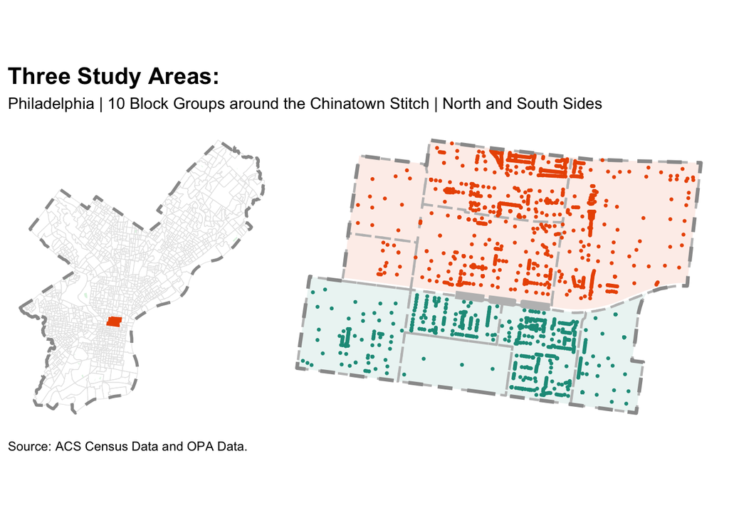

```r
StudyArea_plot1 <- ggplot() +
  geom_sf(data = Philly_blockgroup, fill = "transparent", color = "grey90", linewidth = .2) +
  geom_sf(data = studyarea, fill = "#eb5600", color = "#eb5600") +
  geom_sf(data = hydro, fill = "#DFF3E3", color = "transparent") +
  geom_sf(data = philly_bounds, fill = "transparent", color = "grey60", linewidth = 1, linetype = "dashed") +
  theme_void() +
  labs(title = "Three Study Areas:",
       subtitle = "Philadelphia | 10 Block Groups around the Chinatown Stitch | North and South Sides",
       caption = "Source: ACS Census Data and OPA Data.") +
  theme(plot.title = element_text(size = 16, face = "bold",margin = margin(b = 6)),
        plot.subtitle = element_text(margin = margin(b = 10)),
        plot.caption = element_text(hjust = 0, margin = margin(t = 10)))

StudyArea_plot2 <- ggplot() +
  geom_sf(data = studyarea_north, fill = alpha("#eb5600", .1), color = "transparent") +
  geom_sf(data = studyarea_south, fill = alpha("#1a9988", .1), color = "transparent") +
  # geom_sf(data = discontinuity, fill = "black", color = "transparent") +
  geom_sf(data = Chinatown_Stitch, fill = "grey", color = "transparent", linetype = "dashed", linewidth = 1) +
  geom_sf(data = studyarea_blockgroup, fill = "transparent", color = "grey", linewidth = .8, linetype = "dashed") +
  geom_sf(data = property_north, color = "#eb5600", size = .6) +
  geom_sf(data = property_south, color = "#1a9988", size = .6) +
  geom_sf(data = studyarea, fill = "transparent", color = "grey60", linewidth = 1.2, linetype = "dashed") +
  theme_void()

StudyArea_plot1 | StudyArea_plot2
```

```r
studyarea_4326 <- st_transform(studyarea, crs = 4326)
bbox <- as.list(st_bbox(studyarea_4326))

ChinatownStitch_4326 <- st_read("Dataset/Chinatown_Stitch/Chinatown_Stitch.shp") %>%
  st_transform('EPSG:4326')

I676_4326 <- st_transform(I_676, crs = 4326)

landuse_4326 <- st_read("Dataset/landuse_clip/Land_Use_ClipLayer.shp") %>%
  st_transform('EPSG:4326')

landuse_4326_plot <- landuse_4326 %>%
  filter(C_DIG2DESC != 51 & C_DIG2DESC != 71)

landuse_park_ing <- landuse_4326 %>%
  filter(OBJECTID_1 == 514214)

park_4326 <- st_read("Dataset/ParksModified/Parks_within_1km.shp") %>%
  st_transform('EPSG:4326')

# nhoods_4326 <-
#   st_read("DataWrangling/akidata/philadelphia-neighborhoods.geojson") %>%
#   # st_read("akidata/philadelphia-neighborhoods.geojson") %>%
#   st_transform('EPSG:4326')

Chinatown_Callowhill <- nhoods_4326 %>%
  filter(NAME %in% c("CHINATOWN", "CALLOWHILL"))
```

In the vision of **a city park** in the future, the Chinatown Stitch will bring vitality to local residents and visitors along with other green spaces. Connected with the Stitch, the **Rail Park** in the north (Callowhill neighborhood) is still in construction and will make an impact years later. With a foundation of **cultural and commercial resources**, the southern part (Chinatown neighborhood) will provide services to the surrounding area, including the city center of Philadelphia.

```r
UseCase <- leaflet() %>%
  addProviderTiles(providers$CartoDB.Positron) %>%
  addPolygons(data = studyarea_4326,
              color = "black",       # Black border
              weight = 4,            # Border thickness
              dashArray = "8,12",     # Dashed line pattern (5px on, 5px off)
              fill = FALSE) %>%
    addPolygons(data = landuse_4326_plot,
              color = "grey",
              weight = 0.8,
              fillColor = "#DFF3E3",
              fillOpacity = 0.4) %>%
  addPolygons(data = Chinatown_Callowhill,
              color = "#eb5600",
              weight = 1,
              opacity = 0.5,
              dashArray = "5,5",
              fillColor = "#eb5600",
              fillOpacity = 0.1) %>%
  addPolygons(data = park_4326,
              color = "#1a9988",
              weight = 1,
              fillOpacity = 0.6,
              fillColor = "#1a9988") %>%
  addPolygons(data = landuse_park_ing,
              color = "#1a9988",
              weight = 2,
              opacity = 0.8,
              fill = FALSE) %>%
  addPolylines(data = I676_4326,
               color = "#eb5600",
               opacity = 1,
               weight = 2) %>%
  addPolygons(data = ChinatownStitch_4326,
              color = "#eb5600",
              weight = 2,
              opacity = 1,
              fillColor = "#1a9988",
              fillOpacity = 0.8
              # fill = alpha("#1a9988", 0.5)
              ) %>%
  fitBounds(
    lng1 = bbox$xmin,
    lat1 = bbox$ymin,
    lng2 = bbox$xmax,
    lat2 = bbox$ymax
  )

div(class = "center-leaflet", UseCase)
```

[interactive chart not shown]

| Callowhill | Chinatown |
| --- | --- |

## 1.3 Methodology

To achieve the goal of **a data-rich story map**, the methodology is structured around **a robust model construction process**. By incorporating illustrative data visualizations throughout the data analysis, the story map features engaging maps and compelling narratives.

[figure not shown]

# 2 Data Wrangling

## 2.1 Data Source

[figure not shown]

## Property Data

- [Philadelphia Properties and Assessment History](https://opendataphilly.org/datasets/philadelphia-properties-and-assessment-history/)
- [Land use 2023](https://opendataphilly.org/datasets/land-use/)

```r
# property <- st_read("DataWrangling/akidata/opa_properties_public.geojson") %>%
#   st_transform('EPSG:2272')
#
# property_studyarea <- st_intersection(property, studyarea)
#
# st_write(property_studyarea %>% st_transform('EPSG:3857'), "Dataset/original_property_studyarea.geojson", driver = "GeoJSON")

property_studyarea <- st_read("Dataset/original_property_studyarea.geojson") %>%
  st_transform('EPSG: 2272')

landuse <- st_read("Dataset/landuse_clip/Land_Use_ClipLayer.shp") %>%
  st_transform('EPSG:2272')

landuse_rename <- landuse %>%
  mutate(landuse =
           case_when(
    C_DIG2DESC == 11 ~ "Residential Low",
    C_DIG2DESC == 12 ~ "Residential Medium",
    C_DIG2DESC == 13 ~ "Residential High",
    C_DIG2DESC == 21 ~ "Commercial Consumer",
    C_DIG2DESC == 22 ~ "Commercial Business/Professional",
    C_DIG2DESC == 23 ~ "Commercial Mixed Residential",
    C_DIG2DESC == 31 ~ "Industrial",
    C_DIG2DESC == 41 ~ "Civic/Institution",
    C_DIG2DESC == 51 ~ "Transportation",
    C_DIG2DESC == 61 ~ "Culture/Amusement",
    C_DIG2DESC == 62 ~ "Active Recreation",
    C_DIG2DESC == 71 ~ "Park/Open Space",
    C_DIG2DESC == 72 ~ "Cemetery",
    C_DIG2DESC == 81 ~ "Water",
    C_DIG2DESC == 91 ~ "Vacant",
    C_DIG2DESC == 92 ~ "Other/Unknown"
  ))

# philly properties (from Sijia)
# from the last 5 years, inflation-adjusted prices, total area > 100 sq ft, prices > 30,000, outliers above 5 SD from the mean were removed
# philly_properties <- st_read("akidata/property_philly_250318.geojson")
```

```r
#### clean data for city wise - sale price
colnames(cpi_data) <- c("half1", "half2", "cpi_date")
cpi_long <- cpi_data %>%
  mutate(
    Jan = `half1`, Feb = `half1`, Mar = `half1`, Apr = `half1`, May = `half1`, Jun = `half1`,
    Jul = `half2`, Aug = `half2`, Sep = `half2`, Oct = `half2`, Nov = `half2`, Dec = `half2`
  ) %>%
  select(-half1, -half2) %>%
  pivot_longer(cols = -cpi_date, names_to = "Month", values_to = "CPI") %>%
  mutate(
    Month = match(Month, month.abb),
    date = as.Date(paste(cpi_date, Month, "01", sep = "-"))
  ) %>%
  select(date, CPI)

property_philly <-property%>%
  mutate(sale_date = as.Date(sale_date, format = "%Y-%m-%d")) %>%
  filter(sale_date >= as.Date("2020-01-01") & sale_date <= as.Date("2024-12-31"))%>%
  filter(!is.na(sale_price), !is.na(total_livable_area))%>%
  mutate(
    sale_month = floor_date(sale_date, "month"))%>%
  left_join(cpi_long, by = c("sale_month" = "date"))%>%
  mutate(CPI = as.numeric(CPI))%>%
  mutate(adj_sale_price = sale_price * (340.331/CPI))%>%
  select(-sale_month, -recording_date,  -other_building,
         -assessment_date, -mailing_address_2, mailing_city_state, mailing_care_of)

#mean_price <- mean(property_philly$adj_sale_price, na.rm = TRUE)
#sd_price <- sd(property_philly$adj_sale_price, na.rm = TRUE)
#extreme_outlier <- mean_price + 5 * sd_price
price_filtered_philly <- property_philly %>%
  filter(adj_sale_price >= 100)

q_philly <- quantile(price_filtered_philly$adj_sale_price, probs = c(0.05, 0.95), na.rm = TRUE)

property_philly2 <- property_philly %>%
  filter(adj_sale_price >= q_philly[1], adj_sale_price <= q_philly[2])

#property_philly <- property_philly%>%
#  filter(adj_sale_price > 30000, adj_sale_price < extreme_outlier) %>%
#  filter(total_livable_area >= 100)

property_philly <- st_transform(property_philly2, crs = 2272)

#st_write(property_philly, "property_philly.geojson", driver = "GeoJSON", delete_dsn = TRUE)

#### clean data for study area - sale price
#study area intersection
property_studyarea <- st_intersection(property, studyarea)

#sale price clean up and inflation adjusted
colnames(cpi_data) <- c("half1", "half2", "cpi_date")
cpi_long <- cpi_data %>%
  mutate(
    Jan = `half1`, Feb = `half1`, Mar = `half1`, Apr = `half1`, May = `half1`, Jun = `half1`,
    Jul = `half2`, Aug = `half2`, Sep = `half2`, Oct = `half2`, Nov = `half2`, Dec = `half2`
  ) %>%
  select(-half1, -half2) %>%
  pivot_longer(cols = -cpi_date, names_to = "Month", values_to = "CPI") %>%
  mutate(
    Month = match(Month, month.abb),
    date = as.Date(paste(cpi_date, Month, "01", sep = "-"))
  ) %>%
  select(date, CPI)

property_data <-property_studyarea%>%
  mutate(sale_date = as.Date(sale_date, format = "%Y-%m-%d")) %>%
  filter(!is.na(sale_price))%>%
  filter(sale_date <= as.Date("2024-12-31"))%>%
  mutate(
    sale_date = as.Date(sale_date, format = "%Y-%m-%d"),
    sale_month = floor_date(sale_date, "month"))%>%
  left_join(cpi_long, by = c("sale_month" = "date"))%>%
  mutate(CPI = as.numeric(CPI))%>%
  mutate(adj_sale_price = sale_price * (340.331/CPI)) %>%
  select(-sale_month,-recording_date,  -other_building,
         -assessment_date, -mailing_address_2, mailing_city_state, mailing_care_of, -state_code)%>%
  relocate(adj_sale_price, sale_price, .after = 2)

price_filtered <- property_data %>%
  filter(adj_sale_price >= 100)

q <- quantile(price_filtered$adj_sale_price, probs = c(0.05, 0.95), na.rm = TRUE)

property_data2 <- property_data %>%
  filter(adj_sale_price >= q[1], adj_sale_price <= q[2])

property1 <- st_transform(property_data2, crs = 2272)

#join attributes - I676(NS) - nhood1 (neighborhoods in study area)
property1 <- rbind(
    property1 %>% st_intersection(studyarea_north["geometry"]) %>%
      mutate(I676_NS = "north"),
    property1 %>% st_intersection(studyarea_south["geometry"]) %>%
      mutate(I676_NS = "south")
  )
nhood1 <- st_intersection(nhood, studyarea)

#Features clean up for future FE and modeling
## Zoning
property1 <- property1%>%
  select(1:2, zoning, location, everything())

property1 <- property1 %>%
  mutate(zoning = case_when(
    location == "1310-16 VINE ST" ~ "CMX4",
    location == "252-56 N 13TH ST" ~ "CMX4",
    location == "255-57 N BROAD ST" ~ "CMX4",
    location == "451 N 12TH ST" ~ "CMX3",
    location == "453 N 12TH ST" ~"CMX3",
    location == "447 N 12TH ST" ~ "CMX3",
    location == "1108 BUTTONWOOD ST" ~ "CMX3",
    location == "1104 BUTTONWOOD ST" ~ "CMX3",
    location == "256-60 N MARVINE ST" ~ "CMX4",
    location == "820 VINE ST" ~ "CMX4",
    TRUE ~ zoning
  ))

## central air
target_locations_N <- c(
                      "1232 SUMMER ST",
                      "1030 BRANDYWINE ST",
                      "214 N 12TH ST",
                      "1021 SPRING ST")

property1 <- property1 %>%
  mutate(
    central_air = ifelse(location %in% target_locations_N & central_air == "N", "Y", central_air)
  )
## year built - clean up values of 1 and delete the other rows which are parking plot properties that have no year_built data
valid_locations <- c(
  "305-09 N 12TH ST",
  "1008-16 WOOD ST",
  "1004-06 WOOD ST",
  "211 N CAMAC ST",
  "231-33 N BROAD ST",
  "225-27 N 12TH ST"
)
property1 <- property1 %>%
  filter(location != "711-39 SPRING GARDEN ST") %>%
  mutate(year_built = as.numeric(year_built)) %>%
  mutate(
    year_built = case_when(
      location == "305-09 N 12TH ST" & year_built < 1750 ~ 1950,
      location == "1008-16 WOOD ST" & year_built < 1750 ~ 1978,
      location == "1004-06 WOOD ST" & year_built < 1750 ~ 1920,
      location == "211 N CAMAC ST" & year_built < 1750 ~ 1900,
      location == "231-33 N BROAD ST" & year_built < 1750 ~ 2020,
      location == "225-27 N 12TH ST" & year_built < 1750 ~ 2024,

      !is.na(year_built) & year_built < 1750 &
        !(location %in% c(
          "305-09 N 12TH ST",
          "1008-16 WOOD ST",
          "1004-06 WOOD ST",
          "211 N CAMAC ST",
          "231-33 N BROAD ST",
          "225-27 N 12TH ST"
        )) ~ NA_real_,
      TRUE ~ year_built
    )
  )
#st_write(property_philly, "property_philly.geojson", driver = "GeoJSON", delete_dsn = TRUE)
```

### 2.1.1 Census Data （我的部分）

```r
### The method here for pushing data is diffenrent from the one we usually use cause the there is some issues when downloading the geometry data
# census block group
census_api_key("92998588496b9701036218b765c78d2ffb7aedcd", install = TRUE, overwrite = TRUE)
acs_variable_list.2023 <- load_variables(2023, "acs5", cache = TRUE)

local_shapefile <- "Dataset/census/tl_2023_42_bg"
bg_pa <- st_read(local_shapefile, quiet = TRUE)
bg_philly <- bg_pa %>%
  filter(COUNTYFP == "101") %>%
  st_transform(2272) %>%
  select(GEOID, geometry)

block2023_attr <- get_acs(
  geography = "block group",
  variables = c("B19013_001E", "B25058_001E"),
  year = 2023,
  state = 42,
  county = 101,
  geometry = FALSE
)

block2023_attr <- block2023_attr %>%
  select(GEOID, variable, estimate) %>%
  pivot_wider(names_from = variable, values_from = estimate) %>%
  rename(
    MedHHInc = B19013_001,
    MedRent = B25058_001
  )

block2023 <- left_join(bg_philly, block2023_attr, by = "GEOID")

studyarea_blockgroup_df <- as.data.frame(studyarea_blockgroup) %>% select(-geometry)
block2023_studyarea <- block2023 %>% inner_join(studyarea_blockgroup_df, by = "GEOID")

#census tract
tract_pa <- st_read("Dataset/census/tl_2023_42_tract", quiet = TRUE)

tract_philly <- tract_pa %>%
  filter(COUNTYFP == "101") %>%
  st_transform(2272) %>%
  select(GEOID, geometry)

tract_attr <- get_acs(
  geography = "tract",
  variables = c("B25026_001E", "B15001_050E", "B15001_009E","B06012_002E"),
  year = 2023, state = 42, county = 101, geometry = FALSE
)

tract_attr_wide <- tract_attr %>%
  select(GEOID, variable, estimate) %>%
  pivot_wider(names_from = variable, values_from = estimate) %>%
  rename(
    TotalPop = B25026_001,
    FemaleBachelors = B15001_050,
    MaleBachelors = B15001_009,
    TotalPoverty = B06012_002
  )

tract2023 <- left_join(tract_philly, tract_attr_wide, by = "GEOID")
studyarea_blockgroup_df <- as.data.frame(studyarea_blockgroup) %>% select(-geometry)

tract2023 <- tract2023 %>%
  mutate(GEOID_trimmed = as.numeric(str_sub(GEOID, 7, 9)))

studyarea_blockgroup_df <- studyarea_blockgroup_df %>%
  mutate(GEOID_trimmed = as.numeric(str_sub(TRACT, 2, 4)))

tract2023_studyarea <- tract2023 %>%
  inner_join(studyarea_blockgroup_df, by = "GEOID_trimmed")
tract_studyarea <- st_intersection(studyarea, tract2023_studyarea)

# Property1_property2_census_join
property1 <- property1 %>%
  mutate(census_tract = as.numeric(census_tract))
tract_studyarea_selected <- tract_studyarea %>%
  select(GEOID_trimmed, TotalPoverty, MaleBachelors, FemaleBachelors, TotalPop) %>%
  st_drop_geometry()

property1_blockgroup <- st_join(property1, block2023_studyarea %>% select(GEOID, MedHHInc, MedRent),
                            join = st_intersects)

property1_geometry <- st_geometry(property1)

tract_studyarea_selected <- tract_studyarea_selected %>%
  distinct(GEOID_trimmed, .keep_all = TRUE)
property1 <- property1_blockgroup %>%
  st_drop_geometry() %>%
  left_join(tract_studyarea_selected, by = c("census_tract" = "GEOID_trimmed"))

property1 <- property1 %>%
  mutate(objectid = as.character(objectid))

property2 <- property2 %>%
  mutate(objectid = as.character(objectid))

property_combined <- property1 %>%
  left_join(property2, by = "objectid") %>%
  rename(sale_price = sale_price.y)%>%
  select(-sale_price.x)
```

## 2.2 POI Data

```r
# POI - restaurant-drink-dessert
api_key <- "AIzaSyCa-yuy1Y3n07URlR2HHg6dp_cIEouv9hs"
keywords <- c("restaurant", "dim sum restaurant", "kitchen", "desert","tea", "bubble tea","matcha", "herbal tea")
place_types <- c("restaurant", "cafe", "bakery")

studyarea_proj <- st_transform(block2023_studyarea, 2272)

grid_pts <- st_make_grid(studyarea_proj, cellsize = 2000, what = "centers")
grid_pts <- st_sf(geometry = grid_pts) %>%
  st_filter(st_buffer(studyarea_proj, 1000))

grid_pts_wgs <- st_transform(grid_pts, 4326)
coords <- st_coordinates(grid_pts_wgs)

all_responses <- list()

for (pt_idx in seq_len(nrow(coords))) {
  location <- coords[pt_idx, c(2,1)]  # lat, lng
  cat(" Querying center point", pt_idx, "at", paste(location, collapse = ", "), "\n")

  for (ptype in place_types) {
    for (kw in keywords) {
      Sys.sleep(5)
      cat("🔎", kw, "in", ptype, "\n")

      response <- google_places(
        keyword = kw,
        location = location,
        radius = 2000,
        place_type = ptype,
        key = api_key
      )

      if (is.null(response[["results"]]) || length(response[["results"]]) == 0) {
        cat("No results for:", kw, "in", ptype, "\n")
        next
      }

      page_token <- response$next_page_token
      results_list <- list(response[["results"]])
      i <- 1

      while (!is.null(page_token)) {
        Sys.sleep(10)
        response_next <- google_places(
          keyword = kw,
          location = location,
          radius = 2000,
          place_type = ptype,
          key = api_key,
          page_token = page_token
        )

        if (is.null(response_next[["results"]]) || length(response_next[["results"]]) == 0) break

        results_list[[i + 1]] <- response_next[["results"]]
        page_token <- response_next$next_page_token
        i <- i + 1
      }

      all_responses[[paste(kw, ptype, pt_idx, sep = "_")]] <- bind_rows(results_list) %>%
        filter(!is.na(place_id)) %>%
        distinct(place_id, .keep_all = TRUE)
    }
  }
}

all_responses <- all_responses[lengths(all_responses) > 0]
restaurant_results <- bind_rows(all_responses) %>%
  mutate(lat = geometry$location$lat, lng = geometry$location$lng) %>%
  select(lat, lng, name, place_id, rating) %>%
  distinct(place_id, .keep_all = TRUE)

restaurant_sf <- st_as_sf(restaurant_results, coords = c("lng", "lat"), crs = 4326)
restaurant_proj <- st_transform(restaurant_sf, 2272)

studyarea_buffer <- st_buffer(studyarea_proj, 2000)
res_poi <- st_filter(restaurant_proj, studyarea_buffer)
radius_circles <- st_buffer(st_transform(grid_pts, 2272), dist = 2000)

# POI - grocery
keywords <- c("grocery store", "supermarket", "asian grocery", "chinese supermarket",
              "korean market", "japanese grocery", "international market", "food market")

place_types <- c("supermarket", "grocery_or_supermarket", "convenience_store", "store")

studyarea_proj <- st_transform(block2023_studyarea, 2272)

grid_pts <- st_make_grid(studyarea_proj, cellsize = 2000, what = "centers")
grid_pts <- st_sf(geometry = grid_pts) %>%
  st_filter(st_buffer(studyarea_proj, 1000))

grid_pts_wgs <- st_transform(grid_pts, 4326)
coords <- st_coordinates(grid_pts_wgs)

all_responses <- list()

for (pt_idx in seq_len(nrow(coords))) {
  location <- coords[pt_idx, c(2,1)]  # lat, lng
  cat(" Querying center", pt_idx, "at", paste(location, collapse = ", "), "\n")

  for (ptype in place_types) {
    for (kw in keywords) {
      Sys.sleep(5)
      cat("🔎", kw, "in", ptype, "\n")

      response <- google_places(
        keyword = kw,
        location = location,
        radius = 2000,
        place_type = ptype,
        key = api_key
      )

      if (is.null(response[["results"]]) || length(response[["results"]]) == 0) next

      page_token <- response$next_page_token
      results_list <- list(response[["results"]])
      i <- 1

      while (!is.null(page_token)) {
        Sys.sleep(10)
        response_next <- google_places(
          keyword = kw,
          location = location,
          radius = 2000,
          place_type = ptype,
          key = api_key,
          page_token = page_token
        )
        if (is.null(response_next[["results"]]) || length(response_next[["results"]]) == 0) break

        results_list[[i + 1]] <- response_next[["results"]]
        page_token <- response_next$next_page_token
        i <- i + 1
      }

      all_responses[[paste(kw, ptype, pt_idx, sep = "_")]] <- bind_rows(results_list) %>%
        filter(!is.na(place_id)) %>%
        distinct(place_id, .keep_all = TRUE)
    }
  }
}

all_responses <- all_responses[lengths(all_responses) > 0]

grocery_results <- bind_rows(all_responses) %>%
  mutate(lat = geometry$location$lat,
         lng = geometry$location$lng) %>%
  select(lat, lng, name, place_id, rating) %>%
  distinct(place_id, .keep_all = TRUE)

grocery_sf <- st_as_sf(grocery_results, coords = c("lng", "lat"), crs = 4326)
grocery_proj <- st_transform(grocery_sf, 2272)

studyarea_buffer <- st_buffer(studyarea_proj, 2000)
grocery <- st_filter(grocery_proj, studyarea_buffer)

# property join poi
property_sf <- st_as_sf(property_combined, sf_column_name = "geometry")
property_proj <- st_transform(property_sf, 2272)
grocery_proj <- st_transform(grocery, 2272)
restaurant_proj <- st_transform(res_poi, 2272)

grocery_idx <- st_nearest_feature(property_proj, grocery_proj)

property_proj$nearest_grocery_name <- grocery_proj$name[grocery_idx]
property_proj$nearest_grocery_dist <- st_distance(
  property_proj,
  grocery_proj[grocery_idx, ],
  by_element = TRUE
)
restaurant_idx <- st_nearest_feature(property_proj, restaurant_proj)
property_proj$nearest_restaurant_name <- restaurant_proj$name[restaurant_idx]
property_proj$nearest_restaurant_dist <- st_distance(
  property_proj,
  restaurant_proj[restaurant_idx, ],
  by_element = TRUE
)
property_proj$nearest_grocery_dist_m <- as.numeric(property_proj$nearest_grocery_dist)
property_proj$nearest_restaurant_dist_m <- as.numeric(property_proj$nearest_restaurant_dist)
clean_property_poi_distances <- function(property_sf) {
  property_sf %>%
    mutate(
      nearest_grocery_dist_m = as.numeric(nearest_grocery_dist),
      nearest_restaurant_dist_m = as.numeric(nearest_restaurant_dist)) %>%
    select(
      -nearest_grocery_dist,
      -nearest_restaurant_dist
    )
}
property_final <- clean_property_poi_distances(property_proj)
st_write(property_final, "~/Documents/Upenn/Practicum/2025/Chinatown-Practicum-my/finalresults", driver = "GeoJSON", delete_dsn = TRUE)
```

## 2.3 Neighborhood Context Data

- [PPR Properties](https://opendataphilly.org/datasets/ppr-properties/)
- [Neighborhoods](https://opendataphilly.org/datasets/philadelphia-neighborhoods/)
- [Trolley Stations](https://hub.arcgis.com/datasets/dd2afb618d804100867dfe0669383159_0/explore?location=39.956470%2C-75.160382%2C14.19)
- [Highspeed Stations](https://hub.arcgis.com/datasets/af52d74b872045d0abb4a6bbbb249453_0/explore?location=39.955164%2C-75.153952%2C14.43)
- [Bike Network](https://opendataphilly.org/datasets/bike-network/)
- [311 Requests](https://opendataphilly.org/datasets/311-service-and-information-requests/)

```r
nhoods <-
  st_read("Dataset/DataWrangle/philadelphia-neighborhoods.geojson") %>%
  st_transform('EPSG:2272')

park <- st_read("Dataset/ParksModified/Parks_within_1km.shp") %>%
  st_transform('EPSG:2272')

# philly park data (https://opendataphilly.org/datasets/ppr-properties/)
philly_parks <- st_read("https://opendata.arcgis.com/datasets/d52445160ab14380a673e5849203eb64_0.geojson") %>%
  st_transform(crs = 'EPSG:2272') %>%
  st_intersection(philly_bounds)

metro <-
  st_read("https://opendata.arcgis.com/api/v3/datasets/af52d74b872045d0abb4a6bbbb249453_0/downloads/data?format=geojson&spatialRefId=4326") %>%
  st_transform('EPSG:2272') %>%
  mutate(Type = "metro")

city_hall <- metro[metro$Station == 'City Hall', 6]

trolley <-
    st_read("https://opendata.arcgis.com/api/v3/datasets/dd2afb618d804100867dfe0669383159_0/downloads/data?format=geojson&spatialRefId=4326") %>%
  st_transform('EPSG:2272')

trolley_renamed <- trolley %>%
  rename(Station = StopName,
         Route = LineAbbr,
         Longitude = Lon,
         Latitude = Lat) %>%
  mutate(Type = "trolley")

# Combine both datasets into one
transit <- bind_rows(metro, trolley_renamed)

school <-
  st_read("https://opendata.arcgis.com/datasets/d46a7e59e2c246c891fbee778759717e_0.geojson") %>%
  st_transform('EPSG:2272')

hospital <-
  st_read("Dataset/DataWrangle/DOH_Hospitals202311.geojson") %>%
  st_transform('EPSG:2272') %>%
  st_filter(st_union(Philly_blockgroup))

water <-
  st_read("https://services.arcgis.com/fLeGjb7u4uXqeF9q/arcgis/rest/services/Hydrographic_Features_Poly/FeatureServer/1/query?outFields=*&where=1%3D1&f=geojson") %>%
  st_transform('EPSG:2272')

bike_network <-
  st_read("Dataset/DataWrangle/Bike_Network.geojson") %>%
  st_transform('EPSG:2272')

phillyCrimes <-
  st_read("Dataset/DataWrangle/phillyCrimes.geojson") %>%
  st_transform('EPSG:2272')

# LPSS_PER1000: Number of low-produce supply stores per 1,000 people
# HPSS_PER1000: Number of high-produce supply stores per 1,000 people
retail <-
  st_read("https://opendata.arcgis.com/datasets/53b8a1c653a74c92b2de23a5d7bf04a0_0.geojson") %>%
  st_transform('EPSG:2272')
```

```r
calculate_nearest_distance <- function(set_points, other_layer) {
  nearest_idx <- st_nearest_feature(set_points, other_layer)
  st_distance(set_points, other_layer[nearest_idx, ], by_element = TRUE) %>% as.numeric()
}

Luming_property <- property_studyarea %>%
  dplyr::select(objectid, geometry, sale_price) %>%
  rename(orig_objectid = objectid)

Luming_property <- Luming_property %>%
  mutate(distance_to_city_hall = st_distance(., city_hall) %>% as.numeric()) %>%
  mutate(
    distance_to_nearest_transit = calculate_nearest_distance(geometry, transit),
    distance_to_nearest_hospital = calculate_nearest_distance(geometry, hospital),
    distance_to_nearest_school = calculate_nearest_distance(geometry, school),
    distance_to_nearest_park = calculate_nearest_distance(geometry, park),
    distance_to_nearest_water = calculate_nearest_distance(geometry, water),
    distance_to_nearest_bikelane = calculate_nearest_distance(geometry, bike_network),
    distance_to_I676 = calculate_nearest_distance(geometry, I_676)
  ) %>%
  st_join(nhoods["NAME"], left = TRUE) %>%
  rename(nhoods_name = NAME) %>%
  st_join(landuse_rename["landuse"], left = TRUE) %>%
  st_join(retail[, c("LPSS_PER1000", "HPSS_PER1000")], left = TRUE)

Luming_property <- Luming_property %>%
    mutate(
      crime_nn1 = nn_function(st_coordinates(Luming_property),
                              st_coordinates(phillyCrimes), k = 1),

      crime_nn2 = nn_function(st_coordinates(Luming_property),
                              st_coordinates(phillyCrimes), k = 2),

      crime_nn3 = nn_function(st_coordinates(Luming_property),
                              st_coordinates(phillyCrimes), k = 3),

      crime_nn4 = nn_function(st_coordinates(Luming_property),
                              st_coordinates(phillyCrimes), k = 4),

      crime_nn5 = nn_function(st_coordinates(Luming_property),
                              st_coordinates(phillyCrimes), k = 5))
```

# 3 Highway Effects Analysis

## 3.1 Qualitative Research

```r
# property_EDA <- st_read("Dataset/property_sijia_eda.geojson") %>%
#   st_transform('EPSG:2272')
#
# property_EDA_update <- property_EDA %>%
#   dplyr::select(-sale_price.y) %>%
#   rename(sale_price = sale_price.x) %>%
#   mutate(log_sale_price = ifelse(!is.na(sale_price) & sale_price == 0,
#                                  log(sale_price + 1),
#                                  log(sale_price)))
#
# property_EDA_update <-
#   rbind(
#     property_EDA_update %>% st_intersection(studyarea_north["geometry"]) %>%
#       mutate(I676 = "north"),
#     property_EDA_update %>% st_intersection(studyarea_south["geometry"]) %>%
#       mutate(I676 = "south")
#   )

# making sure philly_properties has the same columns as property_EDA_update
# this dataset will be used for the Study Area Scale analysis (I-676 effects + Discontinuity effects)
# also, only keep properties within the study area
# names_toadd <- names(property_EDA_update)[which(!(names(property_EDA_update) %in% names(philly_properties)))]
#
# properties_i676 <- philly_properties %>%
#   filter(objectid %in% property_studyarea$objectid) %>% # this limits what was formally 2394 properties in the study area, to only 94 properties..... definitely needs to be checked
#   mutate(objectid = as.character(objectid)) %>%
#   left_join(property_EDA_update %>%
#               select(c(names_toadd, objectid)) %>%
#               st_drop_geometry(),
#             by = "objectid")

# checking that this worked
# all(names(property_EDA_update) %in% names(properties_i676)) # TRUE, period!
```

## 3.2 Philadelphia Scale Analysis

Before jumping into modeling, we first explored the relationship between **distance to highway** and **property prices**. We used property data from OPA Philadelphia that was cleaned to include only the data from the last five years (Jan. 1st, 2020 to Dec. 31st, 2024) with prices adjusted for inflation after removing extreme outliers and improbable values (keeping rows with property price within the 5th and 95th percentile), and keeping properties with total area of over 100 square feet (see map below for the properties included in this analysis).

Our **Philadelphia Scale Analysis** looks at properties (of all kinds, not limited to housing properties) within 500 m of Philadelphia’s main highways – I-95 on the East, I-76 on the West, US-1 in the North, and I-676 through the city. We saw the following trends in property prices.

```r
# create 500m buffer around philly highways
buff500 <- 500 * 3.28084
hiway_500buff <- st_union(st_buffer(philly_highways, buff500))

# read in pre-saved file
#prop500 <- st_read("akidata/philly_prop500_dst2hghwy_250421.geojson") %>% # Aki, (download from Box)
#  mutate(closest_highway = factor(closest_highway, levels = c("US-1", "I-76", "I-676", "I-95")))

prop500 <- st_read("~/Documents/Upenn/Practicum/2025/Data/philly_prop500_dst2hghwy_250421.geojson") %>% # sijia, (download from Box)
  mutate(closest_highway = factor(closest_highway, levels = c("US-1", "I-76", "I-676", "I-95")))
```

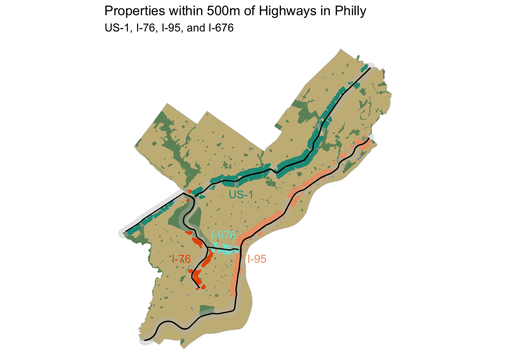

```r
# map of properties within 500m of highway cored by which highway they're closest to
ggplot() +
  geom_sf(data = philly_bounds, fill = "#c9b887", color = "grey") +
  geom_sf(data = hydro, fill = "#7d97c7", color = "transparent") +
  geom_sf(data = philly_parks, fill = "#6b9169", color = "transparent") +
  geom_sf(data = hiway_500buff,
          color = "transparent", fill = "grey", alpha = 0.4) +
  geom_sf(data = prop500,
          aes(color = closest_highway), size = 0.3,
          show.legend = F) +
  geom_sf(data = philly_highways,
          color = "black") +

  # add custom colors
  scale_color_manual(values = c("US-1" = "#1a9988",
                                "I-76" = "#eb5600",
                                "I-95" = "#eba075",
                                "I-676" = "#7fe3d6")) +
  # labels for highway names
  geom_text(aes(label = "US-1",
                x = 2700000,
                y = 256453.2),
            color = "#1a9988") +
  geom_text(aes(label = "I-76",
                x = 2680000,
                y = 235000),
            color = "#eb5600") +
  geom_text(aes(label = "I-95",
                x = 2705200,
                y = 235000),
            color = "#eba075") +
  geom_text(aes(label = "I-676",
                x = 2694000,
                y = 243000),
            color = "#7fe3d6") +

  labs(title = "Properties within 500m of Highways in Philly",
       subtitle = "US-1, I-76, I-95, and I-676",
       color = "Closest Highway") +
  theme_void()
```

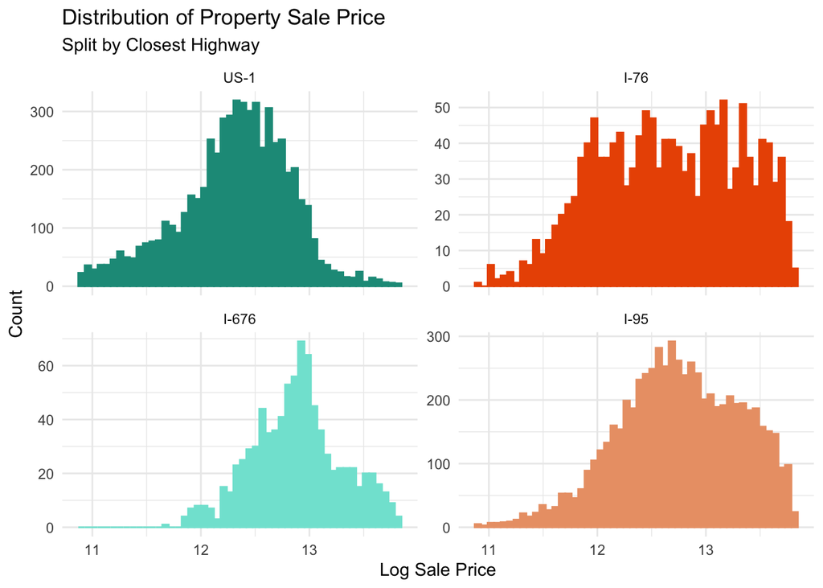

```r
prop500_faceted <-
  ggplot(data = prop500,
         aes(x = log_price, color = closest_highway, fill = closest_highway)) +
  geom_histogram(bins = 50, show.legend = F) +
  facet_wrap(~closest_highway, scales = "free_y") +
  scale_color_manual(values = c("US-1" = "#1a9988",
                                "I-76" = "#eb5600",
                                "I-95" = "#eba075",
                                "I-676" = "#7fe3d6")) +
  scale_fill_manual(values = c("US-1" = "#1a9988",
                               "I-76" = "#eb5600",
                               "I-95" = "#eba075",
                               "I-676" = "#7fe3d6")) +
  labs(title = "Distribution of Property Sale Price",
       subtitle = "Split by Closest Highway",
       x = "Log Sale Price",
       y = "Count") +
  theme_minimal()

prop500_faceted
```

```r
# median sale prices to talk about in the text
med_price_us1 <- round(median(prop500 %>%
                          filter(closest_highway == "US-1") %>%
                          pull(adj_sale_price)))

med_price_i76 <- round(median(prop500 %>%
                          filter(closest_highway == "I-76") %>%
                          pull(adj_sale_price)))

med_price_i95 <- round(median(prop500 %>%
                          filter(closest_highway == "I-95") %>%
                          pull(adj_sale_price)))

med_price_676 <- round(median(prop500 %>%
                          filter(closest_highway == "I-676") %>%
                          pull(adj_sale_price)))

# count of properties included in analysis
prop_count <- prop500 %>%
  st_drop_geometry() %>%
  group_by(closest_highway) %>%
  summarise(count = n())

prop_count_676 <- prop_count %>%
  filter(grepl("676", closest_highway)) %>%
  pull(count)

prop_count_us1 <- prop_count %>%
  filter(grepl("US", closest_highway)) %>%
  pull(count)

prop_count_i76 <- prop_count %>%
  filter(grepl("-76", closest_highway)) %>%
  pull(count)

prop_count_i95 <- prop_count %>%
  filter(grepl("95", closest_highway)) %>%
  pull(count)
```

14,751 total properties were included in this analysis. We see that the distribution of log sale prices of properties within 500m of highways in Philadelphia generally follow a normal distribution.

Though there aren’t as many properties near I-676 (863 properties) as there are near the other highways, they are most expensive group with a median property price of **$397,155**.

Properties near I-95 and I-76 are among a similar range of prices with median property prices being **$345,762** and **$316,000**, respectively, though there are almost five times as many properties near I-95 compared to I-76 (6,547 and 1,410 properties around I-95 and I-76, respectively).

Finally, there are many properties within 500m of US-1 (5,931 properties), but the median property price was lowest compared to other highways at **$234,283**.

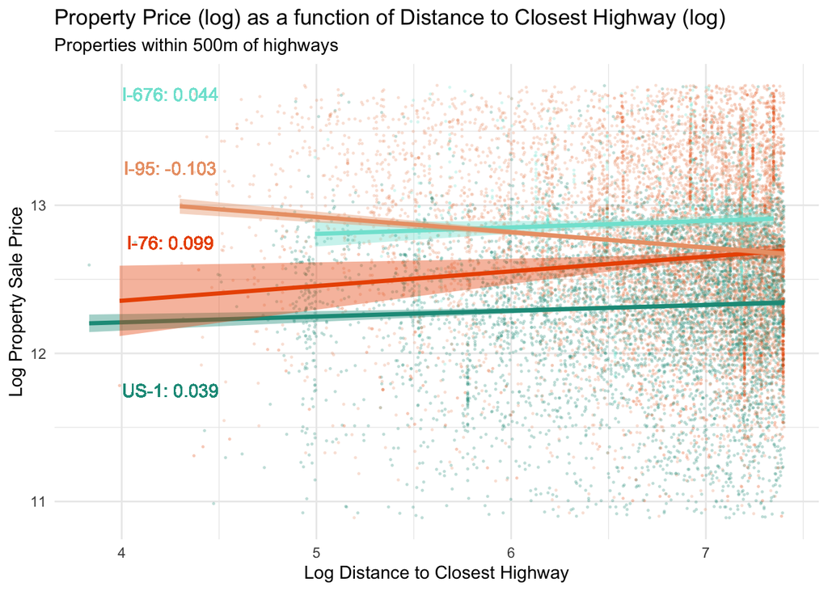

```r
# models + beta coefficients
coef_us1 <- round(
  summary(
    lm(log_price ~ log_dist_to_closest_highway,
       data = prop500 %>%
         filter(grepl("US", closest_highway)))
    )$coefficients[2,1], 3) # *** p < 0.001

coef_i76 <- round(
  summary(
    lm(log_price ~ log_dist_to_closest_highway,
       data = prop500 %>%
         filter(grepl("-76", closest_highway)))
    )$coefficients[2,1], 3) # ** p < 0.05

coef_i95 <- round(
  summary(
    lm(log_price ~ log_dist_to_closest_highway,
       data = prop500 %>%
         filter(grepl("95", closest_highway)))
    )$coefficients[2,1], 3) # *** p < 0.001

coef_i676 <- round(
  summary(
    lm(log_price ~ log_dist_to_closest_highway,
       data = prop500 %>%
         filter(grepl("676", closest_highway)))
    )$coefficients[2,1], 3) # not statistically significant, p = 0.0693

scatter_4highways <-
  ggplot(data = prop500,
       aes(x = log_dist_to_closest_highway, y = log_price,
           color = closest_highway, fill = closest_highway)) +
  geom_point(alpha = .2, size = 0.3, show.legend = F) +
  geom_smooth(method = "lm", size = 1.2, show.legend = F) +
  scale_color_manual(values = c("US-1" = "#1a9988",
                                "I-76" = "#eb5600",
                                "I-95" = "#eba075",
                                "I-676" = "#7fe3d6")) +
  scale_fill_manual(values = c("US-1" = "#1a9988",
                               "I-76" = "#eb5600",
                               "I-95" = "#eba075",
                               "I-676" = "#7fe3d6")) +
  geom_text(aes(label = paste("US-1:", coef_us1),
                x = 4.25,
                y = 11.75),
            color = "#1a9988",
            show.legend = F) +
  geom_text(aes(label = paste("I-76:", coef_i76),
                x = 4.25,
                y = 12.75),
            color = "#eb5600",
            show.legend = F) +
  geom_text(aes(label = paste("I-95:", coef_i95),
                x = 4.25,
                y = 13.25),
            color = "#eba075",
            show.legend = F) +
  geom_text(aes(label = paste("I-676:", coef_i676),
                x = 4.25,
                y = 13.75),
            color = "#7fe3d6",
            show.legend = F) +
  labs(title = "Property Price (log) as a function of Distance to Closest Highway (log)",
       subtitle = "Properties within 500m of highways",
       x = "Log Distance to Closest Highway",
       y = "Log Property Sale Price") +
  theme_minimal()

scatter_4highways
```

The scatter plot above shows the relationship between distance to highway and property price along with the regression coefficients for each highway. We observe that without controlling for anything else, property prices generally increase (albeit by very little) as we move away from a highway which tracks with our literature review of highway effects on property prices.

For every 1% increase in distance from I-676, property price increases by 0.04%. In more understandable terms, this means that if a property that is $100,000 is 50m away from the highway, we can expect a similar property a block further from the highway to be about **$6290 more expensive** (assuming a block is about 200m). For every 1% increase in distance from I-76, property price increases by 0.1%, meaning a property that is $100,000 is 50m away from the highway would be about **$14711 more expensive** if it were a block further from the highway. For every 1% increase in distance from US-1, property price increases by 0.04%, meaning a property that is $100,000 is 50m away from the highway would be about **$5555 more expensive** if it were a block further from the highway.

We now zoom into our **study area** to further understand highway effects in our region of interest.

### 3.2.1 same interpretation but with 100m instead of 200m

For every 1% increase in distance from I-676, property price increases by 0.04%. In more understandable terms, this means that if a property that is $100,000 is 50m away from the highway, we can expect a similar property a block further from the highway to be about **$3097 more expensive** (assuming a block is about 100m). For every 1% increase in distance from I-76, property price increases by 0.1%, meaning a property that is $100,000 is 50m away from the highway would be about **$7103 more expensive** if it were a block further from the highway. For every 1% increase in distance from US-1, property price increases by 0.04%, meaning a property that is $100,000 is 50m away from the highway would be about **$2740 more expensive** if it were a block further from the highway.

The exception here is for properties within 500m of I-95, where the beta coefficient for log distance to highway is -0.103 (p < 0.001). For every 1% increase in distance from I-95, property price decreases by 0.1%. In more understandable terms, this means that if a property that is $100,000 is 50m away from the highway, we can expect a similar property a block further from the highway to be about **$6891 less expensive**.

### 3.2.2 I-95 Exploration

Taking a look at the properties near I-95 to see why we see a different relationship between distance to highway and property price here.

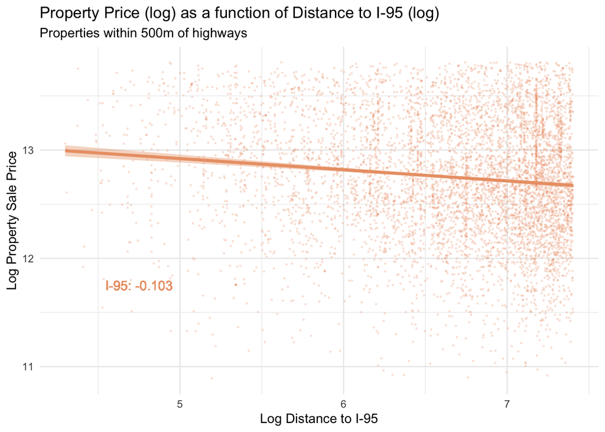

```r
# trying to figure out why we see a negative relationship between distance to highway and property price by I-95
i95_500 <- prop500 %>%
  filter(closest_highway == "I-95") # 6547 total properties

# scatter plot to see relationship
i95_scatter <- ggplot(i95_500,
                      aes(x = log_dist_to_closest_highway, y = log_price)) +
  geom_point(color = "#eba075", alpha = .2, size = 0.3, show.legend = F) +
  geom_smooth(color = "#eba075", fill = "#eba075", method = "lm", size = 1.2, show.legend = F) +
  geom_text(aes(label = paste("I-95:", coef_i95),
                x = 4.75,
                y = 11.75),
            color = "#eba075",
            show.legend = F) +
  labs(title = "Property Price (log) as a function of Distance to I-95 (log)",
       subtitle = "Properties within 500m of highways",
       x = "Log Distance to I-95",
       y = "Log Property Sale Price") +
  theme_minimal()
i95_scatter
```

### 3.2.3 Philly Scale Analysis (Residential Properties only)

Now, we conduct the same analyses to explore the relationship between **distance to highway** and **property prices** for residential properties only (excluding residential garages and vacant lots). We saw the following trends in property prices.

```r
# properties within 500 m of highway that are specifically housing related (excluding residential garages and vacant lands)
prop500_res <- prop500 %>%
  filter(grepl("APARTMENTS|MIXED USE|MULTI FAMILY|SINGLE FAMILY", category_code_description))
# 98.1% of the properties 500 m within highways are residential.
```

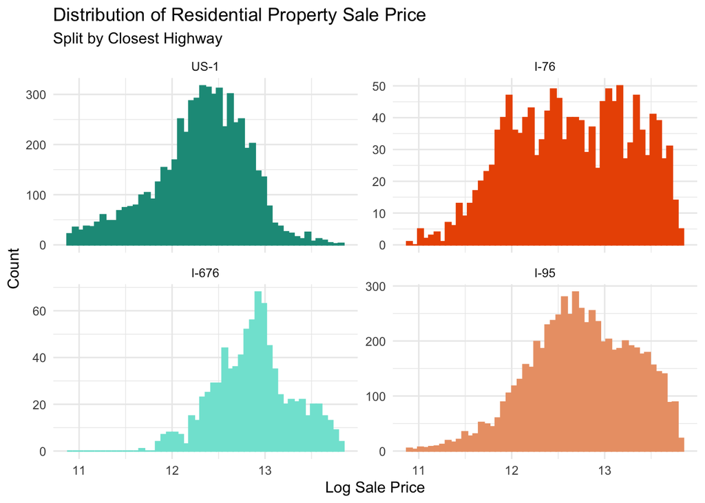

```r
prop500_res_faceted <-
  ggplot(data = prop500_res,
         aes(x = log_price, color = closest_highway, fill = closest_highway)) +
  geom_histogram(bins = 50, show.legend = F) +
  facet_wrap(~closest_highway, scales = "free_y") +
  scale_color_manual(values = c("US-1" = "#1a9988",
                                "I-76" = "#eb5600",
                                "I-95" = "#eba075",
                                "I-676" = "#7fe3d6")) +
  scale_fill_manual(values = c("US-1" = "#1a9988",
                               "I-76" = "#eb5600",
                               "I-95" = "#eba075",
                               "I-676" = "#7fe3d6")) +
  labs(title = "Distribution of Residential Property Sale Price",
       subtitle = "Split by Closest Highway",
       x = "Log Sale Price",
       y = "Count") +
  theme_minimal()

prop500_res_faceted
```

```r
# this one is largely unchanged
```

```r
# median sale prices to talk about in the text
med_res_price_us1 <- round(median(prop500_res %>%
                          filter(closest_highway == "US-1") %>%
                          pull(adj_sale_price)))

med_res_price_i76 <- round(median(prop500_res %>%
                          filter(closest_highway == "I-76") %>%
                          pull(adj_sale_price)))

med_res_price_i95 <- round(median(prop500_res %>%
                          filter(closest_highway == "I-95") %>%
                          pull(adj_sale_price)))

med_res_price_676 <- round(median(prop500_res %>%
                          filter(closest_highway == "I-676") %>%
                          pull(adj_sale_price)))

# count of properties included in analysis
prop_res_count <- prop500_res %>%
  st_drop_geometry() %>%
  group_by(closest_highway) %>%
  summarise(count = n())

prop_res_count_676 <- prop_res_count %>%
  filter(grepl("676", closest_highway)) %>%
  pull(count)

prop_res_count_us1 <- prop_res_count %>%
  filter(grepl("US", closest_highway)) %>%
  pull(count)

prop_res_count_i76 <- prop_res_count %>%
  filter(grepl("-76", closest_highway)) %>%
  pull(count)

prop_res_count_i95 <- prop_res_count %>%
  filter(grepl("95", closest_highway)) %>%
  pull(count)
```

14,475 total properties were included in this analysis. We see that the distribution of log sale prices of properties within 500m of highways in Philadelphia generally follow a normal distribution.

Though there aren’t as many properties near I-676 (852 properties) as there are near the other highways, they are most expensive group with a median property price of **$393,263**.

Properties near I-95 and I-76 are among a similar range of prices with median property prices being **$343,238** and **$310,589**, respectively, though there are almost five times as many properties near I-95 compared to I-76 (6,395 and 1,382 properties around I-95 and I-76, respectively).

Finally, there are many properties within 500m of US-1 (5,846 properties), but the median property price was lowest compared to other highways at **$233,189**.

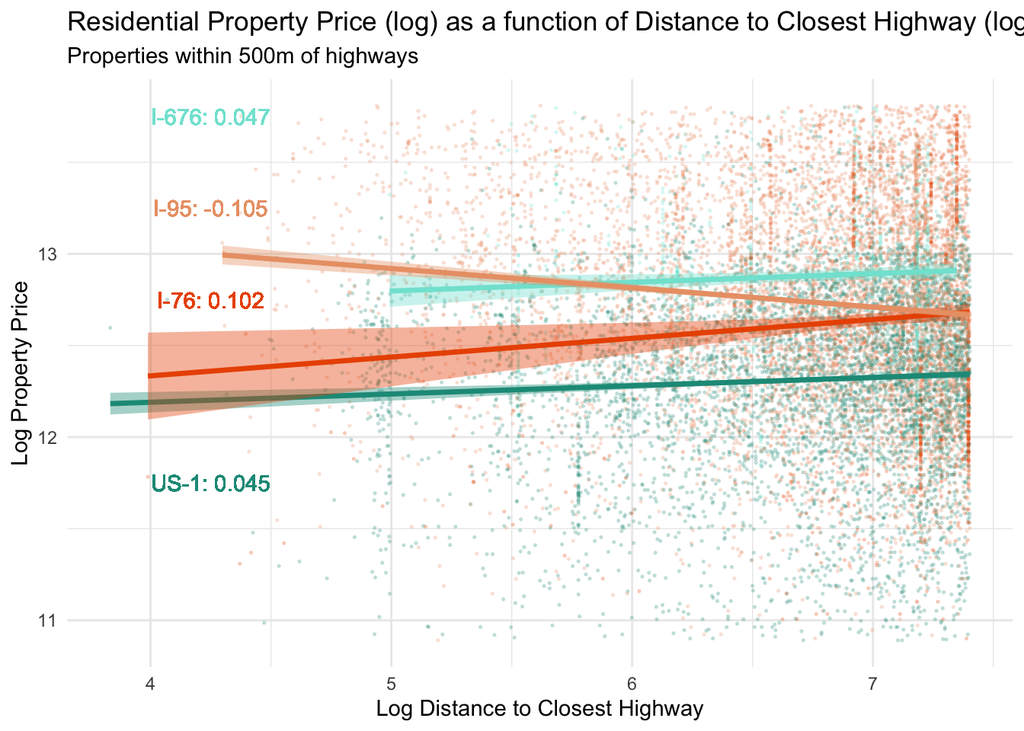

```r
# models + beta coefficients
coef_res_us1 <- round(
  summary(
    lm(log_price ~ log_dist_to_closest_highway,
       data = prop500_res %>%
         filter(grepl("US", closest_highway)))
    )$coefficients[2,1], 3) # *** p < 0.001

coef_res_i76 <- round(
  summary(
    lm(log_price ~ log_dist_to_closest_highway,
       data = prop500_res %>%
         filter(grepl("-76", closest_highway)))
    )$coefficients[2,1], 3) # ** p < 0.05

coef_res_i95 <- round(
  summary(
    lm(log_price ~ log_dist_to_closest_highway,
       data = prop500_res %>%
         filter(grepl("95", closest_highway)))
    )$coefficients[2,1], 3) # *** p < 0.001

coef_res_i676 <- round(
  summary(
    lm(log_price ~ log_dist_to_closest_highway,
       data = prop500_res %>%
         filter(grepl("676", closest_highway)))
    )$coefficients[2,1], 3) # not statistically significant, p = 0.0693

scatter_4highways_res <-
  ggplot(data = prop500_res,
       aes(x = log_dist_to_closest_highway, y = log_price,
           color = closest_highway, fill = closest_highway)) +
  geom_point(alpha = .2, size = 0.3, show.legend = F) +
  geom_smooth(method = "lm", size = 1.2, show.legend = F) +
  scale_color_manual(values = c("US-1" = "#1a9988",
                                "I-76" = "#eb5600",
                                "I-95" = "#eba075",
                                "I-676" = "#7fe3d6")) +
  scale_fill_manual(values = c("US-1" = "#1a9988",
                               "I-76" = "#eb5600",
                               "I-95" = "#eba075",
                               "I-676" = "#7fe3d6")) +
  geom_text(aes(label = paste("US-1:", coef_res_us1),
                x = 4.25,
                y = 11.75),
            color = "#1a9988",
            show.legend = F) +
  geom_text(aes(label = paste("I-76:", coef_res_i76),
                x = 4.25,
                y = 12.75),
            color = "#eb5600",
            show.legend = F) +
  geom_text(aes(label = paste("I-95:", coef_res_i95),
                x = 4.25,
                y = 13.25),
            color = "#eba075",
            show.legend = F) +
  geom_text(aes(label = paste("I-676:", coef_res_i676),
                x = 4.25,
                y = 13.75),
            color = "#7fe3d6",
            show.legend = F) +
  labs(title = "Residential Property Price (log) as a function of Distance to Closest Highway (log)",
       subtitle = "Properties within 500m of highways",
       x = "Log Distance to Closest Highway",
       y = "Log Property Price") +
  theme_minimal()

scatter_4highways_res
```

The scatter plot above shows the relationship between distance to highway and property price along with the regression coefficients for each highway. We observe that without controlling for anything else, property prices generally increase (albeit by very little) as we move away from a highway which tracks with our literature review of highway effects on property prices.

For every 1% increase in distance from I-676, property price increases by 0.05%. In more understandable terms, this means that if a property that is $100,000 is 50m away from the highway, we can expect a similar property a block further from the highway to be about **$6733 more expensive** (assuming a block is about 200m). For every 1% increase in distance from I-76, property price increases by 0.1%, meaning a property that is $100,000 is 50m away from the highway would be about **$15189 more expensive** if it were a block further from the highway. For every 1% increase in distance from US-1, property price increases by 0.04%, meaning a property that is $100,000 is 50m away from the highway would be about **$6437 more expensive** if it were a block further from the highway.

The exception here is for properties within 500m of I-95, where the beta coefficient for log distance to highway is -0.105 (p < 0.001). For every 1% increase in distance from I-95, property price decreases by 0.1%. In more understandable terms, this means that if a property that is $100,000 is 50m away from the highway, we can expect a similar property a block further from the highway to be about **$13546 less expensive**.

We now zoom into our **study area** to further understand highway effects in our region of interest.

## 3.3 Study Region Scale Analysis

### 3.3.1 Basic Geography

```r
park_clipped <- st_intersection(park, studyarea)
park_valid <- st_make_valid(park)
transit_valid <- st_make_valid(transit)
city_hall_valid <- st_make_valid(city_hall)
school_valid <- st_make_valid(school)
water_valid <- st_make_valid(water)
bike_network_valid <- st_make_valid(bike_network)

studyarea_buffer <- st_buffer(studyarea, dist = 1000)

# Clip each dataset to the study area
recreation_clipped <- st_intersection(park, studyarea_buffer)
transit_clipped <- st_intersection(transit_valid, studyarea_buffer)
city_hall_clipped <- st_intersection(city_hall_valid, studyarea_buffer)
school_clipped <- st_intersection(school_valid, studyarea_buffer)
water_clipped <- st_intersection(water_valid, studyarea_buffer)
bike_network_clipped <- st_intersection(bike_network_valid, studyarea_buffer)
landuse_transportation <- landuse_rename[landuse_rename$landuse == "Transportation", ]

# property_vacant <- property_EDA %>%
#   filter(category_code_description %in% c("VACANT LAND","SINGLE FAMILY", "VACANT LAND - NON-RESIDENTIAL")) %>%
#   mutate(category_code_description = case_when(
#     category_code_description == "VACANT LAND - NON-RESIDENTIAL" ~ "VACANT LAND",
#     TRUE ~ category_code_description
#   ))
```

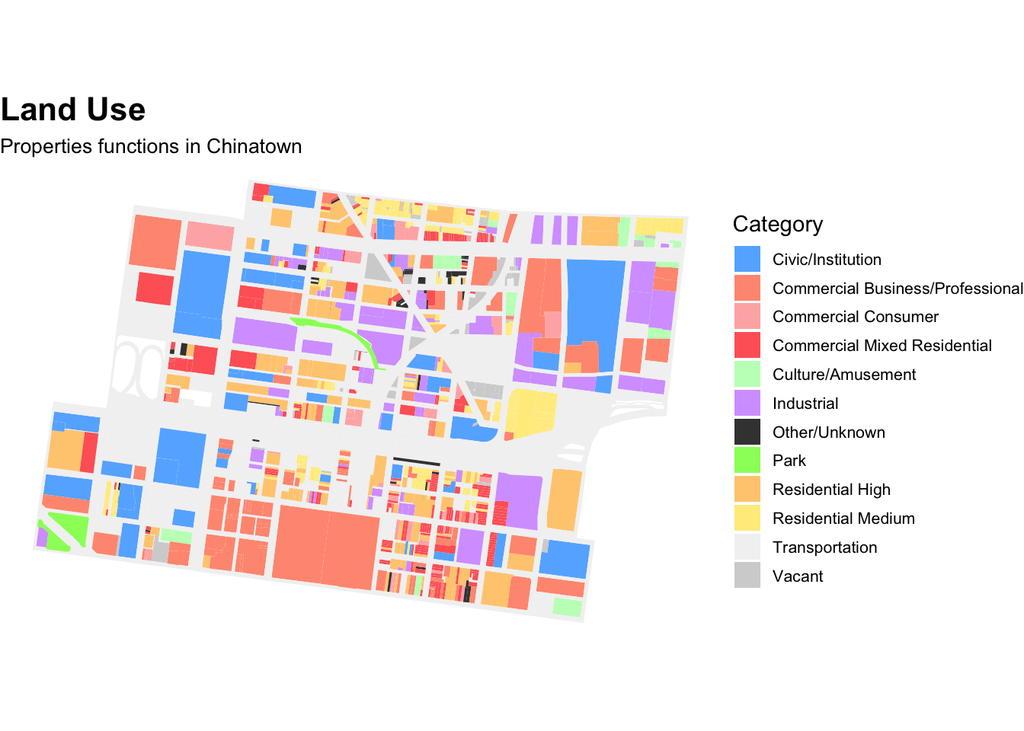

```r
landuse_colors <- c(
  "Residential Low" = "#FFFFB3",
  "Residential Medium" = "#FFEB8B",
  "Residential High" = "#FFCC80",
  "Commercial Consumer" = "#FFB3B3",
  "Commercial Business/Professional" = "#FF9980",
  "Commercial Mixed Residential" = "#FF6666",
  "Industrial" = "#D6A3FF",
  "Civic/Institution" = "#66B3FF",
  "Transportation" = "gray95",
  "Culture/Amusement" = "#C1FFC1",
  "Active Recreation" = "#66FFD9",
  "Park/Open Space" = "#99FF66",
  "Cemetery" = "#FF9999",
  "Water" = "#99CCFF",
  "Vacant" = "#D3D3D3",
  "Other/Unknown" = "gray25"
)

BasicGeo_plot1 <- ggplot(data = landuse_rename %>%
          filter(!is.na(landuse) & landuse != "Park/Open Space")) +
  geom_sf(aes(fill = landuse), color = NA) +
  geom_sf(data = park_clipped, aes(fill = "Park"), color = NA, alpha = 1) +  # Clipped park layer
  scale_fill_manual(values = c(landuse_colors, "Park" = "#99FF66"), na.value = "white") +
  labs(title = "Land Use",
       subtitle = "Properties functions in Chinatown",
       fill = "Category") +
  theme_void() +
  theme(legend.position = "right",
        plot.title = element_text(size = 16, face = "bold"),
        plot.subtitle = element_text(size = 10),
        legend.key.size = unit(0.5, "cm"),
        legend.text = element_text(size = 8))

BasicGeo_plot2 <- ggplot() +
  geom_sf(data = landuse, fill = "white", color = "gray90", size = 0.05) +
  geom_sf(data = recreation_clipped, aes(fill = "Park"), color = NA, alpha = 1) +
  geom_sf(data = landuse_transportation, aes(fill = "Transportation"), color = NA, alpha = 0.5) +
  geom_sf(data = transit_clipped, aes(color = "Transit"), size = 2) +
  geom_sf(data = school_clipped, aes(color = "School"), size = 2) +
  geom_sf(data = bike_network_clipped, aes(color = "Bike Network"), size = 1) +

  scale_color_manual(values = c("Transit" = "blue", "School" = "orange", "Bike Network" = "purple"), name = NULL) +
  scale_fill_manual(values = c("Park" = "green","Transportation" = "gray70"), name = NULL) +

  labs(
    title = "Amenities",
    subtitle = "<span style='color:orange;'>Schools</span>, <span style='color:blue;'>Transit Stations</span>, <span style='color:green;'>Parks</span>, and <span style='color:purple;'>Bike Lanes</span>"
  ) +
  theme_void() +
  theme(
    legend.position = "none",
    plot.title = element_text(size = 16, face = "bold"),
    plot.subtitle = element_markdown(size = 10, hjust = 0),
    legend.key.size = unit(0.5, "cm"),
    legend.text = element_text(size = 8)
  )

BasicGeo_plot3 <- ggplot() +
  geom_sf(data = landuse, fill = "white", color = "gray85", size = 0.05) +
  geom_sf(data = studyarea, fill = "transparent", color = "grey", linetype = "dashed", linewidth = 2) +
  geom_sf(data = discontinuity, fill = "#eb5600", color = "transparent") +
  geom_sf(data = Chinatown_Stitch, fill = "#1a9988", alpha = 0.8) +
  # geom_sf(data = property_vacant, aes(color = category_code_description), size = 1) +
  scale_colour_manual(values = c("black", "#B67352")) +
  labs(title="Potential Lands",
       subtitle = glue("<span style='color:#1a1a1a;'>Single Family & </span><span style='color:#B67352;'>Vacant Land</span>"),
       # caption = "Figure "
       ) +
  theme_void() +
  theme(legend.position = "none",
        plot.title = element_text(size = 16, face = "bold"),
        plot.subtitle = ggtext::element_markdown(size = 10))

BasicGeo_plot1
```

[figure not shown]

```r
BasicGeo_plot2 | BasicGeo_plot3
```

### 3.3.2 Sales Price Change

### 3.3.3 I-676 Effects

One of OTIS’s key interests is the effect of I-676 on property prices nearby. Here, we construct a relatively **simple linear model** with a few key predictors to look at the effect of I-676 on property prices while accounting for some control variables such as the square footage of the property, number of bathrooms, year built, zoning, and zip code among others.

For these analyses, we look at properties **within our study area**.

```r
# working with the newest philly_properties dataset where data was cleaned for our studyarea
property_studyarea_new <- st_read("Dataset/property_CT_FE.geojson") #1528 rows

# add features for simple linear regression
props_i676_tomodel <- property_studyarea_new %>%
  # filter() %>% # there are a couple properties with total area < 100; reduces dataset to 990 properties
  # some feature engineering
  mutate(residential = ifelse(category_code_description %in% c("APARTMENTS  > 4 UNITS",
                                                               "MIXED USE",
                                                               "MULTI FAMILY",
                                                               "SINGLE FAMILY",
                                                               "GARAGE - RESIDENTIAL"),
                              1, 0), # is this property residential? (including mixed)

         building_code_description_new = case_when(
           grepl("FITNESS CENTER|GOV'T MUNICIPAL/STATE/FEDERAL", building_code_description_new) ~ "MostExpensive",
           grepl("LIFE CARE FACILITY-ASSTD LVNG|CORRECTIONAL|MEDICAL OFFICE BLDNG|PARKING GARAGE/DECK|BOARDING/ROOMING HOSUE|MIXED - RES/COMM|SCHOOL|BANK|OFFICE BLDNG - Mid Rise|DET MIXED-COM/RES-BLT AS COM", building_code_description_new) ~ "MoreExpensive",
           grepl("RETAIL - * SINGLE OCCUPANCY|ROW MIXED-COM/RES-BLT AS COM|ROW MODERN|APARTMENTS - LOW RISE|HOTEL - HI RISE|OFFICE BLDNG - Low Rise|FUNERAL HOME|RESTAURANT|DOWNTOWN ROW TYPE-* SNGL OCCP|WAREHOUSE|TWIN CONTEMPORARY|CAR WASH - AUTOMATIC|RETAIL CONDO|MANUFACTURING/PROCESSING|LOFT (INDUSTRIAL)|APARTMENTS - MID RISE|RELIGIOUS", building_code_description_new) ~ "Average",
           .default = "LeastExpensive"
           ),
         building_code_description_new = factor(building_code_description_new),

         # all the other variables have been cleaned and feature engineered
) %>%
  select(   # only keep vars necessary for model
    adj_sale_price,
    log_price, distance_to_I676, log_dist_highway,
    residential,
    year_built, year_built_group,
    central_air, garage_spaces,
    number_of_bathrooms, number_of_bedrooms, total_area,
    exterior_condition, interior_condition, quality_grade,
    building_code_description_new, zoning_group,
    zip_code,
    I676_NS
  )
```

```r
getRMSE <- function(model_results) {
  # residual sum of squares
  rss <- c(crossprod(model_results$residuals))
  # Mean squared error:
  mse <- rss / length(model_results$residuals)
  # Root MSE:
  RMSE <- sqrt(mse)

  return(RMSE)
}
```

#### 3.3.3.1 Model Results

```r
# model with just distance to highway
model_i676 <- lm(log_price ~ log_dist_highway,
                 data = props_i676_tomodel)
# log_dist_highway  0.11110
# Multiple R-squared:  0.01228, Adjusted R-squared:  0.01163

model_i676_summary <- summary(model_i676)
model_i676_RMSE <- getRMSE(model_i676)

# create a clean table to show model results
model_i676_table <- data.frame(model_i676_summary$coefficients) %>%
  rename(p = `Pr...t..`) %>%
  select(Estimate, p) %>%
  mutate(Estimate = round(Estimate, 3),
         p = round(p, 3))
row.names(model_i676_table) <- c("Intercept", "Log Dist. to I-676")

model_i676_table %>%
  kbl(align = c("l", rep("c", 2)),
      caption = "Regression Results: Log Price ~ Log Distance to I-676",
      col.names = c("Estimate", "p value")) %>%
  kable_styling() %>%
  kable_classic(full_width = F, html_font = "Cambria") %>%
  row_spec(2, bold = T, background = "#7fe3d6") %>%
  add_footnote(label = paste0("R-squared: ", round(model_i676_summary$r.squared, 3), ", RMSE: ", round(model_i676_RMSE, 3)),
               notation = "none")
```

Regression Results: Log Price ~ Log Distance to I-676

|  | Estimate | p value |
| --- | --- | --- |
| Intercept | 12.281 | 0 |
| Log Dist. to I-676 | 0.111 | 0 |

R-squared: 0.012, RMSE: 0.694

From an overly simple model, just looking at how logged distance to I-676 predicts logged property price, we see that for properties within 500m of I-676, distance from the highway does not have a large effect on property price. We see that for every 1% increase in distance to the highway, **property price increases by 0.11%**. In more understandable terms, this means that if a property that is $100,000 is 50m away from the highway, we can expect a similar property a block further from the highway to be about **$16635 more expensive** (assuming a block is about 200m). The R-squared value of the model is very low at 0.012 and the RMSE is very high 0.694, meaning the model is terrible.

```r
# simple model but with more predictors
model_i676_more <- lm(log_price ~ log_dist_highway +
                        residential + building_code_description_new + zoning_group + # internal characteristics
                        year_built_group + central_air +
                        number_of_bedrooms + number_of_bathrooms + total_area +
                        quality_grade +
                        factor(zip_code), # neighborhood effects (via zip code for now)
                      data = props_i676_tomodel)

model_i676_more_summary <- summary(model_i676_more)
model_i676_more_RMSE <- getRMSE(model_i676_more)
# log_dist_highway                             0.101134640
# Multiple R-squared:  0.3585,  Adjusted R-squared:  0.3421

# create a clean table to show model results
model_i676_more_table <- data.frame(model_i676_more_summary$coefficients) %>%
  rename(p = `Pr...t..`) %>%
  select(Estimate, p) %>%
  mutate(Estimate = round(Estimate, 3),
         p = round(p, 3))
row.names(model_i676_more_table) <- c("Intercept", "Log Dist. to I-676", "Residential", "Building Code - Least Exp.", "Building Code - More Exp.", "Building Code - Most Exp.", "Zoning - CMX3, 4", "Zoning - CMX5", "Zoning - ICMX", "Zoning - IRMX", "Zoning - Other", "Zoning - RM", "Zoning - RMX3", "Zoning - RSA5", "Year Built - New", "Year Built - Post-War Mid", "Year Built - Pre-War", "Year Built - Unknown", "Central Air - Unknown", "Central Air - Yes", "1 Bedrooms", "2 Bedrooms", "3 Bedrooms", "4 Bedrooms", "5 Bedrooms", "Unknown Num. Bedrooms", "1 Bathrooms", "2 Bathrooms", "3-5 Bathrooms", "6 Bathrooms", "7 Bathrooms", "Unknown Num. Bathrooms", "Total Area", "Quality Grade - Below Average", "Quality Grade - Good", "ZIP code - 19106", "ZIP code - 19107", "ZIP code - 19123", "ZIP code - 19130")

model_i676_more_table %>%
  kbl(align = c("l", rep("c", 2)),
      caption = "Regression Results: Log Price ~ Log Distance to I-676 and Other Predictors",
      col.names = c("Estimate", "p value")) %>%
  kable_styling() %>%
  kable_classic(full_width = F, html_font = "Cambria") %>%
  row_spec(2, bold = T, background = "#7fe3d6") %>%
  add_footnote(label = paste0("Adj. R-squared: ", round(model_i676_more_summary$adj.r.squared, 3), ", RMSE: ", round(model_i676_more_RMSE, 3)),
               notation = "none")
```

Regression Results: Log Price ~ Log Distance to I-676 and Other Predictors

|  | Estimate | p value |
| --- | --- | --- |
| Intercept | 12.558 | 0.000 |
| Log Dist. to I-676 | 0.101 | 0.001 |
| Residential | -0.015 | 0.821 |
| Building Code - Least Exp. | -0.374 | 0.000 |
| Building Code - More Exp. | 0.504 | 0.000 |
| Building Code - Most Exp. | 0.666 | 0.113 |
| Zoning - CMX3, 4 | 0.246 | 0.016 |
| Zoning - CMX5 | 0.429 | 0.051 |
| Zoning - ICMX | 0.837 | 0.000 |
| Zoning - IRMX | 0.274 | 0.042 |
| Zoning - Other | -0.013 | 0.926 |
| Zoning - RM | 0.096 | 0.412 |
| Zoning - RMX3 | 0.139 | 0.217 |
| Zoning - RSA5 | -0.049 | 0.707 |
| Year Built - New | -0.192 | 0.261 |
| Year Built - Post-War Mid | -0.157 | 0.057 |
| Year Built - Pre-War | 0.004 | 0.942 |
| Year Built - Unknown | -0.283 | 0.020 |
| Central Air - Unknown | -0.152 | 0.128 |
| Central Air - Yes | 0.124 | 0.234 |
| 1 Bedrooms | 0.006 | 0.939 |
| 2 Bedrooms | 0.239 | 0.000 |
| 3 Bedrooms | 0.487 | 0.007 |
| 4 Bedrooms | 0.184 | 0.291 |
| 5 Bedrooms | -0.417 | 0.479 |
| Unknown Num. Bedrooms | 0.614 | 0.048 |
| 1 Bathrooms | -0.374 | 0.000 |
| 2 Bathrooms | -0.163 | 0.090 |
| 3-5 Bathrooms | -0.325 | 0.040 |
| 6 Bathrooms | -0.402 | 0.549 |
| 7 Bathrooms | 0.026 | 0.966 |
| Unknown Num. Bathrooms | -0.209 | 0.499 |
| Total Area | 0.000 | 0.000 |
| Quality Grade - Below Average | 0.027 | 0.720 |
| Quality Grade - Good | 0.257 | 0.027 |
| ZIP code - 19106 | 0.272 | 0.117 |
| ZIP code - 19107 | -0.209 | 0.146 |
| ZIP code - 19123 | -0.189 | 0.194 |
| ZIP code - 19130 | -0.436 | 0.168 |

Adj. R-squared: 0.342, RMSE: 0.558

When including these other predictors, the **effect of logged distance to I-676 decreases** but remains statistically significant (beta coefficient of 0.101). This means that for every 1% increase in distance from the highway, property price increases by 0.1%. In more understandable terms, this means that if a property that is $100,000 is 50m away from the highway, we can expect a similar property a block further from the highway to be about **$15029 more expensive**.

### 3.3.4 Discontinuity Effects

To complicate things even more, within our study area, we see that proximity to I-676 has **different effects** on the North (Callowhill) and South (Chinatown) sides.

```r
# with most recently updated data (990 properties)
discontinuity_plot_ungrouped <- props_i676_tomodel %>%
  st_drop_geometry() %>%
  mutate(distance_to_I676m = distance_to_I676 * 0.3048,
         distance_to_highway = case_when(
           I676_NS == "north" ~ distance_to_I676m,
           I676_NS == "south" ~ -distance_to_I676m
           ))

discontinuity_plot <- discontinuity_plot_ungrouped%>%
  group_by(distance_to_highway, I676_NS) %>%
  summarise(mean_log_price = mean(log_price, na.rm = T), .groups = "drop")

# median property prices on each side
med_north <- round(median(discontinuity_plot_ungrouped %>%
                      filter(I676_NS == "north") %>%
                      pull(adj_sale_price)))

med_south <- round(median(discontinuity_plot_ungrouped %>%
                      filter(I676_NS == "south") %>%
                      pull(adj_sale_price)))

# range of property prices on each side
range_north <- round(range(discontinuity_plot_ungrouped %>%
                      filter(I676_NS == "north") %>%
                      pull(adj_sale_price)))

range_south <- round(range(discontinuity_plot_ungrouped %>%
                      filter(I676_NS == "south") %>%
                      pull(adj_sale_price)))
```

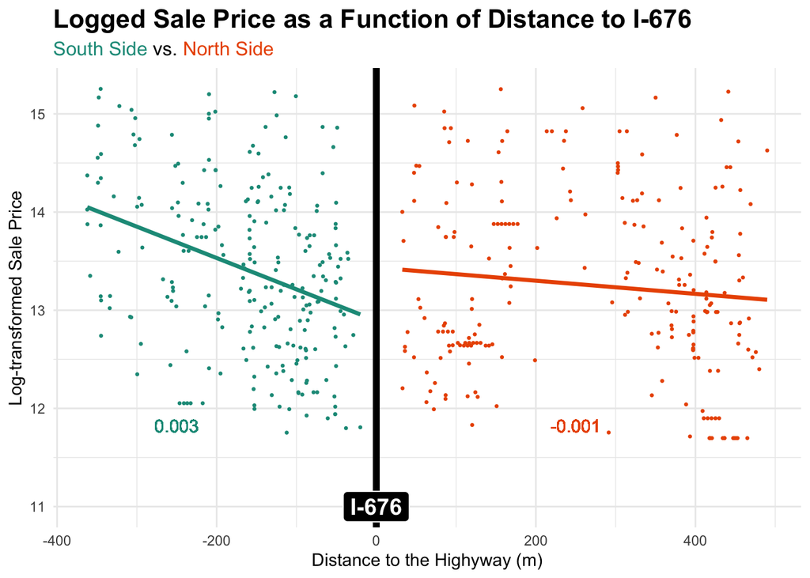

```r
# correlations
# cor_north <- round(cor(discontinuity_plot %>%
#                          filter(
#                            abs(distance_to_highway) <= 500,
#                            I676_NS == "north") %>%
#                          pull(mean_log_price),
#                        discontinuity_plot %>%
#                          filter(
#                            abs(distance_to_highway) <= 500,
#                            I676_NS == "north") %>%
#                          pull(distance_to_highway)), 3)
#
# cor_south <- round(cor(discontinuity_plot %>%
#                          filter(
#                            abs(distance_to_highway) <= 500,
#                            I676_NS == "south") %>%
#                          pull(mean_log_price),
#                        discontinuity_plot %>%
#                          filter(
#                            abs(distance_to_highway) <= 500,
#                            I676_NS == "south") %>%
#                          pull(distance_to_highway)), 3)

# use model coefficients instead of correlations
coef_north_g <- round(
  summary(
    lm(mean_log_price ~ distance_to_highway,
       data = discontinuity_plot %>%
         filter(abs(distance_to_highway) <= 500,
                I676_NS == "north")) # 229 properties
    )$coefficients[2,1], 3) # p = 0.105

coef_south_g <- round(
  summary(
    lm(mean_log_price ~ abs(distance_to_highway), # need to use absolute value cause distance values are negative
       data = discontinuity_plot %>%
         filter(abs(distance_to_highway) <= 500,
                I676_NS == "south")) # 237 properties
    )$coefficients[2,1], 3) # *** p < 0.001

discont_plot <- discontinuity_plot %>%
  filter(abs(distance_to_highway) <= 500) %>% # limiting it to the properties within 500m
  ggplot(aes(x = distance_to_highway, y = mean_log_price, color = I676_NS)) +
  geom_point(size = 0.5) +
  geom_smooth(method = "lm", se = FALSE, size = 1.2) +
  geom_vline(xintercept = 0, color = "black", size = 2) +

  # custom colors
  scale_colour_manual(values = c("#eb5600", "#1a9988")) +

  theme_minimal() +
  theme(legend.position = "None",
        plot.title = element_text(size = 16, face = "bold"),
        plot.subtitle = ggtext::element_markdown(size = 12),
        plot.caption = element_text(hjust = 0)) +
  labs(title = 'Logged Sale Price as a Function of Distance to I-676',
       subtitle = glue("<span style='color:#1a9988;'>South Side</span> vs. <span style='color:#eb5600;'>North Side</span>"),
       x = "Distance to the Highyway (m)",
       y = "Log-transformed Sale Price") +

  # add annotations
  geom_label(aes(x = 0, y = 11, label = "I-676"),
             fill = "black", color = "white", fontface = "bold", size = 5) +
  geom_text(aes(label = coef_north_g,
                x = 250,
                y = 11.825),
            color = "#eb5600",
            show.legend = F) +
  geom_text(aes(label = coef_south_g,
                x = -250,
                y = 11.825),
            color = "#1a9988",
            show.legend = F)

# ungrouped
coef_north <- round(
  summary(
    lm(log_price ~ distance_to_highway,
       data = discontinuity_plot_ungrouped %>%
         filter(abs(distance_to_highway) <= 500,
                I676_NS == "north")) # 609 properties
    )$coefficients[2,1], 3) # p = 0.636

coef_south <- round(
  summary(
    lm(log_price ~ abs(distance_to_highway), # need to use absolute value cause distance values are negative
       data = discontinuity_plot_ungrouped %>%
         filter(abs(distance_to_highway) <= 500,
                I676_NS == "south")) # 811 properties
    )$coefficients[2,1], 3) # *** p < 0.001

discont_plot_ungrouped <- discontinuity_plot_ungrouped %>%
  filter(abs(distance_to_highway) <= 500) %>% # limiting it to the properties within 500m
  ggplot(aes(x = distance_to_highway, y = log_price, color = I676_NS)) +
  geom_point(size = 0.5) +
  geom_smooth(method = "lm", se = FALSE, size = 1.2) +
  geom_vline(xintercept = 0, color = "black", size = 2) +

  # custom colors
  scale_colour_manual(values = c("#eb5600", "#1a9988")) +

  theme_minimal() +
  theme(legend.position = "None",
        plot.title = element_text(size = 16, face = "bold"),
        plot.subtitle = ggtext::element_markdown(size = 12),
        plot.caption = element_text(hjust = 0)) +
  labs(title = 'Logged Sale Price as a Function of Distance to I-676',
       subtitle = glue("<span style='color:#1a9988;'>South Side</span> vs. <span style='color:#eb5600;'>North Side</span>"),
       x = "Distance to the Highyway (m)",
       y = "Log-transformed Sale Price") +

  # add annotations
  geom_label(aes(x = 0, y = 11, label = "I-676"),
             fill = "black", color = "white", fontface = "bold", size = 5) +
  geom_text(aes(label = coef_north,
                x = 250,
                y = 11.825),
            color = "#eb5600",
            show.legend = F) +
  geom_text(aes(label = coef_south,
                x = -250,
                y = 11.825),
            color = "#1a9988",
            show.legend = F)

discont_plot
```

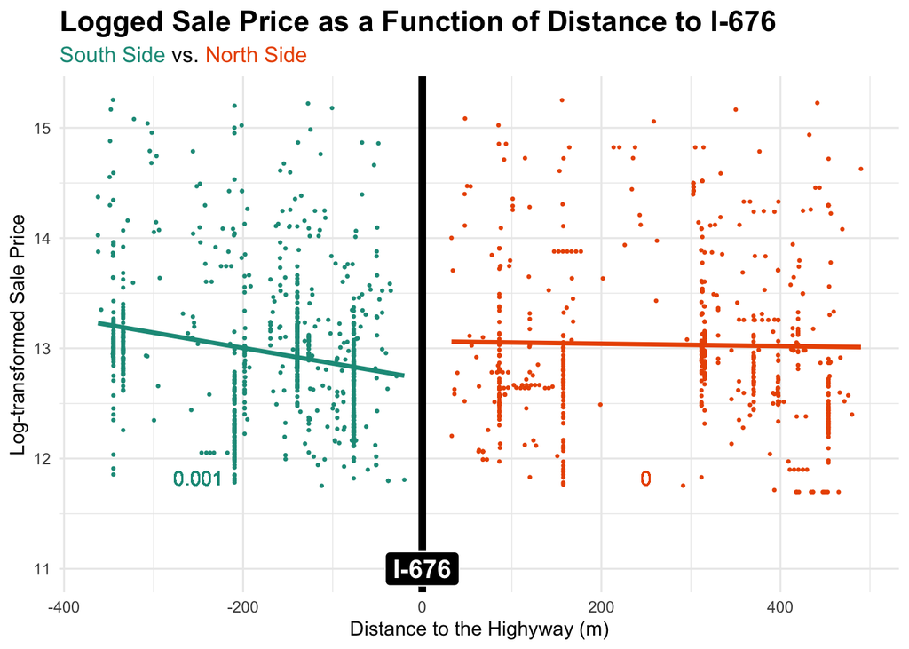

```r
discont_plot_ungrouped
```

```r
# save image for powerpoint
# ggsave("PPT/Images/p2_discontinuity_within_500m.png",
#        height = 7, width = 10, units = "in")
```

In the plot above, we see that on the North side of I-676, property prices remain relatively stable and unaffected by distance to the highway. The median property price in the North is $398,478. When predicting logged property price, the beta coefficient for distance to highway is 0, meaning the **highway has no effect on the price**.

On the other hand, in the South side of I-676, property prices are within the same range of prices as in the North side, but the median property price is slightly higher at $407,069. When predicting logged property price to the South of the highway, the beta coefficient for distance to highway is 0.001, meaning **distance to highway has a very small, positive effect on the price**. For every 1m increase in distance from I-676, property price increases by 0.1%. In more understandable terms, a property that is $100,000 and 50m South of I-676 would be about **$16183 more expensive** a block further from the highway.

This demonstrates that in our study area, the **highway has a very small influence on property price** that is only really seen on the South side of I-676.

### 3.3.5 Zoning-Based Price Effects

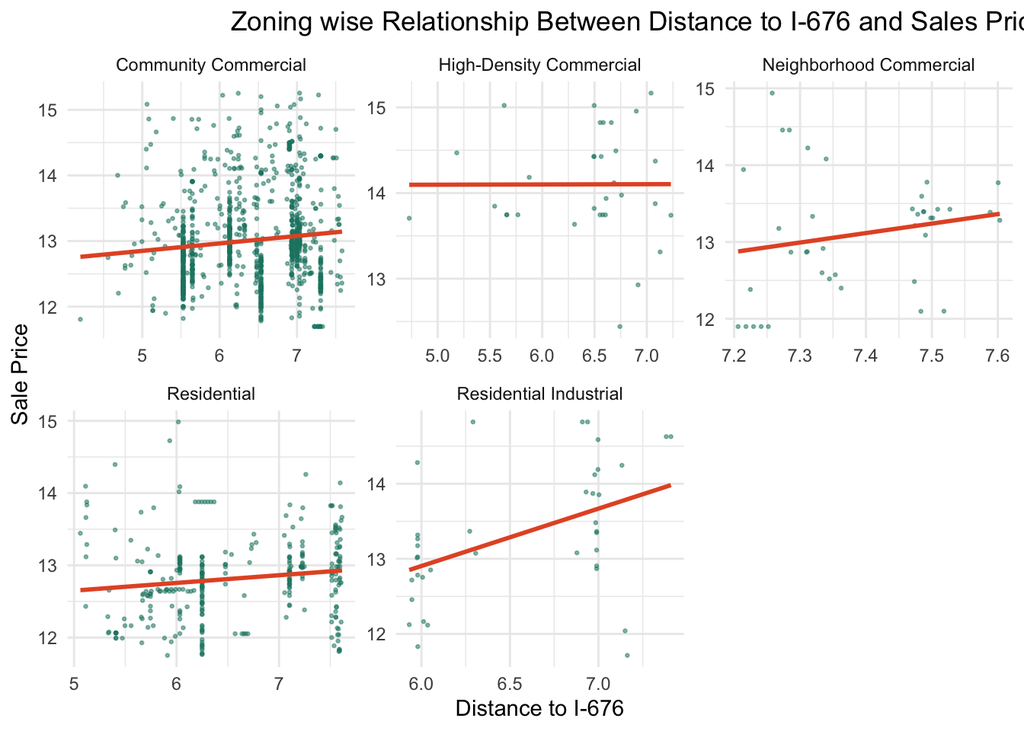

```r
property_filtered <- property_final
property_filtered <- st_as_sf(property_filtered, sf_column_name = "geometry")

avg_price_zoning <- property_filtered %>%
  st_drop_geometry() %>%
  group_by(zoning) %>%
  summarise(avg_price_zoning = mean(adj_sale_price, na.rm = TRUE)) %>%
  ungroup()

property_filtered <- property_filtered %>%
  left_join(avg_price_zoning, by = "zoning")%>%
  filter(location != "711-39 SPRING GARDEN ST")

property_filtered <- property_filtered %>%
  mutate(zoning_group = case_when(
    zoning %in% c("CMX5", "ICMX") ~ "High-Density Commercial",
    zoning %in% c("IRMX") ~ "Residential Industrial",
    zoning %in% c("RM1", "RM4", "RMX3", "RSA5") ~ "Residential",
    zoning %in% c("CMX2.5", "CMX2", "CMX1") ~ "Neighborhood Commercial",
    zoning %in% c("CMX3", "CMX4") ~ "Community Commercial",
    TRUE ~ "Other"
  ))

avg_price_group <- property_filtered %>%
  st_drop_geometry() %>%
  group_by(zoning_group) %>%
  summarise(avg_adj_sale_price = mean(adj_sale_price, na.rm = TRUE)) %>%
  ungroup()

property_filtered <- property_filtered %>%
  left_join(avg_price_group, by = "zoning_group")


ggplot(property_filtered %>% filter(!is.na(zoning_group) & zoning_group != "Other"),
       aes(x = log1p(distance_to_I676), y = log1p(adj_sale_price))) +
  geom_point(alpha = 0.5, size = 0.5, color = "#1B8370") +
  geom_smooth(method = "lm", se = FALSE, color = "#E4572E") +
  facet_wrap(~ zoning_group, scales = "free") +
  theme_minimal() +
  labs(title = "                      Zoning wise Relationship Between Distance to I-676 and Sales Price",
       x = "Distance to I-676",
       y = "Sale Price")
```

### 3.3.6 Neighborhood-Based Price Effects

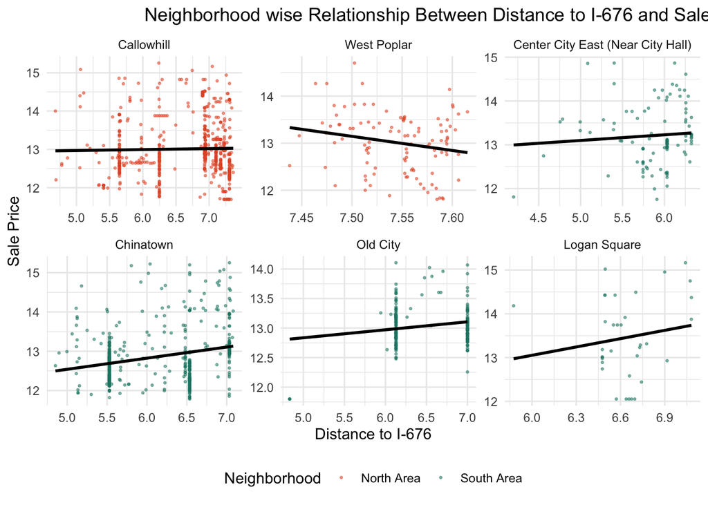

```r
property_with_nhood <- st_join(property_filtered, nhood1, join = st_intersects)

nhood_summary <- property_with_nhood %>%
  group_by(NAME) %>%
  summarise(
    avg_sale_price = mean(adj_sale_price, na.rm = TRUE),
    avg_distance = mean(distance_to_I676, na.rm = TRUE)
  ) %>%
  ungroup()
nhood_map <- st_join(nhood1, nhood_summary, by = "NAME")

property_logansquare_split <- property_filtered %>%
  mutate(
    nhoods_name = case_when(
      GEOID %in% c("421010003003") ~ "Logan Square",
      GEOID %in% c("421010125013", "421010125014") ~ NA_character_,
      str_to_title(str_replace_all(nhoods_name, "_", " ")) == "Center City" ~ "Center City East (Near City Hall)",
      TRUE ~ str_to_title(str_replace_all(nhoods_name, "_", " "))
    )
  ) %>%
  filter(!is.na(nhoods_name))

avg_price_nhoods <- property_logansquare_split %>%
  st_drop_geometry() %>%
  group_by(nhoods_name) %>%
  summarise(avg_sale_price = mean(adj_sale_price, na.rm = TRUE)) %>%
  ungroup()

highlight_nhoods <- c( "Callowhill", "West Poplar")
green_nhoods <- c("Center City East (Near City Hall)", "Chinatown", "Old City", "Logan Square")

property_logansquare_split$nhoods_name <- factor(
  property_logansquare_split$nhoods_name,
  levels = c(highlight_nhoods, green_nhoods)
)
ggplot(property_logansquare_split %>% filter(!is.na(nhoods_name)),
       aes(x = log1p(distance_to_I676), y = log1p(adj_sale_price),
           color = ifelse(nhoods_name %in% highlight_nhoods, "North Area", "South Area"))) +
  geom_point(alpha = 0.5, size = 0.5) +
  geom_smooth(method = "lm", se = FALSE, color = "black") +
  facet_wrap(~ nhoods_name, scales = "free", nrow = 2) +
  scale_color_manual(values = c("North Area" = "#E4572E", "South Area" = "#1B8370")) +
  theme_minimal() +
  theme(
    legend.position = "bottom",
    legend.justification = c(0.5, -0.2)
  ) +
  labs(
        title = "                   Neighborhood wise Relationship Between Distance to I-676 and Sales Price",
       x = "Distance to I-676",
       y = "Sale Price",
    color = "Neighborhood"
  )
```

### 3.3.7 Engineered Features

```r
median_bedroom <- median(as.numeric(as.character(property_final$number_of_bedrooms)), na.rm = TRUE)
median_bathroom <- median(as.numeric(as.character(property_final$number_of_bathrooms)), na.rm = TRUE)

property_CT <- property_final %>%
  filter(!zoning %in% c("I2", "SPPOA"))%>%
  mutate(
        # Neighborhood Name
#    nhoods_name = case_when(
#      nhoods_name %in% c("CENTER_CITY", "LOGAN_SQUARE") ~ "WEST_PART",
#      TRUE ~ nhoods_name
#    ),

    # Land Use
    landuse = case_when(
      landuse %in% c("Park/Open Space", "Other/Unknown", "Commercial Business/Professional") ~ "Open Space/Business",
      landuse %in% c("Commercial Consumer", "Commercial Mixed Residential",
                     "Industrial", "Transportation", "Culture/Amusement") ~ "Commercial",
      landuse %in% c("Civic/Institution", "Residential High") ~ "Residential High/Civic",
      TRUE ~ landuse
    ),

    # LPSS Category
#    LPSS_PER1000 = case_when(
#      LPSS_PER1000 < 45 ~ "low",
#      LPSS_PER1000 >= 45 & LPSS_PER1000 <= 60.70941337 ~ "mid",
#      LPSS_PER1000 %in% c(60.70941337, 131.86813187) ~ "high",
#      TRUE ~ "Unknown"
#    ),
#    LPSS_PER1000 = factor(LPSS_PER1000, levels = c("low", "mid", "Unknown")),

    # HPSS Category
#    HPSS_PER1000 = case_when(
#      HPSS_PER1000 < 5.6 ~ "low",
#     HPSS_PER1000 >= 5.6 & HPSS_PER1000 <= 7.3 ~ "mid",
#      HPSS_PER1000 >= 7.3 ~ "high",
#      TRUE ~ "Unknown"
#    ),
#    HPSS_PER1000 = factor(HPSS_PER1000, levels = c("low", "mid", "Unknown")),

    # Year Built
    year_built = as.numeric(year_built),
    year_built_missing = ifelse(is.na(year_built), 1, 0),
#    year_built = case_when(
#      is.na(year_built) ~ "Unknown",
#      TRUE ~ as.character(year_built)
#    ),
#    year_built = factor(year_built),

    year_built_group = case_when(
      is.na(year_built) ~ "Unknown",
      year_built < 1940 ~ "Pre-War",
      year_built < 2000 ~ "Post-War Mid",
      year_built < 2020 ~ "Modern",
      year_built >= 2020 ~ "New"
    ),
    year_built_group = factor(year_built_group, levels = c("Pre-War", "Post-War Mid", "Modern", "New", "Unknown")),
#     year_built < 1900 ~ "1900 Before",
#     year_built >= 1900 & year_built < 1930 ~ "1900- 1930",
#     year_built >= 1930 & year_built < 1970 ~ "1930 - 1970",
#     year_built >= 1970 & year_built < 2010 ~ "1970 - 2010",
#     year_built >= 2010 ~ "2010+",
#      TRUE ~ "Unknown"
#    ),
#    year_built_group = factor(year_built_group, levels = c("1900 Before","1900- 1930","1930 - #1970","1970 - 2010","2010+","Unknown")),

    # Log Transforms
    log_price = log(adj_sale_price),
    log_dist_highway = log(distance_to_I676 + 1),

    # Central Air
    central_air = case_when(
      central_air %in% c("Y", "1")  ~ "Y",
      central_air %in% c("N", "0") ~ "N",
      TRUE ~ "Unknown"
    ),
    central_air = factor(central_air),
    central_air_missing = ifelse(central_air == "Unknown", 1, 0),

    # Garage Spaces
    garage_spaces_missing = ifelse(is.na(garage_spaces), 1, 0),
    garage_spaces = case_when(
#      is.na(garage_spaces) ~ "Unknown",
      garage_spaces == 0 | garage_spaces == 1 ~ "less than 2",
      TRUE ~ "2 or more"
    ),
    garage_spaces = factor(garage_spaces),

    # Bedrooms
    number_of_bedrooms = as.numeric(as.character(number_of_bedrooms)),
    number_of_bedrooms_missing = ifelse(is.na(number_of_bedrooms), 1, 0),
    number_of_bedrooms_filled = ifelse(is.na(number_of_bedrooms), median_bedroom, number_of_bedrooms),
    number_of_bedrooms = case_when(
      is.na(number_of_bedrooms) ~ "Unknown",
      number_of_bedrooms == 0 ~ "0",
      number_of_bedrooms == 1 ~ "1",
      number_of_bedrooms %in% c(2, 3) ~ "2",
      number_of_bedrooms %in% c(5, 6) ~ "3",
      number_of_bedrooms == 4 ~"4",
      number_of_bedrooms %in% c(7, 9, 12) ~ "5"
    ),
    number_of_bedrooms = factor(number_of_bedrooms),

    # Bathrooms
    number_of_bathrooms = as.numeric(as.character(number_of_bathrooms)),
    number_of_bathrooms_missing = ifelse(is.na(number_of_bathrooms), 1, 0),
    number_of_bathrooms_filled = ifelse(is.na(number_of_bathrooms), median_bathroom, number_of_bathrooms),
    number_of_bathrooms = case_when(
      number_of_bathrooms == 0 ~ "0",
      number_of_bathrooms == 1 ~ "1",
      number_of_bathrooms == 2 ~ "2",
      number_of_bathrooms %in% c(3, 4, 5) ~ "3-5",
      number_of_bathrooms == 6 ~ "6",
      number_of_bathrooms == 7 ~ "7",
      TRUE ~ "Unknown"
    ),
    number_of_bathrooms = factor(number_of_bathrooms),

    # Total Livable Area
    total_livable_area = ifelse(is.na(total_livable_area) | total_livable_area == 1, 0, total_livable_area),

    # Quality Grade
    quality_grade = case_when(
      quality_grade %in% c("A ", "A-") | is.na(quality_grade) ~ "Good",
      quality_grade %in% c("3 ", "C+", "C")  ~ "Average",
      TRUE ~ "Below Average"
    ),
    quality_grade = factor(quality_grade, levels = c("Good", "Average", "Below Average")),
    quality_grade_missing = ifelse(is.na(quality_grade), 1, 0),

    # Construction
    general_construction = as.character(general_construction),
    general_construction = case_when(
      is.na(general_construction) ~ "Unknown",
      TRUE ~ general_construction
    ),
    general_construction = factor(general_construction),
    general_construction_missing = ifelse(general_construction == "Unknown", 1, 0),

    # Separate Utilities
    separate_utilities = case_when(
      is.na(separate_utilities) ~ "Unknown",
      TRUE ~ separate_utilities
    ),
    separate_utilities = factor(separate_utilities, levels = c("A", "B", "C", "Unknown")),
    separate_utilities_missing = ifelse(separate_utilities == "Unknown", 1, 0),

    # Exterior Condition
    exterior_condition = case_when(
      exterior_condition == 2 ~ "Good",
      exterior_condition %in% c(1, 6, 7) | is.na(exterior_condition) ~ "Average",
      exterior_condition %in% c(3, 4, 5) ~ "Below Average"
 #     TRUE ~ "Unknown"
    ),
    exterior_condition = factor(exterior_condition),

    # Interior Condition
    interior_condition = case_when(
      interior_condition %in% c(2) ~ "Good",
      is.na(interior_condition) | interior_condition %in% c(1, 7) ~ "Average",
      interior_condition %in% c(3, 4, 5, 6) ~ "Below Average",
      TRUE ~ "Unknown"
    ),
    interior_condition = factor(interior_condition),

    # Category Code
    category_code_original = as.character(category_code),
    category_code_group = case_when(
      category_code == "12" ~ "6 ",
      category_code == "14" ~ "2 ",
      category_code == "10" ~ "4 ",
      category_code == "15" ~ "5 ",
      category_code == "16" ~ "4 ",
      category_code == "7 "  ~ "4 ",
      category_code == "8 "  ~ "6 ",
      category_code == "9 "  ~ "3 ",
      category_code %in% c("1 ", "2 ", "3 ", "4 ", "5 ", "6 ") ~ category_code,
      TRUE ~ "Other"
    ),
    category_code = factor(category_code_group),

    # Zoning
    zoning_group = case_when(
      zoning %in% c("CMX5") ~ "CMX5",
      zoning %in% c("IRMX") ~ "IRMX",
      zoning %in% c("RM1", "RM2", "RM4") ~ "RM",
      zoning %in% c("RMX3") ~ "RMX3",
      zoning %in% c("RSA5") ~ "RSA5",
      zoning %in% c("ICMX") ~ "ICMX",
      zoning %in% c("SPPOA") ~ "SPPOA",
      zoning %in% c("I2") ~ "I2",
      zoning %in% c("CMX2.5", "CMX2", "CMX1") ~ "CMX(1,2,2.5)",
      zoning %in% c("CMX3", "CMX4") ~ "CMX(3,4)",
      TRUE ~ "Other"
    ),
    zoning_group = factor(zoning_group),

    zoning = case_when(
      is.na(zoning) ~ "Unknown",
      TRUE ~ zoning
    ),
    zoning = factor(zoning),
    zip_code = factor(zip_code)
  )

mean_depth <- mean(property_CT$depth, na.rm = TRUE)
property_CT$depth[is.na(property_CT$depth)] <- mean_depth

st_write(property_CT, "property_CT_FE.geojson", driver = "GeoJSON", delete_dsn = TRUE)
```

```
## Deleting source `property_CT_FE.geojson' using driver `GeoJSON'
## Writing layer `property_CT_FE' to data source
##   `property_CT_FE.geojson' using driver `GeoJSON'
## Writing 1528 features with 121 fields and geometry type Point.
```

#### 3.3.7.1 Continuous Features

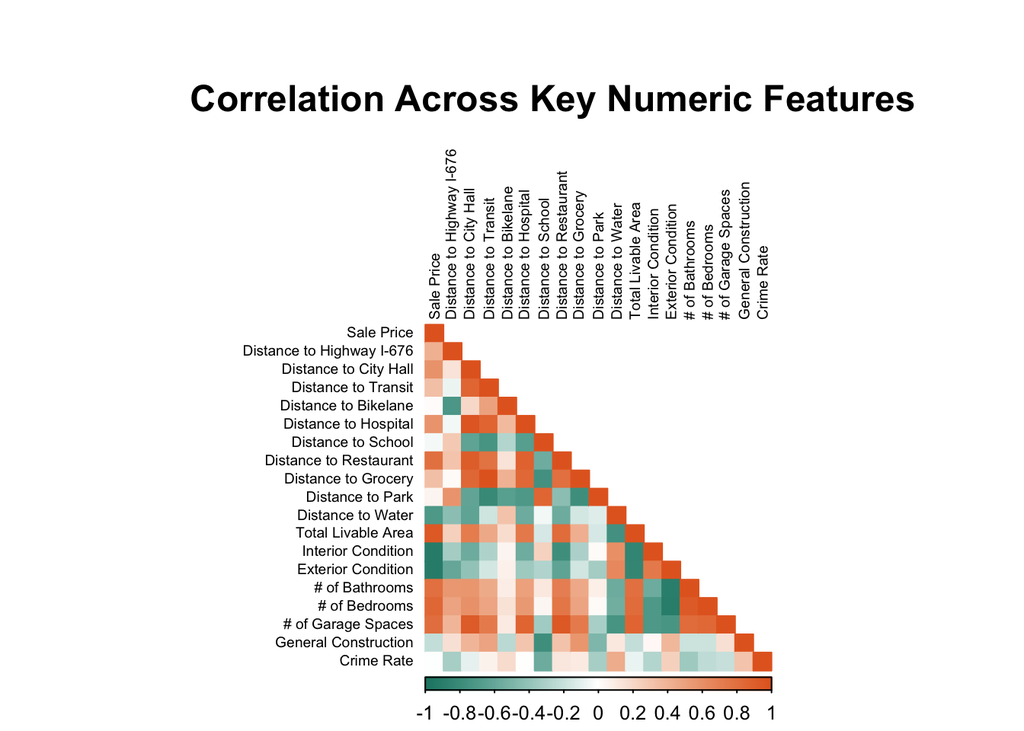

```r
lm1_property <- property_final %>%
  st_drop_geometry() %>%
  select(
    adj_sale_price,
    distance_to_I676,
    distance_to_city_hall,
    distance_to_nearest_transit,
    distance_to_nearest_bikelane,
    distance_to_nearest_hospital,
    distance_to_nearest_school,
    nearest_restaurant_dist_m,
    nearest_grocery_dist_m,
    distance_to_nearest_park,
    distance_to_nearest_water,
    total_livable_area,
    interior_condition,
    exterior_condition,
    number_of_bathrooms,
    number_of_bedrooms,
    garage_spaces,
    general_construction,
    crime_nn5
  ) %>%
  mutate(across(everything(), as.numeric)) %>%
  na.omit()

cor_matrix <- cor(lm1_property, use = "complete.obs")

var_labels <- c(
  "adj_sale_price" = "Sale Price",
  "distance_to_I676" = "Distance to Highway I-676",
  "distance_to_city_hall" = "Distance to City Hall",
  "distance_to_nearest_transit" = "Distance to Transit",
  "distance_to_nearest_bikelane" = "Distance to Bikelane",
  "distance_to_nearest_school" = "Distance to School",
  "nearest_restaurant_dist_m" = "Distance to Restaurant",
  "nearest_grocery_dist_m" = "Distance to Grocery",
  "distance_to_nearest_hospital" = "Distance to Hospital",
  "distance_to_nearest_park" = "Distance to Park",
  "distance_to_nearest_water" = "Distance to Water",
  "total_livable_area" = "Total Livable Area",
  "interior_condition" = "Interior Condition",
  "exterior_condition" = "Exterior Condition",
  "number_of_bathrooms" = "# of Bathrooms",
  "number_of_bedrooms" = "# of Bedrooms",
  "garage_spaces" = "# of Garage Spaces",
  "crime_nn5" = "Crime Rate",
  "general_construction" = "General Construction"
)

colnames(cor_matrix) <- var_labels[colnames(cor_matrix)]
rownames(cor_matrix) <- var_labels[rownames(cor_matrix)]

corrplot(
  cor_matrix,
  method = "color",
  col = colorRampPalette(c("#1B8370", "white", "#E46726"))(200),
  type = "lower",
  tl.pos = "lt",
  tl.col = "black",
  tl.cex = 0.6,
  mar = c(0, 0, 5, 0)
)

title(
  main = "Correlation Across Key Numeric Features",
  cex.main = 1.5,
  font.main = 2,
  line = 0.3,
  adj = 0.6
)
```

#### 3.3.7.2 Log Transformation

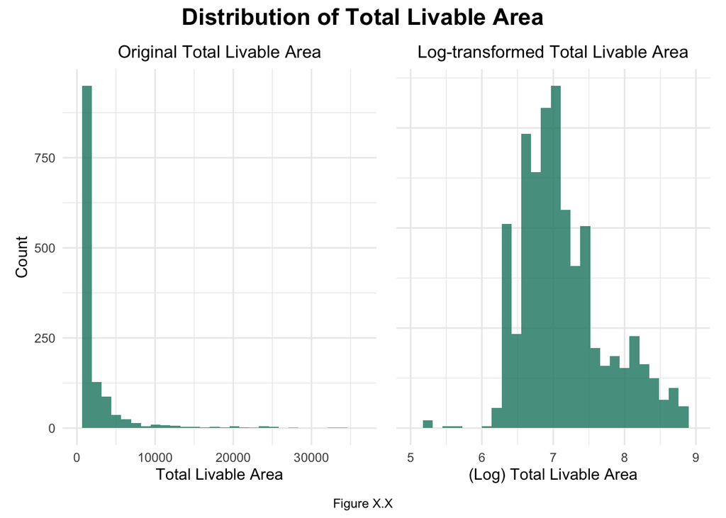

```r
plot_df <- property_final %>%
  mutate(
    total_livable_area_log = log1p(total_livable_area)
  )

plot1 <- ggplot(plot_df, aes(x = total_livable_area)) +
  geom_histogram(bins = 30, fill = "#1B8370", alpha = 0.8) +
  labs(title = "Original Total Livable Area",
        x = "Total Livable Area",
        y = "Count") +
  xlim(0, quantile(plot_df$total_livable_area, 0.99, na.rm = TRUE)) +
  theme_minimal() +
  theme(
    plot.title = element_text(size = 12, hjust = 0.5)
  )

plot2 <- ggplot(plot_df, aes(x = total_livable_area_log)) +
  geom_histogram(bins = 30, fill = "#1B8370", alpha = 0.8) +
  labs(title = "Log-transformed Total Livable Area",
        x = "(Log) Total Livable Area",
        y = "Count")  +
  xlim(5, 9) +
  theme_minimal() +
  theme(
    plot.title = element_text(size = 12, hjust = 0.5),
    axis.title.y = element_blank(),
    axis.text.y = element_blank(),
    axis.ticks.y = element_blank()
  )
combined_plot <- plot1 + plot2 +
  plot_layout(widths = c(1, 1)) +
  plot_annotation(
    title = "Distribution of Total Livable Area",
    caption = "Figure X.X",
    theme = theme(
      plot.title = element_text(size = 16,face = "bold", hjust = 0.5),
      plot.caption = element_text(hjust = 0.5)
    )
  )
combined_plot
```

#### 3.3.7.3 Reclassification

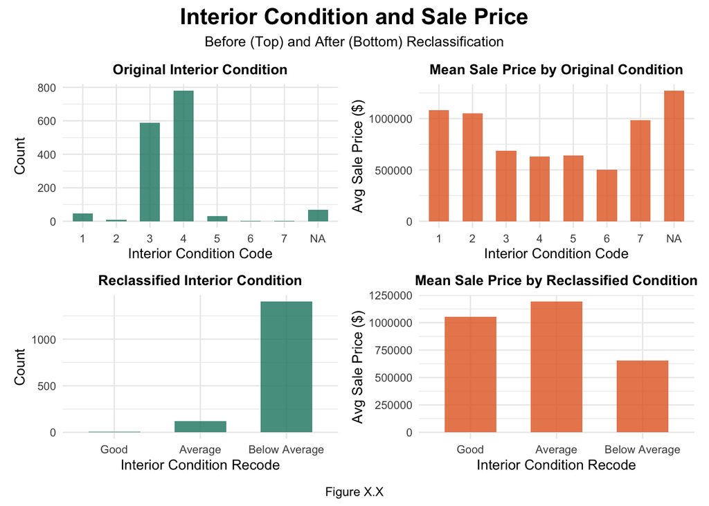

```r
lm1_property <- property_final %>%
  mutate(
    interior_condition_recode = case_when(
      interior_condition %in% c(2) ~ "Good",
      is.na(interior_condition) | interior_condition %in% c(1, 7) ~ "Average",
      interior_condition %in% c(3, 4, 5, 6) ~ "Below Average",
      TRUE ~ "Unknown"
    ),
    interior_condition_recode = factor(interior_condition_recode, levels = c("Good", "Average", "Below Average", "Unknown"))
  )
plot1 <- ggplot(lm1_property, aes(x = factor(interior_condition))) +
  geom_bar(fill = "#1B8370", alpha = 0.8, width = 0.6) +
  ggtitle("Original Interior Condition") +
  labs(x = "Interior Condition Code", y = "Count") +
  theme_minimal(base_size = 10) +
  theme(plot.title = element_text(size = 10, face = "bold", hjust = 0.5))

plot2 <- lm1_property %>%
  group_by(interior_condition) %>%
  summarise(mean_log_price = mean(market_value, na.rm = TRUE)) %>%
  ggplot(aes(x = factor(interior_condition), y = mean_log_price)) +
  geom_col(fill = "#E46726", alpha = 0.8, width = 0.6) +
  ggtitle("Mean Sale Price by Original Condition") +
  labs(x = "Interior Condition Code", y = "Avg Sale Price ($)") +
  theme_minimal(base_size = 10) +
  theme(plot.title = element_text(size = 10, face = "bold", hjust = 0.5))

plot3 <- ggplot(lm1_property, aes(x = interior_condition_recode)) +
  geom_bar(fill = "#1B8370", alpha = 0.8, width = 0.6) +
  ggtitle("Reclassified Interior Condition") +
  labs(x = "Interior Condition Recode", y = "Count") +
  theme_minimal(base_size = 10) +
  theme(plot.title = element_text(size = 10, face = "bold", hjust = 0.5))

plot4 <- lm1_property %>%
  group_by(interior_condition_recode) %>%
  summarise(mean_log_price = mean(market_value, na.rm = TRUE)) %>%
  ggplot(aes(x = interior_condition_recode, y = mean_log_price)) +
  geom_col(fill = "#E46726", alpha = 0.8, width = 0.6) +
  ggtitle("Mean Sale Price by Reclassified Condition") +
  labs(x = "Interior Condition Recode", y = "Avg Sale Price ($)") +
  theme_minimal(base_size = 10) +
  theme(plot.title = element_text(size = 10, face = "bold", hjust = 0.5))

# Combine with patchwork + large centered title
combined_plot <- (plot1 + plot2 + plot_layout(tag_level = "new")) /
                 (plot3 + plot4 + plot_layout(tag_level = "new")) +
  plot_annotation(
    title = "Interior Condition and Sale Price",
    subtitle = "Before (Top) and After (Bottom) Reclassification",
    caption = "Figure X.X",
    theme = theme(
      plot.title = element_text(size = 16, face = "bold", hjust = 0.5),
      plot.subtitle = element_text(size = 10, hjust = 0.5),
      plot.caption = element_text(hjust = 0.5),
      plot.title.position = "plot"
    )
  )
combined_plot
```

#### 3.3.7.4 Comparing north and south - Continuous Variables

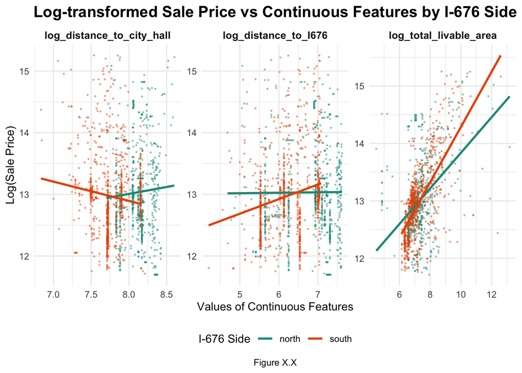

```r
property_fe <- property_CT %>%
  st_drop_geometry() %>%
  mutate(
    log_sale_price = log1p(adj_sale_price),
    log_distance_to_I676 = log1p(distance_to_I676),
    log_distance_to_city_hall = log1p(distance_to_city_hall),
    log_total_livable_area = log1p(total_livable_area),
    I676_NS = as.character(I676_NS)
  )

property_fe_selected <- property_fe %>%
  select(
    I676_NS,
    log_sale_price,
    log_distance_to_I676,
    log_distance_to_city_hall,
    log_total_livable_area
  ) %>%
  drop_na()

correlation_long <- property_fe_selected %>%
  pivot_longer(-c(log_sale_price, I676_NS), names_to = "Variable", values_to = "Value") %>%
  mutate(
    use_in_plot = case_when(
      Variable == "log_total_area" & Value <= log1p(10) ~ FALSE,
      Variable == "log_total_livable_area" & Value <= log1p(10) ~ FALSE,
      TRUE ~ TRUE
    )
  )

cor_selected <- correlation_long %>%
  filter(use_in_plot) %>%
  group_by(Variable, I676_NS) %>%
  summarise(r = cor(Value, log_sale_price, use = "complete.obs"), .groups = "drop") %>%
  mutate(
    x_pos = -Inf,
    y_pos = ifelse(I676_NS == "north", Inf, -Inf),
    vjust_pos = ifelse(I676_NS == "north", 1.1, -1.1)
  )

ggplot(correlation_long %>% filter(use_in_plot),
       aes(x = Value, y = log_sale_price)) +
  geom_point(aes(color = I676_NS), alpha = 0.4, size = 0.3) +
  geom_smooth(aes(color = I676_NS), method = "lm", se = FALSE, linewidth = 1) +
  facet_wrap(~ Variable, scales = "free", ncol = 3) +
  scale_color_manual(values = c("north" = "#1a9988", "south" = "#eb5600")) +
  labs(
    title = "Log-transformed Sale Price vs Continuous Features by I-676 Side",
    caption = "Figure X.X",
    x = "Values of Continuous Features",
    y = "Log(Sale Price)",
    color = "I-676 Side"
  ) +
  theme_minimal() +
  theme(
    plot.title = element_text(size = 15, face = "bold",hjust = 0.5),
    strip.text = element_text(size = 10, face = "bold"),
    plot.caption = element_text(hjust = 0.5),
    legend.position = "bottom"
  )
```

#### 3.3.7.5 Comparing north and south - Categorical Variables

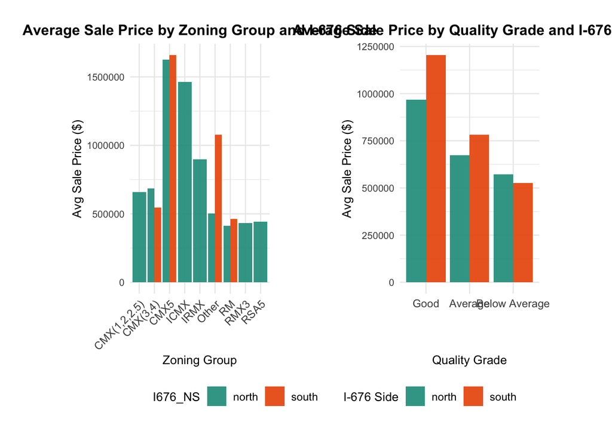

```r
# Prepare aggregated data by zoning group and I676 side
zoning_bar_data <- property_CT %>%
  st_drop_geometry() %>%
  filter(!is.na(zoning_group), !is.na(adj_sale_price), !is.na(I676_NS)) %>%
  group_by(zoning_group, I676_NS) %>%
  summarise(mean_sale_price = mean(adj_sale_price, na.rm = TRUE), .groups = "drop")

# Prepare aggregated data by quality grade and I676 side
quality_bar_data <- property_CT %>%
  st_drop_geometry() %>%
  filter(!is.na(quality_grade), !is.na(adj_sale_price), !is.na(I676_NS)) %>%
  group_by(quality_grade, I676_NS) %>%
  summarise(mean_sale_price = mean(adj_sale_price, na.rm = TRUE), .groups = "drop")
base_font_size <- 10

plot_zoning <- ggplot(zoning_bar_data, aes(x = zoning_group, y = mean_sale_price, fill = I676_NS)) +
  geom_col(position = "dodge", alpha = 0.9) +
  scale_fill_manual(values = c("north" = "#1a9988", "south" = "#eb5600")) +
  labs(
    title = "Average Sale Price by Zoning Group and I-676 Side",
    x = "Zoning Group", y = "Avg Sale Price ($)"
  ) +
  theme_minimal(base_size = base_font_size) +
  theme(
    plot.title = element_text(face = "bold", size = base_font_size + 2, hjust = 0.5),
    axis.text.x = element_text(angle = 45, hjust = 1, size = base_font_size - 1),
    legend.position = "none"
  )

plot_quality <- ggplot(quality_bar_data, aes(x = factor(quality_grade), y = mean_sale_price, fill = I676_NS)) +
  geom_col(position = "dodge", alpha = 0.9) +
  scale_fill_manual(values = c("north" = "#1a9988", "south" = "#eb5600")) +
  labs(
    title = "Average Sale Price by Quality Grade and I-676 Side",
    x = "Quality Grade", y = "Avg Sale Price ($)",
    fill = "I-676 Side"
  ) +
  theme_minimal(base_size = base_font_size) +
  theme(
    plot.title = element_text(face = "bold", size = base_font_size + 2, hjust = 0.5),
    axis.text.x = element_text(size = base_font_size - 1)
  )

final_plot <- plot_zoning + plot_quality +
  plot_layout(ncol = 2, widths = c(1, 1), guides = "collect") &
  theme(
    legend.position = "bottom",
    legend.title = element_text(size = base_font_size),
    legend.text = element_text(size = base_font_size - 1),
    plot.margin = margin(10, 30, 10, 30)
  )

final_plot
```

#### 3.3.7.6 Summary of Features

# 4 Predictive Modeling

## 4.1 Results

# 5 Scenario Planning

## 5.1 Scenario 0

```r
#property_S0 <- st_read("Storymap_dataset/property_S0.geojson")
#property_S0 <- property_CT%>%st_transform('EPSG:2272')
```

### 5.1.2 Scenario 0 discontinuity plot

```r
#property_S0 <- st_transform(property_S0, 2272)
property_S1_4326 <- st_read("Storymap_dataset/property_S1_4326.geojson")
```

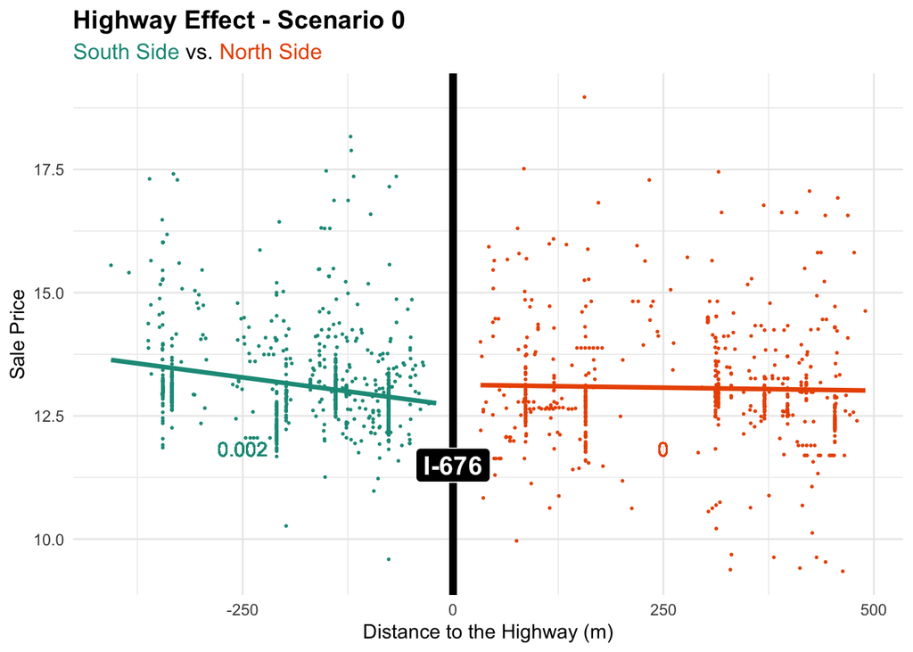

```r
property_S0 <- st_transform(property_S1_4326, 2272)   # yes use property_S1_4326 and the field we use here is adj_sale_price

discontinuity_S0 <- property_S0 %>%
  filter(adj_sale_price > 100)
discontinuity_S0 <- rbind(
  discontinuity_S0 %>% st_intersection(studyarea_north["geometry"]) %>%
    mutate(I676_NS = "north"),
  discontinuity_S0 %>% st_intersection(studyarea_south["geometry"]) %>%
    mutate(I676_NS = "south")
)

discontinuity_S0 <- discontinuity_S0 %>%
  st_drop_geometry() %>%
  mutate(
    distance_to_I676m = distance_to_I676 * 0.3048,
    distance_to_highway = case_when(
      I676_NS == "north" ~ distance_to_I676m,
      I676_NS == "south" ~ -distance_to_I676m
    )
  )

discontinuity_S0 <- discontinuity_S0 %>%
  filter(abs(distance_to_highway) <= 500)

coef_north_S0 <- round(
  summary(
    lm(log(adj_sale_price+1) ~ distance_to_highway,
       data = discontinuity_S0,
       subset = I676_NS == "north"))$coefficients[2,1], 3)

coef_south_S0 <- round(
  summary(
    lm(log(adj_sale_price+1) ~ abs(distance_to_highway),
       data = discontinuity_S0,
       subset = I676_NS == "south"))$coefficients[2,1], 3)
discontinuity_plot_S0 <- ggplot(data = discontinuity_S0) +
  geom_point(aes(x = distance_to_highway, y = log(adj_sale_price+1), color = I676_NS), size = 0.3) +
  geom_smooth(aes(x = distance_to_highway, y = log(adj_sale_price+1), color = I676_NS),
              method = "lm", se = FALSE, linewidth = 1.2) +
  geom_vline(xintercept = 0, color = "black", linewidth = 2) +
  scale_colour_manual(values = c("north" = "#eb5600", "south" = "#1a9988")) +
  theme_minimal() +
  theme(
    legend.position = "None",
    plot.title = element_text(size = 14, face = "bold"),
    plot.subtitle = ggtext::element_markdown(size = 12),
    plot.caption = element_text(hjust = 0)
  ) +
  labs(
    title = 'Highway Effect - Scenario 0',
    subtitle = glue("<span style='color:#1a9988;'>South Side</span> vs. <span style='color:#eb5600;'>North Side</span>"),
    x = "Distance to the Highway (m)",
    y = "Sale Price"
  ) +
  geom_label(aes(x = 0, y = 11.5, label = "I-676"),
             fill = "black", color = "white", fontface = "bold", size = 5) +
  geom_text(aes(label = coef_north_S0,
                x = 250,
                y = 11.825),
            color = "#eb5600",
            show.legend = F) +
  geom_text(aes(label = coef_south_S0,
                x = -250,
                y = 11.825),
            color = "#1a9988",
            show.legend = F)

discontinuity_plot_S0
```

## 5.2 Scenario 1

### 5.2.1 Data processing for scenarios

```r
property_raw_s1 <- st_transform(property_data, crs = 2272)

property_raw_s1 <- rbind(
  property_raw_s1 %>% st_intersection(studyarea_north["geometry"]) %>% mutate(I676_NS = "north"),
  property_raw_s1 %>% st_intersection(studyarea_south["geometry"]) %>% mutate(I676_NS = "south")
)

property_raw_s1 <- property_raw_s1 %>%
  select(1:2, zoning, location, everything()) %>%
  mutate(zoning = case_when(
    location == "1310-16 VINE ST" ~ "CMX4",
    location == "252-56 N 13TH ST" ~ "CMX4",
    location == "255-57 N BROAD ST" ~ "CMX4",
    location == "451 N 12TH ST" ~ "CMX3",
    location == "453 N 12TH ST" ~"CMX3",
    location == "447 N 12TH ST" ~ "CMX3",
    location == "1108 BUTTONWOOD ST" ~ "CMX3",
    location == "1104 BUTTONWOOD ST" ~ "CMX3",
    location == "256-60 N MARVINE ST" ~ "CMX4",
    location == "820 VINE ST" ~ "CMX4",
    TRUE ~ zoning
  )) %>%
  mutate(central_air = ifelse(location %in% target_locations_N & central_air == "N", "Y", central_air)) %>%
  filter(location != "711-39 SPRING GARDEN ST") %>%
  mutate(year_built = as.numeric(year_built)) %>%
  mutate(year_built = case_when(
    location == "305-09 N 12TH ST" & year_built < 1750 ~ 1950,
    location == "1008-16 WOOD ST" & year_built < 1750 ~ 1978,
    location == "1004-06 WOOD ST" & year_built < 1750 ~ 1920,
    location == "211 N CAMAC ST" & year_built < 1750 ~ 1900,
    location == "231-33 N BROAD ST" & year_built < 1750 ~ 2020,
    location == "225-27 N 12TH ST" & year_built < 1750 ~ 2024,
    !is.na(year_built) & year_built < 1750 &
      !(location %in% valid_locations) ~ NA_real_,
    TRUE ~ year_built
  ))
# Property1_property2_census_join
property_raw_s1 <- property_raw_s1 %>%
  mutate(census_tract = as.numeric(census_tract))
tract_studyarea_selected <- tract_studyarea %>%
  select(GEOID_trimmed, TotalPoverty, MaleBachelors, FemaleBachelors, TotalPop) %>%
  st_drop_geometry()

property_raw_s1_blockgroup <- st_join(property_raw_s1, block2023_studyarea %>% select(GEOID, MedHHInc, MedRent),
                            join = st_intersects)

property_raw_s1_geometry <- st_geometry(property_raw_s1)

tract_studyarea_selected <- tract_studyarea_selected %>%
  distinct(GEOID_trimmed, .keep_all = TRUE)
property_raw_s1 <- property_raw_s1_blockgroup %>%
  st_drop_geometry() %>%
  left_join(tract_studyarea_selected, by = c("census_tract" = "GEOID_trimmed"))

property_raw_s1 <- property_raw_s1 %>%
  mutate(objectid = as.character(objectid))

#property2 <- property2 %>%
#  mutate(objectid = as.character(objectid))

property_combined_s1 <- property_raw_s1 %>%
  left_join(property2, by = "objectid") %>%
  rename(sale_price = sale_price.y)%>%
  select(-sale_price.x)
```

```r
grocery <- readRDS("Dataset/poi/poi_grocery.rds")
res_poi <- readRDS("Dataset/poi/poi_restaurant.rds")

# property join poi
property_sf <- st_as_sf(property_combined_s1, sf_column_name = "geometry")
property_proj <- st_transform(property_sf, 2272)
grocery_proj <- st_transform(grocery, 2272)
restaurant_proj <- st_transform(res_poi, 2272)

grocery_idx <- st_nearest_feature(property_proj, grocery_proj)

property_proj$nearest_grocery_name <- grocery_proj$name[grocery_idx]
property_proj$nearest_grocery_dist <- st_distance(
  property_proj,
  grocery_proj[grocery_idx, ],
  by_element = TRUE
)
restaurant_idx <- st_nearest_feature(property_proj, restaurant_proj)
property_proj$nearest_restaurant_name <- restaurant_proj$name[restaurant_idx]
property_proj$nearest_restaurant_dist <- st_distance(
  property_proj,
  restaurant_proj[restaurant_idx, ],
  by_element = TRUE
)
property_proj$nearest_grocery_dist_m <- as.numeric(property_proj$nearest_grocery_dist)
property_proj$nearest_restaurant_dist_m <- as.numeric(property_proj$nearest_restaurant_dist)
clean_property_poi_distances <- function(property_sf) {
  property_sf %>%
    mutate(
      nearest_grocery_dist_m = as.numeric(nearest_grocery_dist),
      nearest_restaurant_dist_m = as.numeric(nearest_restaurant_dist)) %>%
    select(
      -nearest_grocery_dist,
      -nearest_restaurant_dist
    )
}

property1_final <- clean_property_poi_distances(property_proj)

calculate_nearest_distance <- function(set_points, other_layer) {
  nearest_idx <- st_nearest_feature(set_points, other_layer)
  st_distance(set_points, other_layer[nearest_idx, ], by_element = TRUE) %>% as.numeric()
}
property_S1_no_fe <- property1_final %>%
  mutate(distance_to_nearest_park = calculate_nearest_distance(geometry, newpark))%>%
  st_transform('EPSG:4326')
property_S1_no_fe <- property_S1_no_fe %>%
  mutate(category_code_chain = case_when(
    category_code == '1 ' ~ "1:Single Family",
    category_code == '10' ~ "10:Offices",
    category_code == '12' ~ "12:Vacant Land - Non-residential",
    category_code == '14' ~ "14:Apartments > 4 units",
    category_code == '15' ~ "15:Retail",
    category_code == '16' ~ "16:NA",
    category_code == '2 ' ~ "2:Multi Family",
    category_code == '3 ' ~ "3:Mixed Use",
    category_code == '4 ' ~ "4:Commercial",
    category_code == '5 ' ~ "5:Industrial",
    category_code == '6 ' ~ "6:Vacant Land",
    category_code == '7 ' ~ "7:Garage - Commercial",
    category_code == '8 ' ~ "8:Garage - Residential",
    category_code == '9 ' ~ "9:Hotel",
  ))

#st_write(property_S1_no_fe, "~/Documents/Upenn/Practicum/2025/Chinatown-Practicum-my/finalresults/property_S1_no_fe.json", driver = "GeoJSON", delete_dsn = TRUE)
```

```r
median_bedroom <- median(as.numeric(as.character(property_S1_no_fe$number_of_bedrooms)), na.rm = TRUE)
median_bathroom <- median(as.numeric(as.character(property_S1_no_fe$number_of_bathrooms)), na.rm = TRUE)

property_S1_fe <- property_S1_no_fe %>%
#  filter(!zoning %in% c("I2", "SPPOA"))%>%
  mutate(
        # Neighborhood Name
    nhoods_name = case_when(
      nhoods_name %in% c("CENTER_CITY", "LOGAN_SQUARE") ~ "WEST_PART",
      TRUE ~ nhoods_name
    ),

    # Land Use
    landuse = case_when(
      landuse %in% c("Park/Open Space", "Other/Unknown", "Commercial Business/Professional") ~ "Open Space/Business",
      landuse %in% c("Commercial Consumer", "Commercial Mixed Residential",
                     "Industrial", "Transportation", "Culture/Amusement") ~ "Commercial",
      landuse %in% c("Civic/Institution", "Residential High") ~ "Residential High/Civic",
      TRUE ~ landuse
    ),
    # Year Built
    year_built = as.numeric(year_built),
    year_built_missing = ifelse(is.na(year_built), 1, 0),
#    year_built = case_when(
#      is.na(year_built) ~ "Unknown",
#      TRUE ~ as.character(year_built)
#    ),
#    year_built = factor(year_built),
    year_built_group = case_when(
       is.na(year_built) ~ "Unknown",
       year_built < 1940 ~ "Pre-War",
       year_built < 2000 ~ "Post-War Mid",
       year_built < 2020 ~ "Modern",
       year_built >= 2020 ~ "New"
    ),
    year_built_group = factor(year_built_group, levels = c("Pre-War", "Post-War Mid", "Modern", "New", "Unknown")),
    # Log Transforms
    log_price = log(sale_price),
    log_dist_highway = log(distance_to_I676 + 1),

    # Central Air
    central_air = case_when(
      central_air %in% c("Y", "1")  ~ "Y",
      central_air %in% c("N", "0") ~ "N",
      TRUE ~ "Unknown"
    ),
    central_air = factor(central_air),
    central_air_missing = ifelse(central_air == "Unknown", 1, 0),

    # Garage Spaces
    garage_spaces_missing = ifelse(is.na(garage_spaces), 1, 0),
    garage_spaces = case_when(
#      is.na(garage_spaces) ~ "Unknown",
      garage_spaces == 0 | garage_spaces == 1 ~ "less than 2",
      TRUE ~ "2 or more"
    ),
    garage_spaces = factor(garage_spaces),

    # Bedrooms
    number_of_bedrooms = as.numeric(as.character(number_of_bedrooms)),
    number_of_bedrooms_missing = ifelse(is.na(number_of_bedrooms), 1, 0),
    number_of_bedrooms_filled = ifelse(is.na(number_of_bedrooms), median_bedroom, number_of_bedrooms),
    number_of_bedrooms = case_when(
      is.na(number_of_bedrooms) ~ "Unknown",
      number_of_bedrooms == 0 ~ "0",
      number_of_bedrooms == 1 ~ "1",
      number_of_bedrooms %in% c(2, 3) ~ "2",
      number_of_bedrooms %in% c(5, 6) ~ "3",
      number_of_bedrooms == 4 ~"4",
      number_of_bedrooms %in% c(7, 9, 12) ~ "5"
    ),
    number_of_bedrooms = factor(number_of_bedrooms),

    # Bathrooms
    number_of_bathrooms = as.numeric(as.character(number_of_bathrooms)),
    number_of_bathrooms_missing = ifelse(is.na(number_of_bathrooms), 1, 0),
    number_of_bathrooms_filled = ifelse(is.na(number_of_bathrooms), median_bathroom, number_of_bathrooms),
    number_of_bathrooms = case_when(
      number_of_bathrooms == 0 ~ "0",
      number_of_bathrooms == 1 ~ "1",
      number_of_bathrooms == 2 ~ "2",
      number_of_bathrooms %in% c(3, 4, 5) ~ "3-5",
      number_of_bathrooms == 6 ~ "6",
      number_of_bathrooms == 7 ~ "7",
      TRUE ~ "Unknown"
    ),
    number_of_bathrooms = factor(number_of_bathrooms),

    # Total Livable Area
    total_livable_area = ifelse(is.na(total_livable_area) | total_livable_area == 1, 0, total_livable_area),

    # Quality Grade
    quality_grade = case_when(
      quality_grade %in% c("A ", "A-") | is.na(quality_grade) ~ "Good",
      quality_grade %in% c("3 ", "C+", "C")  ~ "Average",
      TRUE ~ "Below Average"
    ),
    quality_grade = factor(quality_grade, levels = c("Good", "Average", "Below Average")),
    quality_grade_missing = ifelse(is.na(quality_grade), 1, 0),

    # Construction
    general_construction = as.character(general_construction),
    general_construction = case_when(
      is.na(general_construction) ~ "Unknown",
      TRUE ~ general_construction
    ),
    general_construction = factor(general_construction),
    general_construction_missing = ifelse(general_construction == "Unknown", 1, 0),

    # Separate Utilities
    separate_utilities = case_when(
      is.na(separate_utilities) ~ "Unknown",
      TRUE ~ separate_utilities
    ),
    separate_utilities = factor(separate_utilities, levels = c("A", "B", "C", "Unknown")),
    separate_utilities_missing = ifelse(separate_utilities == "Unknown", 1, 0),

    # Exterior Condition
    exterior_condition = case_when(
      exterior_condition == 2 ~ "Good",
      exterior_condition %in% c(1, 6, 7) | is.na(exterior_condition) ~ "Average",
      exterior_condition %in% c(3, 4, 5) ~ "Below Average"
 #     TRUE ~ "Unknown"
    ),
    exterior_condition = factor(exterior_condition),

    # Interior Condition
    interior_condition = case_when(
      interior_condition %in% c(1,2,7) | is.na(interior_condition) ~ "Good",
      interior_condition %in% c(3,4,5) ~ "Average",
      interior_condition %in% c(6) ~ "Below Average",
      TRUE ~ "Unknown"
    ),
    interior_condition = factor(interior_condition),

    # Category Code
    category_code_original = as.character(category_code),
    category_code_group = case_when(
      category_code == "12" ~ "6 ",
      category_code == "14" ~ "2 ",
      category_code == "10" ~ "4 ",
      category_code == "15" ~ "5 ",
      category_code == "16" ~ "4 ",
      category_code == "7 "  ~ "4 ",
      category_code == "8 "  ~ "6 ",
      category_code == "9 "  ~ "2 ",
      category_code %in% c("1 ", "2 ", "3 ", "4 ", "5 ", "6 ") ~ category_code,
      TRUE ~ "Other"
    ),
    category_code = factor(category_code_group),

    # Zoning
    zoning_group = case_when(
      zoning %in% c("CMX5") ~ "CMX5",
      zoning %in% c("IRMX") ~ "IRMX",
      zoning %in% c("RM1", "RM2", "RM4") ~ "RM",
      zoning %in% c("RMX3") ~ "RMX3",
      zoning %in% c("RSA5") ~ "RSA5",
      zoning %in% c("ICMX") ~ "ICMX",
      zoning %in% c("SPPOA") ~ "SPPOA",
      zoning %in% c("I2") ~ "I2",
      zoning %in% c("CMX2.5", "CMX2", "CMX1") ~ "CMX(1,2,2.5)",
      zoning %in% c("CMX3", "CMX4") ~ "CMX(3,4)",
      TRUE ~ "Other"
    ),
    zoning_group = factor(zoning_group),

    zoning = case_when(
      is.na(zoning) ~ "Unknown",
      TRUE ~ zoning
    ),
    zoning = factor(zoning),
    zip_code = factor(zip_code)
  )

mean_depth <- mean(property_S1_fe$depth, na.rm = TRUE)
property_S1_fe$depth[is.na(property_S1_fe$depth)] <- mean_depth
```

```r
property_modeling_s1 <- property_S1_fe %>%
  mutate(
    Longitude = st_coordinates(.)[, 1],
    Latitude = st_coordinates(.)[, 2]
  ) %>%
  st_drop_geometry() %>%
  mutate(
    log_distance_to_city_hall = log(distance_to_city_hall + 1),
    log_nearest_restaurant_dist_m = log(nearest_restaurant_dist_m + 1),
    log_distance_to_nearest_park = log(distance_to_nearest_park + 1),
    log_distance_to_nearest_water = log(distance_to_nearest_water + 1),
    log_total_livable_area = log1p(total_livable_area),
#    log_adj_sale_price = log(adj_sale_price + 1)  # optional, not used during prediction
  ) %>%
  select(
    log_dist_highway,
    log_distance_to_city_hall,
    log_nearest_restaurant_dist_m,
    log_distance_to_nearest_park,
    zoning_group,
    zip_code,
    exterior_condition,
    interior_condition,
    log_total_livable_area,
    number_of_bathrooms,
    number_of_bedrooms,
    quality_grade,
    log_distance_to_nearest_water,
    central_air,
    year_built_group,
    LPSS_PER1000,
    general_construction,
    garage_spaces,
    separate_utilities,
    category_code,
    crime_nn5,
    nhoods_name,
    landuse,
    Longitude, Latitude
  )

rf_model <- readRDS("Modeling/results/rf_model.rds")
rf_workflow <- readRDS("Modeling/results/rf_workflow.rds")
predicted_log_price <- predict(rf_workflow, new_data = property_modeling_s1)$.pred
property_S1_fe$predicted_price <- exp(predicted_log_price) - 1
#summary(property_S1_fe$predicted_price)
#st_write(property_S1_fe, "property_S2_predicted.json", driver = "GeoJSON", delete_dsn = TRUE)
property_S1_4326 <- property_S1_fe%>%st_transform('EPSG:4326')
property_S1_predict <- property_S1_fe%>%st_transform('EPSG:2272')
st_write(property_S1_fe, "~/Documents/Upenn/Practicum/2025/Chinatown-Practicum-my/finalresults/property_S1_fe.geojson", driver = "GeoJSON", delete_dsn = TRUE)
st_write(property_S1_fe, "~/Documents/Upenn/Practicum/2025/Chinatown-Practicum-my/finalresults/property_S1_fe.json", driver = "GeoJSON", delete_dsn = TRUE)
st_write(property_S1_4326, "~/Documents/Upenn/Practicum/2025/Chinatown-Practicum-my/finalresults/property_S1_4326.geojson", driver = "GeoJSON", delete_dsn = TRUE)
```

```r
#property_S1_fe_selected <- property_S1_fe %>%
#  filter(category_code == "1 " | zoning_group == "RSA5")

######## change to commercial property
property_S2_no_fe <- property_S1_no_fe %>%
  mutate(
    landuse_old = landuse,
    category_code_old = category_code,
    zoning_old = zoning,
    exterior_condition = as.numeric(exterior_condition),
    interior_condition = as.numeric(interior_condition)
  ) %>%
  mutate(landuse_new = case_when(
    category_code == '4 ' & landuse == 'Transportation' ~ "Commercial Consumer",
    category_code == '10' & landuse == "Vacant" ~ "Commercial Business/Professional",
    objectid == "587297487" & category_code == '4 ' ~ "Commercial Business/Professional",
    category_code == '4 ' & landuse == "Other/Unknown" ~ "Commercial Consumer",
    category_code == '3 ' & landuse == "Industrial" & grepl("^CMX", zoning) ~ "Commercial Consumer",
    category_code != '3 ' & landuse == "Industrial" & grepl("^CMX", zoning) ~ "Commercial Consumer",
    category_code == '6 ' & landuse == "Transportation" & grepl("^CMX", zoning) ~ "Commercial Consumer",
    category_code == '6 ' & landuse == "Industrial" & zoning == "I2" ~ "Commercial Consumer",
    TRUE ~ landuse
  )) %>%
  mutate(category_code_new = case_when(
    category_code == '1 ' & landuse_new == "Commercial Business/Professional" ~ '3 ',
    category_code == '6 ' & landuse_new %in% c("Commercial Business/Professional", "Commercial Mixed Residential") ~ '3 ',
    category_code == '6 ' & landuse_new == "Transportation" & grepl("^CMX", zoning) ~ '4 ',
    category_code == '3 ' & landuse_new == "Industrial" & zoning == "IRMX" ~ '2 ',
    category_code == '1 ' & landuse == 'Residential Medium' & zoning == "CMX3" ~ "4 ",
    TRUE ~ category_code
  )) %>%

  mutate(zoning_new = case_when(
    zoning == "ICMX" & category_code_new == '3 ' ~ "CMX3",
    category_code_new == '6 ' & landuse_new == "Industrial" & zoning == "I2" ~ "CMX3",
    category_code_new == '3 ' & zoning == "RMX3" ~ "CMX3",
    category_code_new == '3 ' & landuse_new == "Industrial" & zoning == "IRMX" ~ "RMX3",
    TRUE ~ zoning
  )) %>%
  mutate(
    quality_grade = case_when(
      (landuse != landuse_new | category_code != category_code_new | zoning != zoning_new) ~ "A-",
      TRUE ~ quality_grade
    ),
    central_air = case_when(
      (landuse != landuse_new | category_code != category_code_new | zoning != zoning_new) ~ "Y",
      TRUE ~ central_air
    ),
    exterior_condition = case_when(
      (landuse != landuse_new | category_code != category_code_new | zoning != zoning_new) ~ 2,
      TRUE ~ exterior_condition
    ),
    interior_condition = case_when(
      (landuse != landuse_new | category_code != category_code_new | zoning != zoning_new) ~ 1,
      TRUE ~ interior_condition
    ),
    landuse = landuse_new,
    category_code = category_code_new,
    zoning = zoning_new
  )

######### single family change to residential property
property_S3_no_fe <- property_S1_no_fe %>%
  mutate(
    landuse_old = landuse,
    category_code_old = category_code,
    zoning_old = zoning,
    exterior_condition = as.numeric(exterior_condition),
    interior_condition = as.numeric(interior_condition)
  ) %>%
  mutate(landuse_new = case_when(
    category_code == '1 ' & landuse == 'Residential Medium' & zoning == "CMX3" ~ "Commercial Consumer",
    category_code == '3 ' & landuse == "Vacant" & zoning == "CMX2.5" ~ "Residential Medium ",
    TRUE ~ landuse
  )) %>%

  mutate(category_code_new = case_when(
    category_code == '1 ' & landuse == 'Residential Medium' & zoning %in% c("RM1", "RSA5", "CMX4", "RM4") ~ "2 ",
    category_code == '1 ' & landuse == 'Residential High' & zoning == "RM1" ~ "2 ",

    category_code == '3 ' & landuse == "Vacant" & zoning == "CMX2.5" ~ "2 ",
    TRUE ~ category_code
  )) %>%

  mutate(zoning_new = case_when(
    category_code_new == '1 ' & landuse_new == 'Residential Medium' & zoning %in% c("RSA5", "CMX4") ~ "RM1",
    category_code_new == '3 ' & landuse_new == "Vacant" & zoning == "CMX2.5" ~ "RM2",
    TRUE ~ zoning
  )) %>%

  mutate(
    quality_grade = case_when(
      (landuse != landuse_new | category_code != category_code_new | zoning != zoning_new) ~ "A-",
      TRUE ~ quality_grade
    ),
    central_air = case_when(
      (landuse != landuse_new | category_code != category_code_new | zoning != zoning_new) ~ "Y",
      TRUE ~ central_air
    ),
    exterior_condition = case_when(
      (landuse != landuse_new | category_code != category_code_new | zoning != zoning_new) ~ 2,
      TRUE ~ exterior_condition
    ),
    interior_condition = case_when(
      (landuse != landuse_new | category_code != category_code_new | zoning != zoning_new) ~ 1,
      TRUE ~ interior_condition
    ),
    landuse = landuse_new,
    category_code = category_code_new,
    zoning = zoning_new
  )

property_S4_no_fe <- property_S1_no_fe %>%
  mutate(
    exterior_condition = as.numeric(exterior_condition),
    interior_condition = as.numeric(interior_condition)
  ) %>%
  mutate(landuse_new = case_when(
    category_code == '4 ' & landuse == 'Transportation' ~ "Commercial Consumer",
    category_code == '10' & landuse == "Vacant" ~ "Commercial Business/Professional",
    objectid == "587297487" & category_code == '4 ' ~ "Commercial Business/Professional",
    category_code == '4 ' & landuse == "Other/Unknown" ~ "Commercial Consumer",
    category_code == '3 ' & landuse == "Industrial" & grepl("^CMX", zoning) ~ "Commercial Consumer",
    category_code != '3 ' & landuse == "Industrial" & grepl("^CMX", zoning) ~ "Commercial Consumer",
    category_code == '6 ' & landuse == "Transportation" & grepl("^CMX", zoning) ~ "Commercial Consumer",
    category_code == '6 ' & landuse == "Industrial" & zoning == "I2" ~ "Commercial Consumer",
    category_code == '1 ' & landuse == 'Residential Medium' & zoning == "CMX3" ~ "Commercial Consumer",
    category_code == '3 ' & landuse == "Vacant" & zoning == "CMX2.5" ~ "Residential Medium ",
    TRUE ~ landuse
  )) %>%
  mutate(category_code_new = case_when(
    category_code == '1 ' & landuse_new == "Commercial Business/Professional" ~ '3 ',
    category_code == '6 ' & landuse_new %in% c("Commercial Business/Professional", "Commercial Mixed Residential") ~ '3 ',
    category_code == '6 ' & landuse_new == "Transportation" & grepl("^CMX", zoning) ~ '4 ',
    category_code == '3 ' & landuse_new == "Industrial" & zoning == "IRMX" ~ '2 ',

    category_code == '1 ' & landuse_new == 'Residential Medium' & zoning %in% c("RM1", "RSA5", "CMX4", "RM4") ~ "2 ",
    category_code == '1 ' & landuse_new == 'Residential High' & zoning == "RM1" ~ "2 ",
    category_code == '1 ' & landuse_new == 'Residential Medium' & zoning == "CMX3" ~ "4 ",
    category_code == '3 ' & landuse_new == "Vacant" & zoning == "CMX2.5" ~ "2 ",
    TRUE ~ category_code
  )) %>%

  mutate(zoning_new = case_when(
    zoning == "ICMX" & category_code_new == '3 ' ~ "CMX3",
    category_code_new == '6 ' & landuse_new == "Industrial" & zoning == "I2" ~ "CMX3",
    category_code_new == '3 ' & zoning == "RMX3" ~ "CMX3",
    category_code_new == '3 ' & landuse_new == "Industrial" & zoning == "IRMX" ~ "RMX3",

    category_code_new == '1 ' & landuse_new == 'Residential Medium' & zoning %in% c("RSA5", "CMX4") ~ "RM1",
    category_code_new == '3 ' & landuse_new == "Vacant" & zoning == "CMX2.5" ~ "RM2",
    TRUE ~ zoning
  ))

property_S4_no_fe <- property_S4_no_fe %>%
  mutate(
    quality_grade = case_when(
      (landuse != landuse_new | category_code != category_code_new | zoning != zoning_new) ~ "A-",
     TRUE ~ quality_grade
    ),
    central_air = case_when(
      (landuse != landuse_new | category_code != category_code_new | zoning != zoning_new) ~ "Y",
      TRUE ~ central_air
    ),
    exterior_condition = case_when(
      (landuse != landuse_new | category_code != category_code_new | zoning != zoning_new) ~ 2,
      TRUE ~ exterior_condition
    ),
   interior_condition = case_when(
      (landuse != landuse_new | category_code != category_code_new | zoning != zoning_new) ~ 1,
      TRUE ~ interior_condition
    ),
    landuse = landuse_new,
    category_code = category_code_new,
    zoning = zoning_new
  )
```

### 5.2.3 scenario 1 discontinuity plot

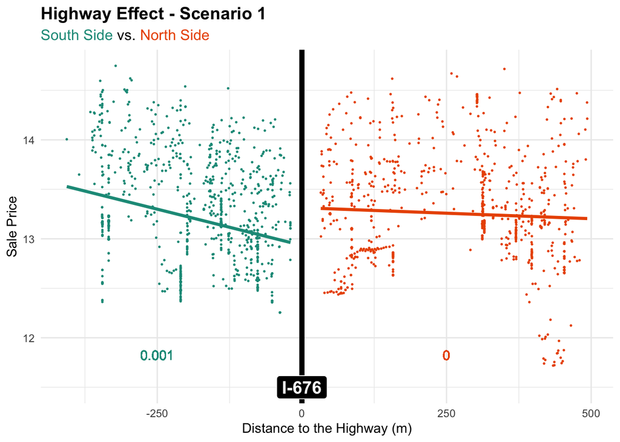

```r
property_S1 <- st_transform(property_S1_predict, 2272)

discontinuity_S1_predict <- property_S1 %>%
  filter(predicted_price > 100)

discontinuity_S1_predict <- rbind(
  discontinuity_S1_predict %>% st_intersection(studyarea_north["geometry"]) %>%
    mutate(I676_NS = "north"),
  discontinuity_S1_predict %>% st_intersection(studyarea_south["geometry"]) %>%
    mutate(I676_NS = "south")
)

discontinuity_S1_predict <- discontinuity_S1_predict %>%
  st_drop_geometry() %>%
  mutate(
    distance_to_I676m = distance_to_I676 * 0.3048,
    distance_to_highway = case_when(
      I676_NS == "north" ~ distance_to_I676m,
      I676_NS == "south" ~ -distance_to_I676m
    )
  )

discontinuity_S1_predict <- discontinuity_S1_predict %>%
  filter(abs(distance_to_highway) <= 500)

coef_north_S1 <- round(
  summary(
    lm(log(predicted_price+1) ~ distance_to_highway,
       data = discontinuity_S1_predict,
       subset = I676_NS == "north"))$coefficients[2,1], 3)

coef_south_S1 <- round(
  summary(
    lm(log(predicted_price+1) ~ abs(distance_to_highway),
       data = discontinuity_S1_predict,
       subset = I676_NS == "south"))$coefficients[2,1], 3)

discontinuity_plot_S1 <- ggplot(data = discontinuity_S1_predict) +
  geom_point(aes(x = distance_to_highway, y = log(predicted_price+1), color = I676_NS), size = 0.3) +
  geom_smooth(aes(x = distance_to_highway, y = log(predicted_price+1), color = I676_NS),
              method = "lm", se = FALSE, linewidth = 1.2) +
  geom_vline(xintercept = 0, color = "black", linewidth = 2) +
  scale_colour_manual(values = c("north" = "#eb5600", "south" = "#1a9988")) +
  theme_minimal() +
  theme(
    legend.position = "None",
    plot.title = element_text(size = 14, face = "bold"),
    plot.subtitle = ggtext::element_markdown(size = 12),
    plot.caption = element_text(hjust = 0)
  ) +
  labs(
    title = 'Highway Effect - Scenario 1',
    subtitle = glue("<span style='color:#1a9988;'>South Side</span> vs. <span style='color:#eb5600;'>North Side</span>"),
    x = "Distance to the Highway (m)",
    y = "Sale Price"
  ) +
  geom_label(aes(x = 0, y = 11.5, label = "I-676"),
             fill = "black", color = "white", fontface = "bold", size = 5) +
  geom_text(aes(label = coef_north_S1,
                x = 250,
                y = 11.825),
            color = "#eb5600",
            show.legend = F) +
  geom_text(aes(label = coef_south_S1,
                x = -250,
                y = 11.825),
            color = "#1a9988",
            show.legend = F)
discontinuity_plot_S1
```

```r
ggsave(
  filename = "~/Documents/Upenn/Practicum/2025/Chinatown-Practicum-my/finalresults/discontinuity_plot_S1.png",
  plot = discontinuity_plot_S1,
  height = 5,
  width = 8.5,
  units = "in",
  dpi = 300
)
```

## 5.3 Alternated Features - commercial perspective

```r
median_bedroom <- median(as.numeric(as.character(property_S2_no_fe$number_of_bedrooms)), na.rm = TRUE)
median_bathroom <- median(as.numeric(as.character(property_S2_no_fe$number_of_bathrooms)), na.rm = TRUE)

property_S2_fe <- property_S2_no_fe %>%
#  filter(!zoning %in% c("I2", "SPPOA"))%>%
  mutate(
        # Neighborhood Name
    nhoods_name = case_when(
      nhoods_name %in% c("CENTER_CITY", "LOGAN_SQUARE") ~ "WEST_PART",
      TRUE ~ nhoods_name
    ),

    # Land Use
    landuse = case_when(
      landuse %in% c("Park/Open Space", "Other/Unknown", "Commercial Business/Professional") ~ "Open Space/Business",
      landuse %in% c("Commercial Consumer", "Commercial Mixed Residential",
                     "Industrial", "Transportation", "Culture/Amusement") ~ "Commercial",
      landuse %in% c("Civic/Institution", "Residential High") ~ "Residential High/Civic",
      TRUE ~ landuse
    ),

    # Year Built
    year_built = as.numeric(year_built),
    year_built_missing = ifelse(is.na(year_built), 1, 0),
    year_built_group = case_when(
       is.na(year_built) ~ "Unknown",
       year_built < 1940 ~ "Pre-War",
       year_built < 2000 ~ "Post-War Mid",
       year_built < 2020 ~ "Modern",
       year_built >= 2020 ~ "New"
    ),
    year_built_group = factor(year_built_group, levels = c("Pre-War", "Post-War Mid", "Modern", "New", "Unknown")),
    # Log Transforms
    log_price = log(sale_price),
    log_dist_highway = log(distance_to_I676 + 1),

    # Central Air
    central_air = case_when(
      central_air %in% c("Y", "1")  ~ "Y",
      central_air %in% c("N", "0") ~ "N",
      TRUE ~ "Unknown"
    ),
    central_air = factor(central_air),
    central_air_missing = ifelse(central_air == "Unknown", 1, 0),

    # Garage Spaces
    garage_spaces_missing = ifelse(is.na(garage_spaces), 1, 0),
    garage_spaces = case_when(
#      is.na(garage_spaces) ~ "Unknown",
      garage_spaces == 0 | garage_spaces == 1 ~ "less than 2",
      TRUE ~ "2 or more"
    ),
    garage_spaces = factor(garage_spaces),

    # Bedrooms
    number_of_bedrooms = as.numeric(as.character(number_of_bedrooms)),
    number_of_bedrooms_missing = ifelse(is.na(number_of_bedrooms), 1, 0),
    number_of_bedrooms_filled = ifelse(is.na(number_of_bedrooms), median_bedroom, number_of_bedrooms),
    number_of_bedrooms = case_when(
      is.na(number_of_bedrooms) ~ "Unknown",
      number_of_bedrooms == 0 ~ "0",
      number_of_bedrooms == 1 ~ "1",
      number_of_bedrooms %in% c(2, 3) ~ "2",
      number_of_bedrooms %in% c(5, 6) ~ "3",
      number_of_bedrooms == 4 ~"4",
      number_of_bedrooms %in% c(7, 9, 12) ~ "5"
    ),
    number_of_bedrooms = factor(number_of_bedrooms),

    # Bathrooms
    number_of_bathrooms = as.numeric(as.character(number_of_bathrooms)),
    number_of_bathrooms_missing = ifelse(is.na(number_of_bathrooms), 1, 0),
    number_of_bathrooms_filled = ifelse(is.na(number_of_bathrooms), median_bathroom, number_of_bathrooms),
    number_of_bathrooms = case_when(
      number_of_bathrooms == 0 ~ "0",
      number_of_bathrooms == 1 ~ "1",
      number_of_bathrooms == 2 ~ "2",
      number_of_bathrooms %in% c(3, 4, 5) ~ "3-5",
      number_of_bathrooms == 6 ~ "6",
      number_of_bathrooms == 7 ~ "7",
      TRUE ~ "Unknown"
    ),
    number_of_bathrooms = factor(number_of_bathrooms),

    # Total Livable Area
    total_livable_area = ifelse(is.na(total_livable_area) | total_livable_area == 1, 0, total_livable_area),

    # Quality Grade
    quality_grade = case_when(
      quality_grade %in% c("A ", "A-") | is.na(quality_grade) ~ "Good",
      quality_grade %in% c("3 ", "C+", "C")  ~ "Average",
      TRUE ~ "Below Average"
    ),
    quality_grade = factor(quality_grade, levels = c("Good", "Average", "Below Average")),
    quality_grade_missing = ifelse(is.na(quality_grade), 1, 0),

    # Construction
    general_construction = as.character(general_construction),
    general_construction = case_when(
      is.na(general_construction) ~ "Unknown",
      TRUE ~ general_construction
    ),
    general_construction = factor(general_construction),
    general_construction_missing = ifelse(general_construction == "Unknown", 1, 0),

    # Separate Utilities
    separate_utilities = case_when(
      is.na(separate_utilities) ~ "Unknown",
      TRUE ~ separate_utilities
    ),
    separate_utilities = factor(separate_utilities, levels = c("A", "B", "C", "Unknown")),
    separate_utilities_missing = ifelse(separate_utilities == "Unknown", 1, 0),

    # Exterior Condition
    exterior_condition = case_when(
      exterior_condition == 2 ~ "Good",
      exterior_condition %in% c(1, 6, 7) | is.na(exterior_condition) ~ "Average",
      exterior_condition %in% c(3, 4, 5) ~ "Below Average"
 #     TRUE ~ "Unknown"
    ),
    exterior_condition = factor(exterior_condition),

    # Interior Condition
    interior_condition = case_when(
      interior_condition %in% c(1,2,7) | is.na(interior_condition) ~ "Good",
      interior_condition %in% c(3,4,5) ~ "Average",
      interior_condition %in% c(6) ~ "Below Average",
      TRUE ~ "Unknown"
    ),
    interior_condition = factor(interior_condition),

    # Category Code
    category_code_original = as.character(category_code),
    category_code_group = case_when(
      category_code == "12" ~ "6 ",
      category_code == "14" ~ "2 ",
      category_code == "10" ~ "4 ",
      category_code == "15" ~ "5 ",
      category_code == "16" ~ "4 ",
      category_code == "7 "  ~ "4 ",
      category_code == "8 "  ~ "6 ",
      category_code == "9 "  ~ "2 ",
      category_code %in% c("1 ", "2 ", "3 ", "4 ", "5 ", "6 ") ~ category_code,
      TRUE ~ "Other"
    ),
    category_code = factor(category_code_group),

    # Zoning
    zoning_group = case_when(
      zoning %in% c("CMX5") ~ "CMX5",
      zoning %in% c("IRMX") ~ "IRMX",
      zoning %in% c("RM1", "RM2", "RM4") ~ "RM",
      zoning %in% c("RMX3") ~ "RMX3",
      zoning %in% c("RSA5") ~ "RSA5",
      zoning %in% c("ICMX") ~ "ICMX",
      zoning %in% c("SPPOA") ~ "SPPOA",
      zoning %in% c("I2") ~ "I2",
      zoning %in% c("CMX2.5", "CMX2", "CMX1") ~ "CMX(1,2,2.5)",
      zoning %in% c("CMX3", "CMX4") ~ "CMX(3,4)",
      TRUE ~ "Other"
    ),
    zoning_group = factor(zoning_group),

    zoning = case_when(
      is.na(zoning) ~ "Unknown",
      TRUE ~ zoning
    ),
    zoning = factor(zoning),
    zip_code = factor(zip_code)
  )

mean_depth <- mean(property_S2_fe$depth, na.rm = TRUE)
property_S2_fe$depth[is.na(property_S2_fe$depth)] <- mean_depth
```

```r
property_modeling_s2 <- property_S2_fe %>%
  mutate(
    Longitude = st_coordinates(.)[, 1],
    Latitude = st_coordinates(.)[, 2]
  ) %>%
  st_drop_geometry() %>%
  mutate(
    log_distance_to_city_hall = log(distance_to_city_hall + 1),
    log_nearest_restaurant_dist_m = log(nearest_restaurant_dist_m + 1),
    log_distance_to_nearest_park = log(distance_to_nearest_park + 1),
    log_distance_to_nearest_water = log(distance_to_nearest_water + 1),
    log_total_livable_area = log1p(total_livable_area),
#    log_adj_sale_price = log(adj_sale_price + 1)  # optional, not used during prediction
  ) %>%
  select(
    log_dist_highway,
    log_distance_to_city_hall,
    log_nearest_restaurant_dist_m,
    log_distance_to_nearest_park,
    zoning_group,
    zip_code,
    exterior_condition,
    interior_condition,
    log_total_livable_area,
    number_of_bathrooms,
    number_of_bedrooms,
    quality_grade,
    log_distance_to_nearest_water,
    central_air,
    year_built_group,
    LPSS_PER1000,
    general_construction,
    garage_spaces,
    separate_utilities,
    category_code,
    crime_nn5,
    nhoods_name,
    landuse,
    Longitude, Latitude
  )
rf_model <- readRDS("Modeling/results/rf_model.rds")
rf_workflow <- readRDS("Modeling/results/rf_workflow.rds")
predicted_log_price <- predict(rf_workflow, new_data = property_modeling_s2)$.pred
property_S2_fe$predicted_price <- exp(predicted_log_price) - 1

st_write(property_S2_fe, "~/Documents/Upenn/Practicum/2025/Chinatown-Practicum-my/finalresults/property_S2_fe.geojson", driver = "GeoJSON", delete_dsn = TRUE)
st_write(property_S2_fe, "~/Documents/Upenn/Practicum/2025/Chinatown-Practicum-my/finalresults/property_S2_fe.json", driver = "GeoJSON", delete_dsn = TRUE)

property_S2_4326 <- property_S2_fe %>%st_transform('EPSG:4326')
property_S2_predict <- property_S2_fe%>%st_transform('EPSG:2272')
```

### 5.3.1 Alternate Commercial Property Map

```r
qBr(property_S1_predict %>% filter(adj_sale_price > 100), "adj_sale_price")
```

```
## [1] "15120.39" "234436"   "351181"   "461603.6" "841127"
```

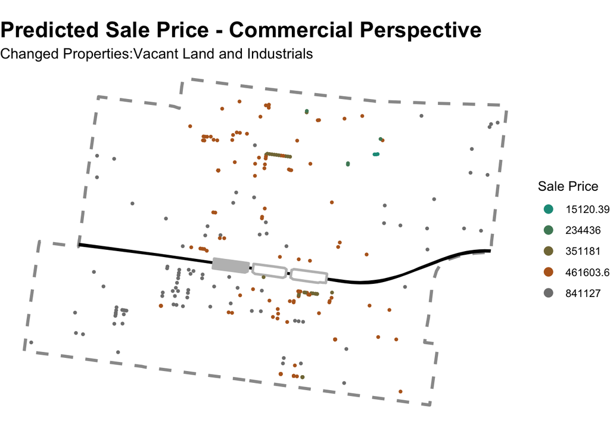

```r
qBr_S1 <- qBr(property_S1_predict %>% filter(adj_sale_price > 100), "adj_sale_price")

S2_changed <- property_S2_fe %>%
  filter(
    landuse_old != landuse_new |
    category_code_old != category_code_new |
    zoning_old != zoning_new
  )

S2_changed_map <- ggplot() +
  geom_sf(data = studyarea, fill = "transparent", color = "grey60", linetype = "dashed", linewidth = 1.2) +
  geom_sf(data = discontinuity, fill = "black", color = "transparent") +
  geom_sf(data = Chinatown_Stitch %>% filter(FID_ == 500391), fill = "grey", color = "grey", linewidth = 1) +
  geom_sf(data = Chinatown_Stitch %>% filter(FID_ != 500391), fill = "white", color = "grey", linewidth = 1) +

  geom_sf(data = S2_changed %>% filter(!is.na(predicted_price)),
          aes(colour = cut(predicted_price, breaks = qBr_S1, include.lowest = TRUE)),
          show.legend = "point", size = 0.8) +

  scale_colour_manual(values = palette5,
                      labels = qBr_S1,
                      name = "Sale Price") +

  guides(color = guide_legend(override.aes = list(size = 3))) +

  labs(
    title = "Predicted Sale Price - Commercial Perspective",
    subtitle = "Changed Properties:Vacant Land and Industrials "
  ) +
  theme_void() +
  theme(
    plot.title = element_text(size = 18, face = "bold"),
    plot.subtitle = element_text(size = 12)
  )

S2_changed_map
```

```r
ggsave(filename = "~/Documents/Upenn/Practicum/2025/Chinatown-Practicum-my/finalresults/S2_comm_map.png", plot =S2_changed_map, height = 5, width = 8.5, units = "in", dpi = 300)
```

### 5.3.2 Alternate Commercial - discontinuity plot

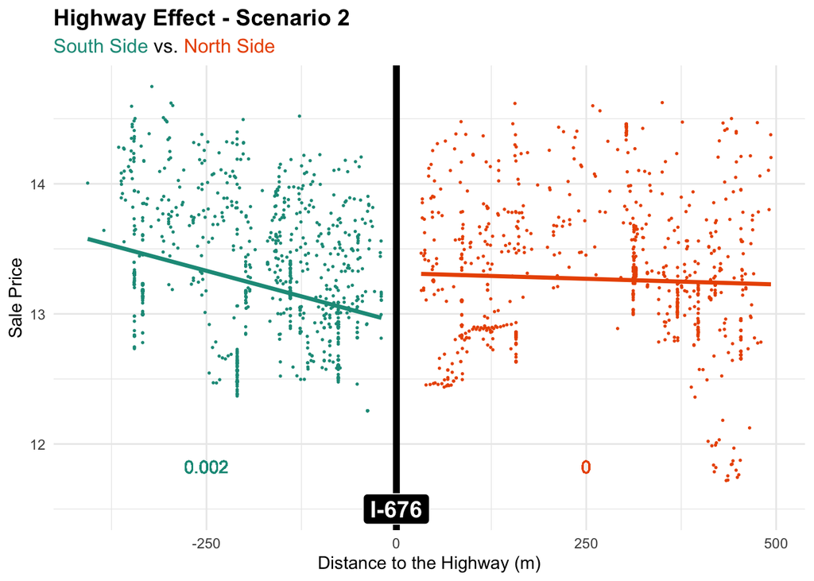

```r
property_S2 <- st_transform(property_S2_predict, 2272)

discontinuity_S2 <- property_S2 %>%
  filter(predicted_price > 100)  # 注意这里用 predicted_price，不是 adj_sale_price

discontinuity_S2 <- rbind(
  discontinuity_S2 %>% st_intersection(studyarea_north["geometry"]) %>%
    mutate(I676_NS = "north"),
  discontinuity_S2 %>% st_intersection(studyarea_south["geometry"]) %>%
    mutate(I676_NS = "south")
)

discontinuity_S2 <- discontinuity_S2 %>%
  st_drop_geometry() %>%
  mutate(distance_to_I676m = distance_to_I676 * 0.3048,
         distance_to_highway = case_when(
           I676_NS == "north" ~ distance_to_I676m,
           I676_NS == "south" ~ -distance_to_I676m
         ))
discontinuity_S2 <- discontinuity_S2 %>%
  filter(abs(distance_to_highway) <= 500)

coef_north_S2 <- round(
  summary(
    lm(log(predicted_price+1) ~ distance_to_highway,
       data = discontinuity_S2,
       I676_NS == "north"))$coefficients[2,1], 3)

coef_south_S2 <- round(
  summary(
    lm(log(predicted_price+1) ~ abs(distance_to_highway),
       data = discontinuity_S2,
       I676_NS == "south"))$coefficients[2,1], 3)

discontinuity_plot_S2 <- ggplot(data = discontinuity_S2) +
  geom_point(aes(x = distance_to_highway, y = log(predicted_price+1), color = I676_NS), size = 0.3) +
  geom_smooth(aes(x = distance_to_highway, y = log(predicted_price+1), color = I676_NS), method = "lm", se = FALSE, linewidth = 1.2) +
  geom_vline(xintercept = 0, color = "black", linewidth = 2) +
  scale_colour_manual(values = c("north" = "#eb5600", "south" = "#1a9988")) +
  theme_minimal() +
  theme(legend.position = "None",
        plot.title = element_text(size = 14, face = "bold"),
        plot.subtitle = ggtext::element_markdown(size = 12),
        plot.caption = element_text(hjust = 0)) +
  labs(title = 'Highway Effect - Scenario 2',
       subtitle = glue("<span style='color:#1a9988;'>South Side</span> vs. <span style='color:#eb5600;'>North Side</span>"),
       x = "Distance to the Highway (m)",
       y = "Sale Price") +
  geom_label(aes(x = 0, y = 11.5, label = "I-676"),
             fill = "black", color = "white", fontface = "bold", size = 5) +
  geom_text(aes(label = coef_north_S2,
                x = 250,
                y = 11.825),
            color = "#eb5600",
            show.legend = F) +
  geom_text(aes(label = coef_south_S2,
                x = -250,
                y = 11.825),
            color = "#1a9988",
            show.legend = F)

discontinuity_plot_S2
```

```r
ggsave(
  filename = "~/Documents/Upenn/Practicum/2025/Chinatown-Practicum-my/finalresults/discontinuity_plot_S2.png",
  plot = discontinuity_plot_S2,
  height = 5,
  width = 8.5,
  units = "in",
  dpi = 300
)
```

## 5.4 Alternate Features - residential perspective

```r
median_bedroom <- median(as.numeric(as.character(property_S3_no_fe$number_of_bedrooms)), na.rm = TRUE)
median_bathroom <- median(as.numeric(as.character(property_S3_no_fe$number_of_bathrooms)), na.rm = TRUE)

property_S3_fe <- property_S3_no_fe %>%
#  filter(!zoning %in% c("I2", "SPPOA"))%>%
  mutate(
        # Neighborhood Name
    nhoods_name = case_when(
      nhoods_name %in% c("CENTER_CITY", "LOGAN_SQUARE") ~ "WEST_PART",
      TRUE ~ nhoods_name
    ),

    # Land Use
    landuse = case_when(
      landuse %in% c("Park/Open Space", "Other/Unknown", "Commercial Business/Professional") ~ "Open Space/Business",
      landuse %in% c("Commercial Consumer", "Commercial Mixed Residential",
                     "Industrial", "Transportation", "Culture/Amusement") ~ "Commercial",
      landuse %in% c("Civic/Institution", "Residential High") ~ "Residential High/Civic",
      TRUE ~ landuse
    ),

    # Year Built
    year_built = as.numeric(year_built),
    year_built_missing = ifelse(is.na(year_built), 1, 0),
    year_built_group = case_when(
       is.na(year_built) ~ "Unknown",
       year_built < 1940 ~ "Pre-War",
       year_built < 2000 ~ "Post-War Mid",
       year_built < 2020 ~ "Modern",
       year_built >= 2020 ~ "New"
    ),
    year_built_group = factor(year_built_group, levels = c("Pre-War", "Post-War Mid", "Modern", "New", "Unknown")),

    # Log Transforms
    log_price = log(sale_price),
    log_dist_highway = log(distance_to_I676 + 1),

    # Central Air
    central_air = case_when(
      central_air %in% c("Y", "1")  ~ "Y",
      central_air %in% c("N", "0") ~ "N",
      TRUE ~ "Unknown"
    ),
    central_air = factor(central_air),
    central_air_missing = ifelse(central_air == "Unknown", 1, 0),

    # Garage Spaces
    garage_spaces_missing = ifelse(is.na(garage_spaces), 1, 0),
    garage_spaces = case_when(
#      is.na(garage_spaces) ~ "Unknown",
      garage_spaces == 0 | garage_spaces == 1 ~ "less than 2",
      TRUE ~ "2 or more"
    ),
    garage_spaces = factor(garage_spaces),

    # Bedrooms
    number_of_bedrooms = as.numeric(as.character(number_of_bedrooms)),
    number_of_bedrooms_missing = ifelse(is.na(number_of_bedrooms), 1, 0),
    number_of_bedrooms_filled = ifelse(is.na(number_of_bedrooms), median_bedroom, number_of_bedrooms),
    number_of_bedrooms = case_when(
      is.na(number_of_bedrooms) ~ "Unknown",
      number_of_bedrooms == 0 ~ "0",
      number_of_bedrooms == 1 ~ "1",
      number_of_bedrooms %in% c(2, 3) ~ "2",
      number_of_bedrooms %in% c(5, 6) ~ "3",
      number_of_bedrooms == 4 ~"4",
      number_of_bedrooms %in% c(7, 9, 12) ~ "5"
    ),
    number_of_bedrooms = factor(number_of_bedrooms),

    # Bathrooms
    number_of_bathrooms = as.numeric(as.character(number_of_bathrooms)),
    number_of_bathrooms_missing = ifelse(is.na(number_of_bathrooms), 1, 0),
    number_of_bathrooms_filled = ifelse(is.na(number_of_bathrooms), median_bathroom, number_of_bathrooms),
    number_of_bathrooms = case_when(
      number_of_bathrooms == 0 ~ "0",
      number_of_bathrooms == 1 ~ "1",
      number_of_bathrooms == 2 ~ "2",
      number_of_bathrooms %in% c(3, 4, 5) ~ "3-5",
      number_of_bathrooms == 6 ~ "6",
      number_of_bathrooms == 7 ~ "7",
      TRUE ~ "Unknown"
    ),
    number_of_bathrooms = factor(number_of_bathrooms),

    # Total Livable Area
    total_livable_area = ifelse(is.na(total_livable_area) | total_livable_area == 1, 0, total_livable_area),

    # Quality Grade
    quality_grade = case_when(
      quality_grade %in% c("A ", "A-") | is.na(quality_grade) ~ "Good",
      quality_grade %in% c("3 ", "C+", "C")  ~ "Average",
      TRUE ~ "Below Average"
    ),
    quality_grade = factor(quality_grade, levels = c("Good", "Average", "Below Average")),
    quality_grade_missing = ifelse(is.na(quality_grade), 1, 0),

    # Construction
    general_construction = as.character(general_construction),
    general_construction = case_when(
      is.na(general_construction) ~ "Unknown",
      TRUE ~ general_construction
    ),
    general_construction = factor(general_construction),
    general_construction_missing = ifelse(general_construction == "Unknown", 1, 0),

    # Separate Utilities
    separate_utilities = case_when(
      is.na(separate_utilities) ~ "Unknown",
      TRUE ~ separate_utilities
    ),
    separate_utilities = factor(separate_utilities, levels = c("A", "B", "C", "Unknown")),
    separate_utilities_missing = ifelse(separate_utilities == "Unknown", 1, 0),

    # Exterior Condition
    exterior_condition = case_when(
      exterior_condition == 2 ~ "Good",
      exterior_condition %in% c(1, 6, 7) | is.na(exterior_condition) ~ "Average",
      exterior_condition %in% c(3, 4, 5) ~ "Below Average"
 #     TRUE ~ "Unknown"
    ),
    exterior_condition = factor(exterior_condition),

    # Interior Condition
    interior_condition = case_when(
      interior_condition %in% c(1,2,7) | is.na(interior_condition) ~ "Good",
      interior_condition %in% c(3,4,5) ~ "Average",
      interior_condition %in% c(6) ~ "Below Average",
      TRUE ~ "Unknown"
    ),
    interior_condition = factor(interior_condition),

    # Category Code
    category_code_original = as.character(category_code),
    category_code_group = case_when(
      category_code == "12" ~ "6 ",
      category_code == "14" ~ "2 ",
      category_code == "10" ~ "4 ",
      category_code == "15" ~ "5 ",
      category_code == "16" ~ "4 ",
      category_code == "7 "  ~ "4 ",
      category_code == "8 "  ~ "6 ",
      category_code == "9 "  ~ "2 ",
      category_code %in% c("1 ", "2 ", "3 ", "4 ", "5 ", "6 ") ~ category_code,
      TRUE ~ "Other"
    ),
    category_code = factor(category_code_group),

    # Zoning
    zoning_group = case_when(
      zoning %in% c("CMX5") ~ "CMX5",
      zoning %in% c("IRMX") ~ "IRMX",
      zoning %in% c("RM1", "RM2", "RM4") ~ "RM",
      zoning %in% c("RMX3") ~ "RMX3",
      zoning %in% c("RSA5") ~ "RSA5",
      zoning %in% c("ICMX") ~ "ICMX",
      zoning %in% c("SPPOA") ~ "SPPOA",
      zoning %in% c("I2") ~ "I2",
      zoning %in% c("CMX2.5", "CMX2", "CMX1") ~ "CMX(1,2,2.5)",
      zoning %in% c("CMX3", "CMX4") ~ "CMX(3,4)",
      TRUE ~ "Other"
    ),
    zoning_group = factor(zoning_group),

    zoning = case_when(
      is.na(zoning) ~ "Unknown",
      TRUE ~ zoning
    ),
    zoning = factor(zoning),
    zip_code = factor(zip_code)
  )

mean_depth <- mean(property_S3_fe$depth, na.rm = TRUE)
property_S3_fe$depth[is.na(property_S2_fe$depth)] <- mean_depth
```

```r
property_modeling_s3 <- property_S3_fe %>%
  mutate(
    Longitude = st_coordinates(.)[, 1],
    Latitude = st_coordinates(.)[, 2]
  ) %>%
  st_drop_geometry() %>%
  mutate(
    log_distance_to_city_hall = log(distance_to_city_hall + 1),
    log_nearest_restaurant_dist_m = log(nearest_restaurant_dist_m + 1),
    log_distance_to_nearest_park = log(distance_to_nearest_park + 1),
    log_distance_to_nearest_water = log(distance_to_nearest_water + 1),
    log_total_livable_area = log1p(total_livable_area),
#    log_adj_sale_price = log(adj_sale_price + 1)  # optional, not used during prediction
  ) %>%
  select(
    log_dist_highway,
    log_distance_to_city_hall,
    log_nearest_restaurant_dist_m,
    log_distance_to_nearest_park,
    zoning_group,
    zip_code,
    exterior_condition,
    interior_condition,
    log_total_livable_area,
    number_of_bathrooms,
    number_of_bedrooms,
    quality_grade,
    log_distance_to_nearest_water,
    central_air,
    year_built_group,
    LPSS_PER1000,
    general_construction,
    garage_spaces,
    separate_utilities,
    category_code,
    crime_nn5,
    nhoods_name,
    landuse,
    Longitude, Latitude
  )
rf_model <- readRDS("Modeling/results/rf_model.rds")
rf_workflow <- readRDS("Modeling/results/rf_workflow.rds")
predicted_log_price <- predict(rf_workflow, new_data = property_modeling_s3)$.pred
property_S3_fe$predicted_price <- exp(predicted_log_price) - 1

st_write(property_S3_fe, "~/Documents/Upenn/Practicum/2025/Chinatown-Practicum-my/finalresults/property_S3_fe.geojson", driver = "GeoJSON", delete_dsn = TRUE)
st_write(property_S3_fe, "~/Documents/Upenn/Practicum/2025/Chinatown-Practicum-my/finalresults/property_S3_fe.json", driver = "GeoJSON", delete_dsn = TRUE)

property_S3_4326 <- property_S3_fe%>%st_transform('EPSG:4326')
property_S3_predict <- property_S3_fe%>%st_transform('EPSG:2272')
```

### 5.4.1 Alternate Residential Property Map

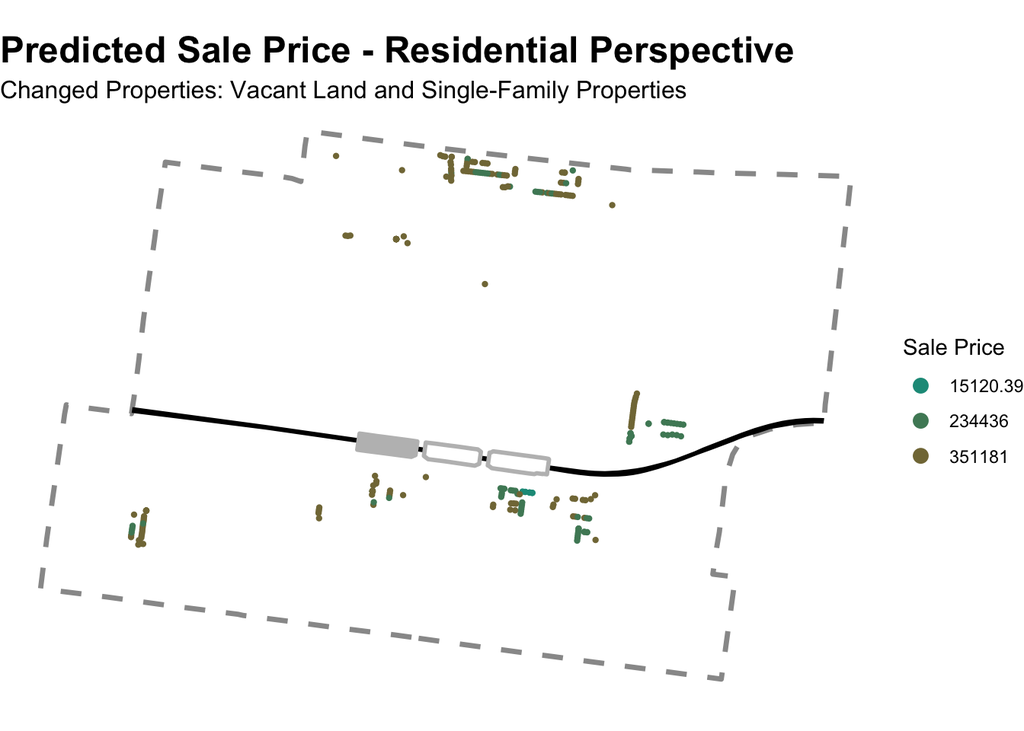

```r
S3_changed <- property_S3_fe %>%
  filter(
    landuse_old != landuse_new |
    category_code_old != category_code_new |
    zoning_old != zoning_new
  )

S3_changed_map <- ggplot() +
  geom_sf(data = studyarea, fill = "transparent", color = "grey60", linetype = "dashed", linewidth = 1.2) +
  geom_sf(data = discontinuity, fill = "black", color = "transparent") +
  geom_sf(data = Chinatown_Stitch %>% filter(FID_ == 500391), fill = "grey", color = "grey", linewidth = 1) +
  geom_sf(data = Chinatown_Stitch %>% filter(FID_ != 500391), fill = "white", color = "grey", linewidth = 1) +

  geom_sf(data = S3_changed %>% filter(!is.na(predicted_price)),
          aes(colour = cut(predicted_price, breaks = qBr_S1, include.lowest = TRUE)),
          show.legend = "point", size = 0.8) +

  scale_colour_manual(values = palette5,
                      labels = qBr_S1,
                      name = "Sale Price") +

  guides(color = guide_legend(override.aes = list(size = 3))) +

  labs(
    title = "Predicted Sale Price - Residential Perspective",
    subtitle = "Changed Properties: Vacant Land and Single-Family Properties"
  ) +
  theme_void() +
  theme(
    plot.title = element_text(size = 18, face = "bold"),
    plot.subtitle = element_text(size = 12)
  )

S3_changed_map
```

```r
ggsave(filename = "~/Documents/Upenn/Practicum/2025/Chinatown-Practicum-my/finalresults/S3_res_map.png", plot = S3_changed_map, height = 5, width = 8.5, units = "in", dpi = 300)
```

### 5.4.2 Alternate Residential - discontinuity plot

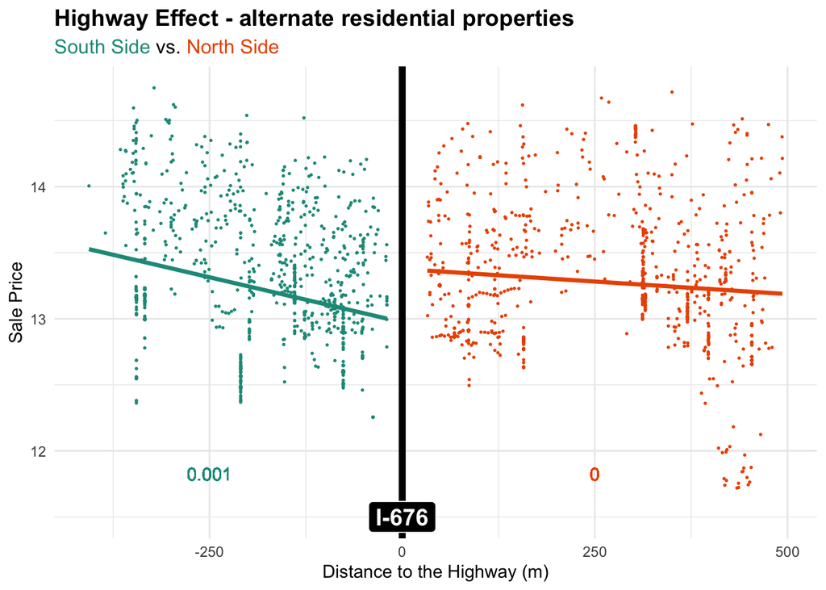

```r
property_S3 <- st_transform(property_S3_predict, 2272)

discontinuity_S3 <- property_S3 %>%
  filter(predicted_price > 100)

discontinuity_S3 <- rbind(
  discontinuity_S3 %>% st_intersection(studyarea_north["geometry"]) %>%
    mutate(I676_NS = "north"),
  discontinuity_S3 %>% st_intersection(studyarea_south["geometry"]) %>%
    mutate(I676_NS = "south")
)


discontinuity_S3 <- discontinuity_S3 %>%
  st_drop_geometry() %>%
  mutate(distance_to_I676m = distance_to_I676 * 0.3048,
         distance_to_highway = case_when(
           I676_NS == "north" ~ distance_to_I676m,
           I676_NS == "south" ~ -distance_to_I676m
         ))

discontinuity_S3 <- discontinuity_S3 %>%
  filter(abs(distance_to_highway) <= 500)

coef_north_S3 <- round(
  summary(
    lm(log(predicted_price+1) ~ distance_to_highway,
       data = discontinuity_S3,
       I676_NS == "north"))$coefficients[2,1], 3)

coef_south_S3 <- round(
  summary(
    lm(log(predicted_price+1) ~ abs(distance_to_highway),
       data = discontinuity_S3,
       I676_NS == "south"))$coefficients[2,1], 3)

discontinuity_plot_S3 <- ggplot(data = discontinuity_S3) +
  geom_point(aes(x = distance_to_highway, y = log(predicted_price+1), color = I676_NS), size = 0.3) +
  geom_smooth(aes(x = distance_to_highway, y = log(predicted_price+1), color = I676_NS), method = "lm", se = FALSE, linewidth = 1.2) +
  geom_vline(xintercept = 0, color = "black", linewidth = 2) +
  scale_colour_manual(values = c("north" = "#eb5600", "south" = "#1a9988")) +
  theme_minimal() +
  theme(legend.position = "None",
        plot.title = element_text(size = 14, face = "bold"),
        plot.subtitle = ggtext::element_markdown(size = 12),
        plot.caption = element_text(hjust = 0)) +
  labs(title = 'Highway Effect - alternate residential properties',
       subtitle = glue("<span style='color:#1a9988;'>South Side</span> vs. <span style='color:#eb5600;'>North Side</span>"),
       x = "Distance to the Highway (m)",
       y = "Sale Price") +
  geom_label(aes(x = 0, y = 11.5, label = "I-676"),
             fill = "black", color = "white", fontface = "bold", size = 5) +
  geom_text(aes(label = coef_north_S3,
                x = 250,
                y = 11.825),
            color = "#eb5600",
            show.legend = F) +
  geom_text(aes(label = coef_south_S3,
                x = -250,
                y = 11.825),
            color = "#1a9988",
            show.legend = F)

discontinuity_plot_S3
```

```r
ggsave(
  filename = "~/Documents/Upenn/Practicum/2025/Chinatown-Practicum-my/finalresults/discontinuity_plot_S3.png",
  plot = discontinuity_plot_S3,
  height = 5,
  width = 8.5,
  units = "in",
  dpi = 300
)
```

## 5.5 Scenario 2

```r
median_bedroom <- median(as.numeric(as.character(property_S4_no_fe$number_of_bedrooms)), na.rm = TRUE)
median_bathroom <- median(as.numeric(as.character(property_S4_no_fe$number_of_bathrooms)), na.rm = TRUE)

property_S4_fe <- property_S4_no_fe %>%
#  filter(!zoning %in% c("I2", "SPPOA"))%>%
  mutate(
        # Neighborhood Name
    nhoods_name = case_when(
      nhoods_name %in% c("CENTER_CITY", "LOGAN_SQUARE") ~ "WEST_PART",
      TRUE ~ nhoods_name
    ),

    # Land Use
    landuse = case_when(
      landuse %in% c("Park/Open Space", "Other/Unknown", "Commercial Business/Professional") ~ "Open Space/Business",
      landuse %in% c("Commercial Consumer", "Commercial Mixed Residential",
                     "Industrial", "Transportation", "Culture/Amusement") ~ "Commercial",
      landuse %in% c("Civic/Institution", "Residential High") ~ "Residential High/Civic",
      TRUE ~ landuse
    ),
    # Year Built
    year_built = as.numeric(year_built),
    year_built_missing = ifelse(is.na(year_built), 1, 0),
#    year_built = case_when(
#      is.na(year_built) ~ "Unknown",
#      TRUE ~ as.character(year_built)
#    ),
#    year_built = factor(year_built),
    year_built_group = case_when(
       is.na(year_built) ~ "Unknown",
       year_built < 1940 ~ "Pre-War",
       year_built < 2000 ~ "Post-War Mid",
       year_built < 2020 ~ "Modern",
       year_built >= 2020 ~ "New"
    ),
    year_built_group = factor(year_built_group, levels = c("Pre-War", "Post-War Mid", "Modern", "New", "Unknown")),
    # Log Transforms
    log_price = log(sale_price),
    log_dist_highway = log(distance_to_I676 + 1),

    # Central Air
    central_air = case_when(
      central_air %in% c("Y", "1")  ~ "Y",
      central_air %in% c("N", "0") ~ "N",
      TRUE ~ "Unknown"
    ),
    central_air = factor(central_air),
    central_air_missing = ifelse(central_air == "Unknown", 1, 0),

    # Garage Spaces
    garage_spaces_missing = ifelse(is.na(garage_spaces), 1, 0),
    garage_spaces = case_when(
#      is.na(garage_spaces) ~ "Unknown",
      garage_spaces == 0 | garage_spaces == 1 ~ "less than 2",
      TRUE ~ "2 or more"
    ),
    garage_spaces = factor(garage_spaces),

    # Bedrooms
    number_of_bedrooms = as.numeric(as.character(number_of_bedrooms)),
    number_of_bedrooms_missing = ifelse(is.na(number_of_bedrooms), 1, 0),
    number_of_bedrooms_filled = ifelse(is.na(number_of_bedrooms), median_bedroom, number_of_bedrooms),
    number_of_bedrooms = case_when(
      is.na(number_of_bedrooms) ~ "Unknown",
      number_of_bedrooms == 0 ~ "0",
      number_of_bedrooms == 1 ~ "1",
      number_of_bedrooms %in% c(2, 3) ~ "2",
      number_of_bedrooms %in% c(5, 6) ~ "3",
      number_of_bedrooms == 4 ~"4",
      number_of_bedrooms %in% c(7, 9, 12) ~ "5"
    ),
    number_of_bedrooms = factor(number_of_bedrooms),

    # Bathrooms
    number_of_bathrooms = as.numeric(as.character(number_of_bathrooms)),
    number_of_bathrooms_missing = ifelse(is.na(number_of_bathrooms), 1, 0),
    number_of_bathrooms_filled = ifelse(is.na(number_of_bathrooms), median_bathroom, number_of_bathrooms),
    number_of_bathrooms = case_when(
      number_of_bathrooms == 0 ~ "0",
      number_of_bathrooms == 1 ~ "1",
      number_of_bathrooms == 2 ~ "2",
      number_of_bathrooms %in% c(3, 4, 5) ~ "3-5",
      number_of_bathrooms == 6 ~ "6",
      number_of_bathrooms == 7 ~ "7",
      TRUE ~ "Unknown"
    ),
    number_of_bathrooms = factor(number_of_bathrooms),

    # Total Livable Area
    total_livable_area = ifelse(is.na(total_livable_area) | total_livable_area == 1, 0, total_livable_area),

    # Quality Grade
    quality_grade = case_when(
      quality_grade %in% c("A ", "A-") | is.na(quality_grade) ~ "Good",
      quality_grade %in% c("3 ", "C+", "C")  ~ "Average",
      TRUE ~ "Below Average"
    ),
    quality_grade = factor(quality_grade, levels = c("Good", "Average", "Below Average")),
    quality_grade_missing = ifelse(is.na(quality_grade), 1, 0),

    # Construction
    general_construction = as.character(general_construction),
    general_construction = case_when(
      is.na(general_construction) ~ "Unknown",
      TRUE ~ general_construction
    ),
    general_construction = factor(general_construction),
    general_construction_missing = ifelse(general_construction == "Unknown", 1, 0),

    # Separate Utilities
    separate_utilities = case_when(
      is.na(separate_utilities) ~ "Unknown",
      TRUE ~ separate_utilities
    ),
    separate_utilities = factor(separate_utilities, levels = c("A", "B", "C", "Unknown")),
    separate_utilities_missing = ifelse(separate_utilities == "Unknown", 1, 0),

    # Exterior Condition
    exterior_condition = case_when(
      exterior_condition == 2 ~ "Good",
      exterior_condition %in% c(1, 6, 7) | is.na(exterior_condition) ~ "Average",
      exterior_condition %in% c(3, 4, 5) ~ "Below Average"
 #     TRUE ~ "Unknown"
    ),
    exterior_condition = factor(exterior_condition),

    # Interior Condition
    interior_condition = case_when(
      interior_condition %in% c(1,2,7) | is.na(interior_condition) ~ "Good",
      interior_condition %in% c(3,4,5) ~ "Average",
      interior_condition %in% c(6) ~ "Below Average",
      TRUE ~ "Unknown"
    ),
    interior_condition = factor(interior_condition),

    # Category Code
    category_code_original = as.character(category_code),
    category_code_group = case_when(
      category_code == "12" ~ "6 ",
      category_code == "14" ~ "2 ",
      category_code == "10" ~ "4 ",
      category_code == "15" ~ "5 ",
      category_code == "16" ~ "4 ",
      category_code == "7 "  ~ "4 ",
      category_code == "8 "  ~ "6 ",
      category_code == "9 "  ~ "2 ",
      category_code %in% c("1 ", "2 ", "3 ", "4 ", "5 ", "6 ") ~ category_code,
      TRUE ~ "Other"
    ),
    category_code = factor(category_code_group),

    # Zoning
    zoning_group = case_when(
      zoning %in% c("CMX5") ~ "CMX5",
      zoning %in% c("IRMX") ~ "IRMX",
      zoning %in% c("RM1", "RM2", "RM4") ~ "RM",
      zoning %in% c("RMX3") ~ "RMX3",
      zoning %in% c("RSA5") ~ "RSA5",
      zoning %in% c("ICMX") ~ "ICMX",
      zoning %in% c("SPPOA") ~ "SPPOA",
      zoning %in% c("I2") ~ "I2",
      zoning %in% c("CMX2.5", "CMX2", "CMX1") ~ "CMX(1,2,2.5)",
      zoning %in% c("CMX3", "CMX4") ~ "CMX(3,4)",
      TRUE ~ "Other"
    ),
    zoning_group = factor(zoning_group),

    zoning = case_when(
      is.na(zoning) ~ "Unknown",
      TRUE ~ zoning
    ),
    zoning = factor(zoning),
    zip_code = factor(zip_code)
  )
```

```r
property_modeling_s4 <- property_S4_fe %>%
  mutate(
    Longitude = st_coordinates(.)[, 1],
    Latitude = st_coordinates(.)[, 2]
  ) %>%
  st_drop_geometry() %>%
  mutate(
    log_distance_to_city_hall = log(distance_to_city_hall + 1),
    log_nearest_restaurant_dist_m = log(nearest_restaurant_dist_m + 1),
    log_distance_to_nearest_park = log(distance_to_nearest_park + 1),
    log_distance_to_nearest_water = log(distance_to_nearest_water + 1),
    log_total_livable_area = log1p(total_livable_area),
  ) %>%
  select(
    log_dist_highway,
    log_distance_to_city_hall,
    log_nearest_restaurant_dist_m,
    log_distance_to_nearest_park,
    zoning_group,
    zip_code,
    exterior_condition,
    interior_condition,
    log_total_livable_area,
    number_of_bathrooms,
    number_of_bedrooms,
    quality_grade,
    log_distance_to_nearest_water,
    central_air,
    year_built_group,
    LPSS_PER1000,
    general_construction,
    garage_spaces,
    separate_utilities,
    category_code,
    crime_nn5,
    nhoods_name,
    landuse,
    Longitude, Latitude
  )
rf_model <- readRDS("Modeling/results/rf_model.rds")
rf_workflow <- readRDS("Modeling/results/rf_workflow.rds")
predicted_log_price <- predict(rf_workflow, new_data = property_modeling_s4)$.pred
property_S4_fe$predicted_price <- exp(predicted_log_price) - 1

st_write(property_S4_fe, "~/Documents/Upenn/Practicum/2025/Chinatown-Practicum-my/finalresults/property_S4_fe.geojson", driver = "GeoJSON", delete_dsn = TRUE)
st_write(property_S4_fe, "~/Documents/Upenn/Practicum/2025/Chinatown-Practicum-my/finalresults/property_S4_fe.json", driver = "GeoJSON", delete_dsn = TRUE)


property_S4_4326 <- property_S4_fe%>%st_transform('EPSG:4326')
property_S4_predict <- property_S4_fe%>%st_transform('EPSG:2272')
```

### 5.5.1 scenario 2 property map

```r
S4_map <- ggplot() +
  geom_sf(data = studyarea, fill = "transparent", color = "grey60", linewidth = 1.2, linetype = "dashed") +
  geom_sf(data = discontinuity, fill = "black", color = "transparent") +
  geom_sf(data = Chinatown_Stitch %>% filter(FID_ == 500391), fill = "grey", color = "grey", linewidth = 1) +
  geom_sf(data = Chinatown_Stitch %>% filter(FID_ != 500391), fill = "white", color = "grey", linewidth = 1) +
  geom_sf(data = property_S4_predict, aes(colour = q5(predicted_price)),
          show.legend = "point", size = .8) +
  scale_colour_manual(values = palette5,
                      labels = qBr(property_S4_predict %>% filter (adj_sale_price > 100), "adj_sale_price"),
                      name="Quintile Breaks") +
  guides(color = guide_legend(override.aes = list(size = 3))) +
  labs(title="Predicted Sale Price - Scenario 2",
       subtitle = "Your description here") +
  theme_void() +
  theme(plot.title = element_text(size = 18, face = "bold"),
        plot.subtitle = element_text(size = 12))

ggsave(filename = "~/Documents/Upenn/Practicum/2025/Chinatown-Practicum-my/finalresults/S4_map.png", plot = S4_map, height = 5, width = 8.5, units = "in", dpi = 300)
```

### 5.5.2 discontinuity plot

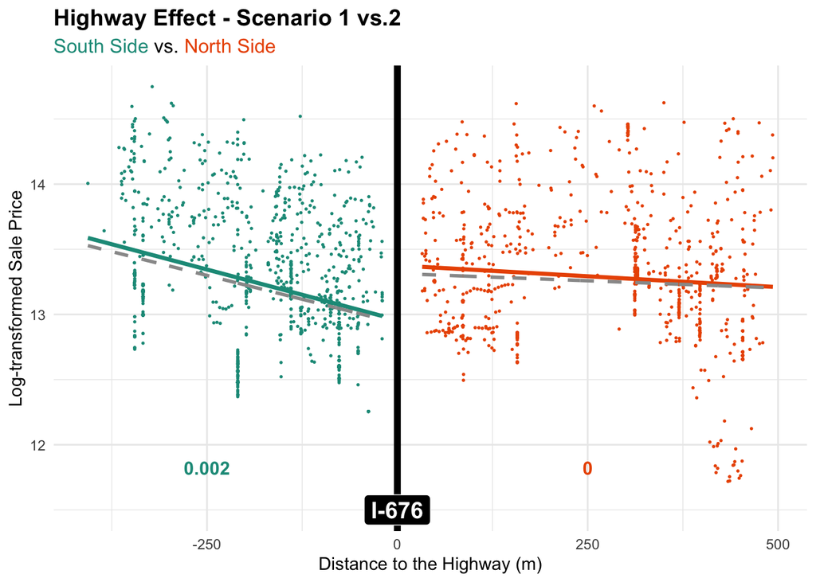

```r
property_S4 <- st_transform(property_S4_predict, 2272)

discontinuity_S4 <- property_S4 %>%
  filter(predicted_price > 100)

discontinuity_S4 <- rbind(
  discontinuity_S4 %>% st_intersection(studyarea_north["geometry"]) %>%
    mutate(I676_NS = "north"),
  discontinuity_S4 %>% st_intersection(studyarea_south["geometry"]) %>%
    mutate(I676_NS = "south")
)

discontinuity_S4 <- discontinuity_S4 %>%
  st_drop_geometry() %>%
  mutate(distance_to_I676m = distance_to_I676 * 0.3048,
         distance_to_highway = case_when(
           I676_NS == "north" ~ distance_to_I676m,
           I676_NS == "south" ~ -distance_to_I676m
         ))

discontinuity_S4 <- discontinuity_S4 %>%
  filter(abs(distance_to_highway) <= 500)

coef_north_S4 <- round(
  summary(
    lm(log(predicted_price+1) ~ distance_to_highway,
       data = discontinuity_S4,
       I676_NS == "north"))$coefficients[2,1], 3)

coef_south_S4 <- round(
  summary(
    lm(log(predicted_price+1) ~ abs(distance_to_highway),
       data = discontinuity_S4,
       I676_NS == "south"))$coefficients[2,1], 3)

lm_south_S1 <- lm(log(predicted_price + 1) ~ abs(distance_to_highway),
                  data = discontinuity_S1_predict %>% filter(I676_NS == "south"))

lm_north_S1 <- lm(log(predicted_price + 1) ~ distance_to_highway,
                  data = discontinuity_S1_predict %>% filter(I676_NS == "north"))

discontinuity_S1_predict <- discontinuity_S1_predict %>%
  mutate(
    fitted = case_when(
      I676_NS == "south" ~ predict(lm_south_S1, newdata = .),
      I676_NS == "north" ~ predict(lm_north_S1, newdata = .)
    )
  )

discontinuity_plot_S4_with_S1 <- ggplot() +

  geom_point(data = discontinuity_S4,
             aes(x = distance_to_highway, y = log(predicted_price + 1), color = I676_NS),
             size = 0.3) +

  geom_smooth(data = discontinuity_S4,
              aes(x = distance_to_highway, y = log(predicted_price + 1), color = I676_NS),
              method = "lm", se = FALSE, linewidth = 1.2) +

  geom_line(data = discontinuity_S1_predict %>% filter(I676_NS == "north"),
            aes(x = distance_to_highway, y = fitted),
            color = "grey60", linetype = "dashed", linewidth = 1) +

  geom_line(data = discontinuity_S1_predict %>% filter(I676_NS == "south"),
            aes(x = distance_to_highway, y = fitted),
            color = "grey60", linetype = "dashed", linewidth = 1) +

  geom_vline(xintercept = 0, color = "black", linewidth = 2) +

  scale_colour_manual(values = c("north" = "#eb5600", "south" = "#1a9988")) +

  labs(
    title = "Highway Effect - Scenario 1 vs.2",
    subtitle = glue("<span style='color:#1a9988;'>South Side</span> vs. <span style='color:#eb5600;'>North Side</span>"),
    x = "Distance to the Highway (m)",
    y = "Log-transformed Sale Price"
  ) +

  theme_minimal() +
  theme(
    plot.title = element_text(size = 14, face = "bold"),
    plot.subtitle = ggtext::element_markdown(size = 12),
    legend.position = "none"
  ) +

  geom_label(aes(x = 0, y = 11.5, label = "I-676"),
             fill = "black", color = "white", fontface = "bold", size = 5) +

  geom_text(aes(x = -250, y = 11.825, label = coef_south_S4),
            color = "#1a9988", size = 4, fontface = "bold") +

  geom_text(aes(x = 250, y = 11.825, label = coef_north_S4),
            color = "#eb5600", size = 4, fontface = "bold")

discontinuity_plot_S4_with_S1
```

```r
ggsave(
  filename = "~/Documents/Upenn/Practicum/2025/Chinatown-Practicum-my/finalresults/discontinuity_plot_S2_S1.png",
  plot = discontinuity_plot_S4_with_S1,
  height = 5,
  width = 8.5,
  units = "in",
  dpi = 300
)
```

5.5.2.0.0.0.0.1 here is the price changes 100m away from i676 for all scenarios, unorganized version for your exploration

```r
get_price_change_table <- function(data, price_col, scenario_label) {
  formula_all   <- as.formula(paste0("log(", price_col, " + 1) ~ distance_to_highway"))
  formula_south <- as.formula(paste0("log(", price_col, " + 1) ~ abs(distance_to_highway)"))
  formula_north <- as.formula(paste0("log(", price_col, " + 1) ~ distance_to_highway"))
  lm_all   <- lm(formula_all,   data = data)
  lm_south <- lm(formula_south, data = data %>% filter(I676_NS == "south"))
  lm_north <- lm(formula_north, data = data %>% filter(I676_NS == "north"))

  distances <- seq(50, 200, by = 50)
  pred_all   <- exp(predict(lm_all,   newdata = data.frame(distance_to_highway = distances))) - 1
  pred_south <- exp(predict(lm_south, newdata = data.frame(distance_to_highway = distances))) - 1
  pred_north <- exp(predict(lm_north, newdata = data.frame(distance_to_highway = distances))) - 1
  tibble(
    Scenario        = scenario_label,
    Distance_m      = distances,
    South_Price     = round(pred_south),
    North_Price     = round(pred_north),
    Overall_Price   = round(pred_all),
    South_Change    = round(pred_south - pred_south[1]),
    North_Change    = round(pred_north - pred_north[1]),
    Overall_Change  = round(pred_all - pred_all[1])
  )
}
S0_table <- get_price_change_table(discontinuity_S0, "adj_sale_price", "Scenario 0")
S0_table %>%
  kable("html", caption = "Distance-Based Price Summary (Scenario 0)") %>%
  kable_styling(full_width = FALSE)
```

Distance-Based Price Summary (Scenario 0)

| Scenario | Distance_m | South_Price | North_Price | Overall_Price | South_Change | North_Change | Overall_Change |
| --- | --- | --- | --- | --- | --- | --- | --- |
| Scenario 0 | 50 | 371508 | 498511 | 483245 | 0 | 0 | 0 |
| Scenario 0 | 100 | 416186 | 492633 | 475453 | 44679 | -5878 | -7791 |
| Scenario 0 | 150 | 466238 | 486824 | 467788 | 94731 | -11687 | -15457 |
| Scenario 0 | 200 | 522310 | 481084 | 460245 | 150802 | -17427 | -22999 |

```r
S1_table <- get_price_change_table(discontinuity_S1_predict, "predicted_price", "Scenario 1")
S1_table %>%
  kable("html", caption = "Distance-Based Price Summary (Scenario 1)") %>%
  kable_styling(full_width = FALSE)
```

Distance-Based Price Summary (Scenario 1)

| Scenario | Distance_m | South_Price | North_Price | Overall_Price | South_Change | North_Change | Overall_Change |
| --- | --- | --- | --- | --- | --- | --- | --- |
| Scenario 1 | 50 | 445538 | 599061 | 550632 | 0 | 0 | 0 |
| Scenario 1 | 100 | 479329 | 592440 | 548946 | 33790 | -6621 | -1686 |
| Scenario 1 | 150 | 515682 | 585892 | 547265 | 70144 | -13169 | -3367 |
| Scenario 1 | 200 | 554792 | 579416 | 545590 | 109254 | -19645 | -5042 |

```r
S4_table <- get_price_change_table(discontinuity_S4,          "predicted_price", "Scenario 2")
S4_table %>%
  kable("html", caption = "Distance-Based Price Summary (Scenario 2)") %>%
  kable_styling(full_width = FALSE)
```

Distance-Based Price Summary (Scenario 2)

| Scenario | Distance_m | South_Price | North_Price | Overall_Price | South_Change | North_Change | Overall_Change |
| --- | --- | --- | --- | --- | --- | --- | --- |
| Scenario 2 | 50 | 458085 | 633836 | 570238 | 0 | 0 | 0 |
| Scenario 2 | 100 | 495004 | 623372 | 567514 | 36919 | -10464 | -2724 |
| Scenario 2 | 150 | 534898 | 613081 | 564804 | 76813 | -20754 | -5434 |
| Scenario 2 | 200 | 578008 | 602960 | 562106 | 119923 | -30875 | -8132 |